# Honors Thesis

Dhanesha Mirpuri

May 2022

```r
library("tidyverse")
library("AER")
library("lmtest")
library("sandwich")
library("ggplot2")
library("stargazer")
```

```r
data = read.table("/Users/dhaneshamirpuri/Documents/maindata6.csv", header = TRUE, fill = TRUE, sep = ',')
```

cleaning the dataset: - changing everything necessary to numerics - replacing N/A’s with 0’s

```r
data$etrincometaxespretaxincome[is.na(data$etrincometaxespretaxincome)] = 0
data$etrincometaxespretaxincome[data$etrincometaxespretaxincome == "#DIV/0!"] = 0
data$etrincometaxespretaxincome[is.na(data$etrincometaxespretaxincome)] = 0
data$etrincometaxespretaxincome = as.numeric(data$etrincometaxespretaxincome)
data$spending_on_tax = as.numeric(data$spending_on_tax)
data$totalassets = as.numeric(data$totalassets)
data$numberofemployees = as.numeric(data$numberofemployees)
data$totaldebt = as.numeric(data$totaldebt)
data$totalinventory = as.numeric(data$totalinventory)
data$pretaxincome = as.numeric(data$pretaxincome)
data$incometaxes = as.numeric(data$incometaxes)
data$propertyplantandequitment = as.numeric(data$propertyplantandequitment)
data$rateofassets = as.numeric(data$rateofassets)
data$researchanddevelopmentexpenses = as.numeric(data$researchanddevelopmentexpenses)
data$leverageratiooftotaldebttototala = as.numeric(data$leverageratiooftotaldebttototala)
data$capitalintensityratioofpropertyp = as.numeric(data$capitalintensityratioofpropertyp)
data$inventoryintensityratioofinvento = as.numeric(data$inventoryintensityratioofinvento)
data$totspending = as.numeric(data$totspending)
data
```

[output not shown]

[output cut: 990 more lines]

```r
NA
```

changing names of variables to make it easier

#why didnt this work - i have to repeat for every data set??

```r
etr = data$etrincometaxespretaxincome
taxlob = data$spending_on_tax
lob = data$totspending
assets = data$totalassets
emp = data$numberofemployees
debt = data$totaldebt
invt = data$totalassets
pretax = data$pretaxincome
inctax = data$incometaxes
ppe = data$propertyplantandequitment
roa = data$rateofassets
rd = data$researchanddevelopmentexpenses
levrat = data$leverageratiooftotaldebttototala
caprat = data$capitalintensityratioofpropertyp
invrat = data$inventoryintensityratioofinvento
```

after using histograms to check for outliers, dropping values that are less than -1 and greater than 1 for etr

```r
d = filter(data, etr <= 1 & etr >= -1)
d
```

[output not shown]

[output cut: 990 more lines]

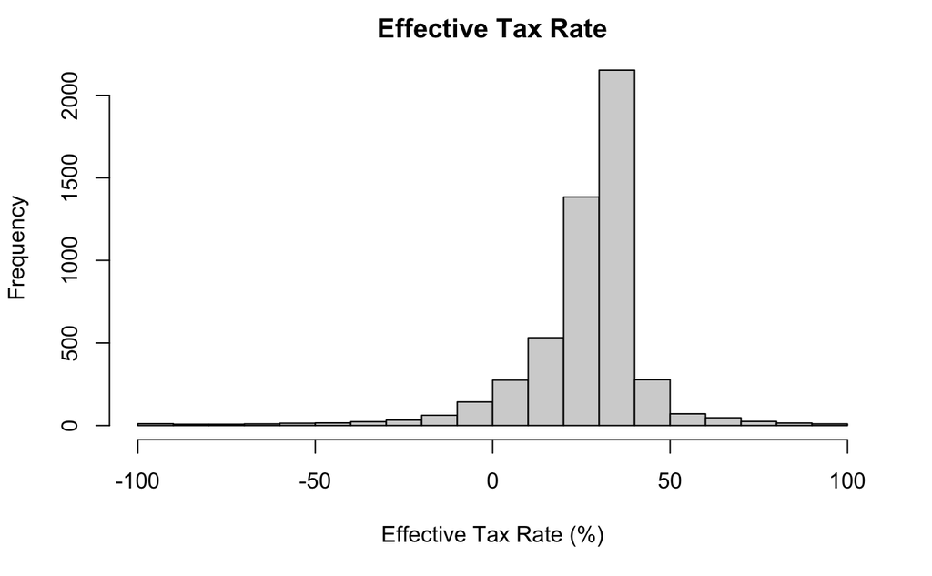

```r
etr2 = d$etr*100
etrhist = hist(etr2, main = "Effective Tax Rate", xlab = "Effective Tax Rate (%)", breaks = 20, na.rm = TRUE)
```

testing if its skewed distribution

```r
median(d$totspending, na.rm = TRUE)
```

```
[1] 501500
```

```r
mean(d$totspending, na.rm = TRUE)
```

```
[1] 2347904
```

```r
sqrt(var(d$totspending, na.rm = TRUE))
```

```
[1] 9271470
```

Histograms to see distributions

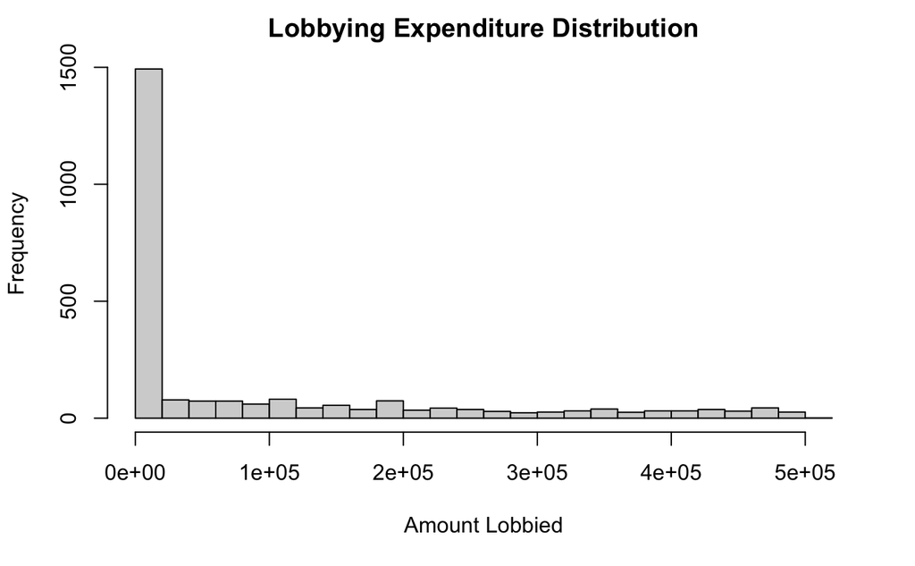

```r
dT1 = filter(data2, totspending <= 501500)
dT2 = filter(data2, totspending > 501500)
totlobbying1 = hist(dT1$totspending, main = "Lobbying Expenditure Distribution", xlab = "Amount Lobbied", breaks = 20, na.rm = TRUE)
```

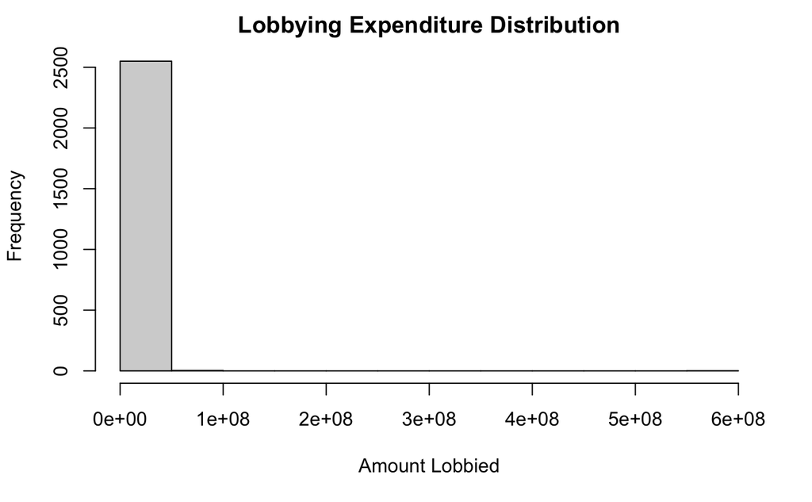

```r
totlobbying2 = hist(dT2$totspending, main = "Lobbying Expenditure Distribution", xlab = "Amount Lobbied", breaks = 20, na.rm = TRUE)
```

```r
dT1 = filter(data2, totspending >=1 & totspending <= 100000)
dT2 = filter(data2, totspending >= 10001 & totspending <= 30000)
dT3 = filter(data2, totspending >= 30001 & totspending <= 50000)
dT4 = filter(data2, totspending >= 50001 & totspending <= 70000)
dT5 = filter(data2, totspending >= 70001 & totspending <= 1000000)
dT6 = filter(data2, totspending >= 1000001 & totspending <= 25000000)
dT7 = filter(data2, totspending >= 25000001 & totspending <= 300000000)
dT8 = filter(data2, totspending >= 300000000)
dT_no_1 = filter(data2, totspending >=1 & totspending <= 2500000)

d_with_zero = filter(data2, totspending <2500000)
d_without_zero = filter(data2, totspending >=1 & totspending <= 2500000)
```

Histograms

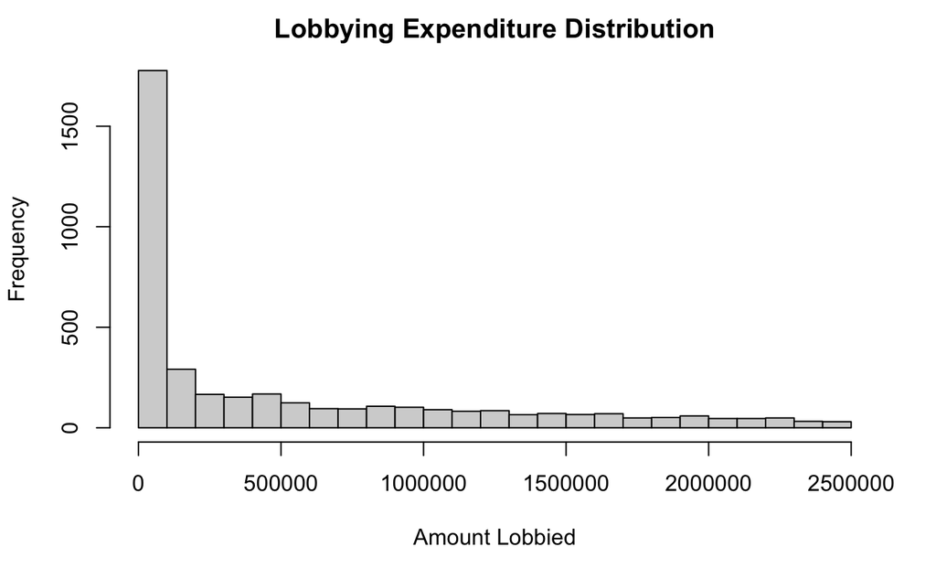

```r
totlobbying = hist(d_with_zero$totspending, main = "Lobbying Expenditure Distribution", xlab = "Amount Lobbied", frequency = TRUE, breaks = 20, na.rm = TRUE)
```

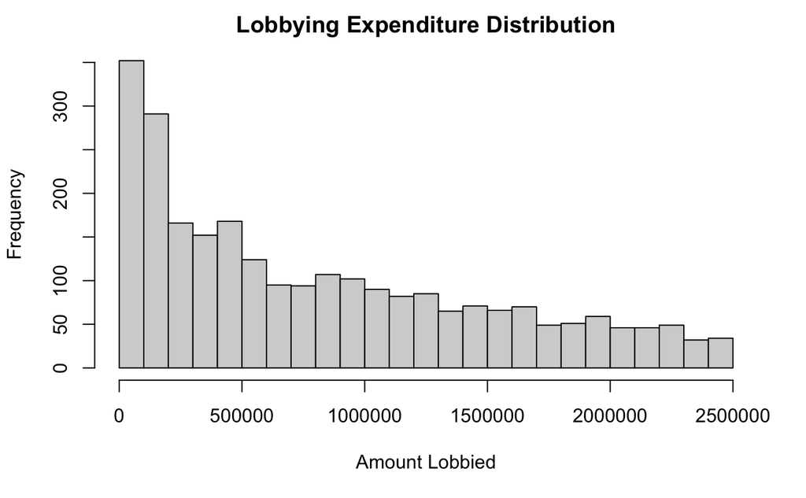

```r
totlobbying2 = hist(d_without_zero$totspending, main = "Lobbying Expenditure Distribution", xlab = "Amount Lobbied", frequency = TRUE, breaks = 20, na.rm = TRUE)
```

```r
d_with_zero$year = as.numeric(d_with_zero$year)
d_without_zero$year = as.numeric(d_without_zero$year)
view(d_with_zero)
view(d)
```

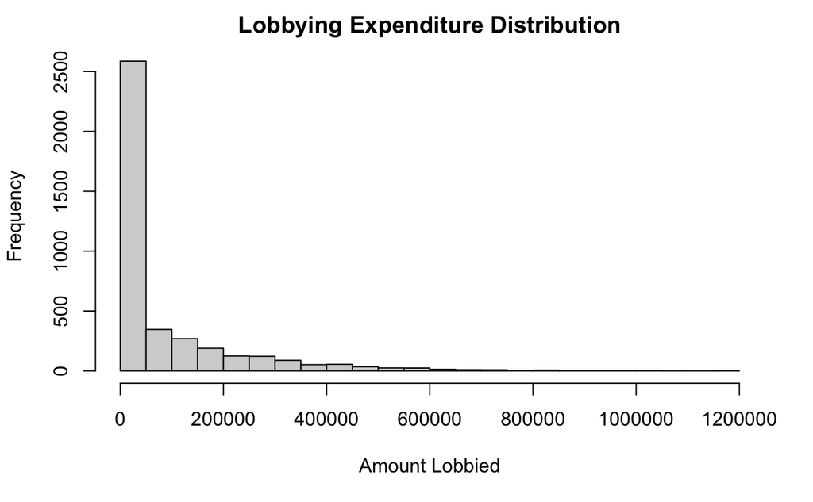

```r
taxlobbying = hist(d_with_zero$spending_on_tax, main = "Lobbying Expenditure Distribution", xlab = "Amount Lobbied", frequency = TRUE, breaks = 20, na.rm = TRUE)
```

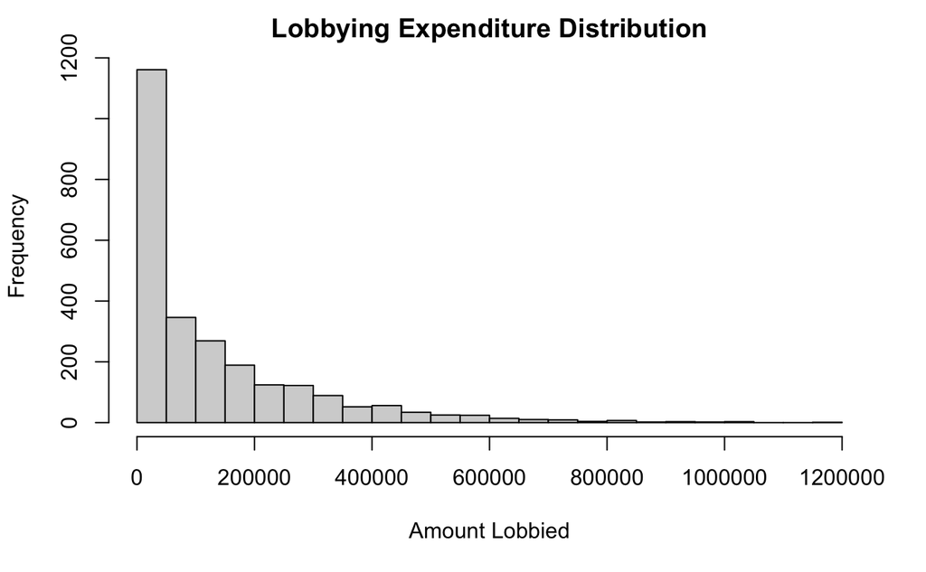

```r
taxlobbying2 = hist(d_without_zero$spending_on_tax, main = "Lobbying Expenditure Distribution", xlab = "Amount Lobbied", frequency = TRUE, breaks = 20, na.rm = TRUE)
```

Filtering data by years (entire dataset)

```r
d2000 = filter(d_with_zero, year == 2000)
d2001 = filter(d_with_zero, year == 2001)
d2002 = filter(d_with_zero, year == 2002)
d2003 = filter(d_with_zero, year == 2003)
d2004 = filter(d_with_zero, year == 2004)
d2005 = filter(d_with_zero, year == 2005)
d2006 = filter(d_with_zero, year == 2006)
d2007 = filter(d_with_zero, year == 2007)
d2008 = filter(d_with_zero, year == 2008)
d2009 = filter(d_with_zero, year == 2009)
d2010 = filter(d_with_zero, year == 2010)
d2011 = filter(d_with_zero, year == 2011)
d2012 = filter(d_with_zero, year == 2012)
d2013 = filter(d_with_zero, year == 2013)
d2014 = filter(d_with_zero, year == 2014)
d2015 = filter(d_with_zero, year == 2015)
d2016 = filter(d_with_zero, year == 2016)
d2017 = filter(d_with_zero, year == 2017)
d2018 = filter(d_with_zero, year == 2018)
d2019 = filter(d_with_zero, year == 2019)

avglist = list(
  mean(d2000$totspending, na.rm= TRUE),
  mean(d2001$totspending, na.rm= TRUE),
  mean(d2002$totspending, na.rm= TRUE),
  mean(d2003$totspending, na.rm= TRUE),
  mean(d2004$totspending, na.rm= TRUE),
  mean(d2005$totspending, na.rm= TRUE),
  mean(d2006$totspending, na.rm= TRUE),
  mean(d2007$totspending, na.rm= TRUE),
  mean(d2008$totspending, na.rm= TRUE),
  mean(d2008$totspending, na.rm= TRUE),
  mean(d2010$totspending, na.rm= TRUE),
  mean(d2011$totspending, na.rm= TRUE),
  mean(d2012$totspending, na.rm= TRUE),
  mean(d2013$totspending, na.rm= TRUE),
  mean(d2014$totspending, na.rm= TRUE),
  mean(d2015$totspending, na.rm= TRUE),
  mean(d2016$totspending, na.rm= TRUE),
  mean(d2017$totspending, na.rm= TRUE),
  mean(d2018$totspending, na.rm= TRUE),
  mean(d2019$totspending, na.rm= TRUE))

avglist = as.numeric(avglist)
avglist
```

```
 [1] 370478.1 369154.5 393274.1 451576.0 475414.9 501718.9 498648.7 557017.7 521722.5 521722.5 594606.5 559692.3 622849.1 592259.3 582703.8 568602.1
[17] 546937.6 560540.8 563954.8 811714.0
```

Descriptive statistics

```r
stargazer(d, type = "text", title="Descriptive statistics", digits=1, out="table1.txt")
```

```
Descriptive statistics
=======================================================================================
Statistic                          N      Mean      St. Dev.      Min          Max
---------------------------------------------------------------------------------------
totalassets                      5,112  58,621.0    181,647.7     20.6     2,622,532.0
totaldebt                        4,596  11,315.5    43,028.0      0.0       722,513.0
numberofemployees                5,082    117.1      3,285.4      0.0       220,000.0
totalinventory                   5,015   3,854.7    23,886.1      0.0       393,925.0
pretaxincome                     5,116   2,499.3     6,132.5   -108,761.0   78,726.0
propertyplantandequitment        4,991   8,265.1    19,495.5      0.0       252,668.0
incometaxes                      5,115    728.0      1,967.8   -21,515.0    31,051.0
researchanddevelopmentexpenses   2,950    853.2      1,918.1      0.0       28,837.0
etrincometaxespretaxincome       5,116     0.3         0.2        -1.0         1.0
leverageratiooftotaldebttototala 5,112     0.1         0.1        0.0          0.8
capitalintensityratioofpropertyp 4,882     0.2         0.2        0.0          0.9
inventoryintensityratioofinvento 5,102     0.1         0.1        0.0          0.8
totspending                      5,109 2,347,904.0 9,271,470.0    0.0     580,135,101.0
spending_on_tax                  5,113  290,765.5   652,311.4     0.0     10,800,000.0
rateofassets                     5,112     6.4        313.3       -3.0      21,257.6
---------------------------------------------------------------------------------------
```

```r
stargazer(d_with_zero, type = "text", title="Descriptive statistics", digits=1, out="table1.txt")
```

```
Descriptive statistics
================================================================================
Statistic                          N     Mean    St. Dev.     Min        Max
--------------------------------------------------------------------------------
year                             3,958  2,009.3     5.5      2,000      2,019
totalassets                      3,966 27,770.0  57,661.6    20.6     847,585.0
totaldebt                        3,513  4,232.0   7,932.6     0.0     131,198.0
numberofemployees                3,942   40.1      73.7       0.0      1,500.0
totalinventory                   3,886  1,354.1   4,922.1     0.0     173,388.0
pretaxincome                     3,967  1,254.6   2,306.6  -28,226.0  34,946.0
propertyplantandequitment        3,875  4,778.5   9,977.0     0.0     166,706.0
incometaxes                      3,967   368.3     772.8   -21,515.0  10,532.0
researchanddevelopmentexpenses   2,283   341.2     884.6      0.0     28,837.0
etrincometaxespretaxincome       3,967    0.3       0.2      -1.0        1.0
leverageratiooftotaldebttototala 3,966    0.1       0.1       0.0        0.8
capitalintensityratioofpropertyp 3,792    0.2       0.2       0.0        0.9
inventoryintensityratioofinvento 3,957    0.1       0.1       0.0        0.8
totspending                      3,967 524,649.7 676,368.4    0.0    2,490,000.0
spending_on_tax                  3,967 79,601.1  144,566.8    0.0    1,186,842.0
rateofassets                     3,966    0.1       0.1      -3.0        1.0
--------------------------------------------------------------------------------
```

```r
stargazer(d_without_zero, type = "text", title="Descriptive statistics", digits=1, out="table1.txt")
```

```
Descriptive statistics
================================================================================
Statistic                          N     Mean    St. Dev.     Min        Max
--------------------------------------------------------------------------------
year                             2,546  2,009.3     5.4      2,000      2,019
totalassets                      2,546 31,115.7  58,854.3    202.6    847,585.0
totaldebt                        2,220  4,201.2   6,453.1     0.0     131,198.0
numberofemployees                2,539   40.9      80.9       0.0      1,500.0
totalinventory                   2,488  1,474.6   5,922.3     0.0     173,388.0
pretaxincome                     2,546  1,262.2   1,981.3  -28,226.0  18,540.0
propertyplantandequitment        2,514  5,050.4   7,747.5     0.0     58,530.0
incometaxes                      2,546   388.3     598.0   -5,469.0    5,118.0
researchanddevelopmentexpenses   1,397   356.2     589.2      0.0      5,755.0
etrincometaxespretaxincome       2,546    0.3       0.2      -1.0        1.0
leverageratiooftotaldebttototala 2,546    0.1       0.1       0.0        0.7
capitalintensityratioofpropertyp 2,447    0.3       0.2       0.0        0.9
inventoryintensityratioofinvento 2,541    0.1       0.1       0.0        0.7
totspending                      2,546 821,400.4 690,521.3 10,000.0  2,500,000.0
spending_on_tax                  2,546 124,880.1 165,444.6    0.0    1,186,842.0
rateofassets                     2,546    0.1       0.1      -3.0        1.0
--------------------------------------------------------------------------------
```

```r
head(d)
```

|  | gvkey | ticker | year | firmname | sector | industry | v6 | cusip | totalassets | totaldebt | numberofemployees | totalinventory | pretaxincome | propertyplantandequitment | incometaxes | researchanddevelopmentexpenses | etrincometaxespretaxincome | leverageratiooftotaldebttototala | capitalintensityratioofpropertyp | inventoryintensityratioofinvento | firm | bvdid | primary_naics | totspending | numissue | numtax | taxratio | spending_on_tax | anylob | … |
| --- | --- | --- | --- | --- | --- | --- | --- | --- | --- | --- | --- | --- | --- | --- | --- | --- | --- | --- | --- | --- | --- | --- | --- | --- | --- | --- | --- | --- | --- | --- |
| 1 | 1045 | AAL | 2016 | American Airlines Group Inc | Transports | Airlines & Air Services | AAL | 02376R102 | 51274.000 | 24344 | 122.3 | 1094.000 | 4299.000 | 31159.000 | 1623.000 | 0 | 0.3775297 | 0.02133635 | 0.6076959 | 0.02133635 | AMERICAN AIRLINES | US131502798 | 481111 | 11100000 | 127 | 0 | 0.0944882 | 1045039.0 | 1 | … |
| 2 | 1045 | AAL | 2017 | American Airlines Group Inc | Transports | Airlines & Air Services | AAL | 02376R102 | 51396.000 | 25065 | 126.6 | 1359.000 | 3084.000 | 34156.000 | 1165.000 | NA | 0.3777562 | 0.02644175 | 0.6645653 | 0.02644175 | AMERICAN AIRLINES | US131502798 | 481111 | 10700000 | 138 | 0 | 0.1666667 | 1790333.0 | 1 | … |
| 3 | 1045 | AAL | 2018 | American Airlines Group Inc | Transports | Airlines & Air Services | AAL | 02376R102 | 60580.000 | 34029 | 128.9 | 1522.000 | 1884.000 | 43249.000 | 472.000 | NA | 0.2505308 | 0.02512380 | 0.7139155 | 0.02512380 | AMERICAN AIRLINES | US131502798 | 481111 | 8929000 | 95 | 0 | 0.1368421 | 1221863.0 | 1 | … |
| 4 | 1045 | AAL | 2019 | American Airlines Group Inc | Transports | Airlines & Air Services | AAL | 02376R102 | 59995.000 | 33444 | 133.7 | 1851.000 | 2256.000 | 43732.000 | 570.000 | NA | 0.2526596 | 0.03085257 | NA | 0.03085257 | AMERICAN AIRLINES | US131502798 | 481111 | 8682000 | 97 | 0 | 0.0515464 | 447525.8 | 1 | … |
| 5 | 1075 | PNW | 2000 | Pinnacle West Capital Corp | Utilities and Telecommunications | Utilities - Electric | PNW | 723484101 | 7149.151 | 0 | 7.2 | 91.371 | 526.184 | 5133.193 | 223.852 | 0 | 0.4254253 | 0.01278068 | 0.7180143 | 0.01278068 | PINNACLE WEST CAPITAL CORPORATION | US860512431 | 2211 | 1000000 | 21 | 0 | 0.1428571 | 142857.2 | 1 | … |
| 6 | 1075 | PNW | 2001 | Pinnacle West Capital Corp | Utilities and Telecommunications | Utilities - Electric | PNW | 723484101 | 7981.748 | NA | 7.6 | 108.238 | 540.902 | 5907.315 | 213.535 | NA | 0.3947758 | 0.01356069 | 0.7401029 | 0.01356069 | PINNACLE WEST CAPITAL CORPORATION | US860512431 | 2211 | 740000 | 20 | 0 | 0.1 | 74000.0 | 1 | … |

Running individual regressions on etr and each variable to get some idea of correlation/relationship (Kind of tells me which variables I need to log transform from the original dataset)

```r
etrreg1 = lm(etrincometaxespretaxincome ~ totspending, d)
summary(etrreg1)
```

```
Call:
lm(formula = etrincometaxespretaxincome ~ totspending, data = d)

Residuals:
     Min       1Q   Median       3Q      Max
-1.25469 -0.05078  0.03642  0.09382  0.72632

Coefficients:
              Estimate Std. Error t value Pr(>|t|)
(Intercept)  2.674e-01  2.659e-03 100.565   <2e-16 ***
totspending -6.105e-10  2.780e-10  -2.196   0.0281 *
---
Signif. codes:  0 ‘***’ 0.001 ‘**’ 0.01 ‘*’ 0.05 ‘.’ 0.1 ‘ ’ 1

Residual standard error: 0.1842 on 5107 degrees of freedom
  (7 observations deleted due to missingness)
Multiple R-squared:  0.0009435, Adjusted R-squared:  0.0007479
F-statistic: 4.823 on 1 and 5107 DF,  p-value: 0.02813
```

```r
etrreg2 = lm(etrincometaxespretaxincome ~ spending_on_tax, d)
summary(etrreg2)
```

```
Call:
lm(formula = etrincometaxespretaxincome ~ spending_on_tax, data = d)

Residuals:
     Min       1Q   Median       3Q      Max
-1.25608 -0.05037  0.03572  0.09404  0.72697

Coefficients:
                  Estimate Std. Error t value Pr(>|t|)
(Intercept)      2.687e-01  2.820e-03  95.296   <2e-16 ***
spending_on_tax -9.711e-09  3.949e-09  -2.459    0.014 *
---
Signif. codes:  0 ‘***’ 0.001 ‘**’ 0.01 ‘*’ 0.05 ‘.’ 0.1 ‘ ’ 1

Residual standard error: 0.1842 on 5111 degrees of freedom
  (3 observations deleted due to missingness)
Multiple R-squared:  0.001182,  Adjusted R-squared:  0.0009864
F-statistic: 6.047 on 1 and 5111 DF,  p-value: 0.01396
```

```r
etrreg3 = lm(etrincometaxespretaxincome ~ totalassets, d)
summary(etrreg3)
```

```
Call:
lm(formula = etrincometaxespretaxincome ~ totalassets, data = d)

Residuals:
     Min       1Q   Median       3Q      Max
-1.25115 -0.05067  0.03670  0.09387  0.72737

Coefficients:
              Estimate Std. Error t value Pr(>|t|)
(Intercept)  2.679e-01  2.707e-03  98.960   <2e-16 ***
totalassets -3.401e-08  1.418e-08  -2.398   0.0165 *
---
Signif. codes:  0 ‘***’ 0.001 ‘**’ 0.01 ‘*’ 0.05 ‘.’ 0.1 ‘ ’ 1

Residual standard error: 0.1842 on 5110 degrees of freedom
  (4 observations deleted due to missingness)
Multiple R-squared:  0.001124,  Adjusted R-squared:  0.0009282
F-statistic: 5.748 on 1 and 5110 DF,  p-value: 0.01654
```

```r
etrreg4 = lm(etrincometaxespretaxincome ~ numberofemployees, d)
summary(etrreg4)
```

```
Call:
lm(formula = etrincometaxespretaxincome ~ numberofemployees,
    data = d)

Residuals:
     Min       1Q   Median       3Q      Max
-1.25350 -0.05059  0.03581  0.09384  0.72543

Coefficients:
                    Estimate Std. Error t value Pr(>|t|)
(Intercept)        2.662e-01  2.580e-03 103.165   <2e-16 ***
numberofemployees -5.098e-07  7.849e-07  -0.649    0.516
---
Signif. codes:  0 ‘***’ 0.001 ‘**’ 0.01 ‘*’ 0.05 ‘.’ 0.1 ‘ ’ 1

Residual standard error: 0.1838 on 5080 degrees of freedom
  (34 observations deleted due to missingness)
Multiple R-squared:  8.303e-05, Adjusted R-squared:  -0.0001138
F-statistic: 0.4218 on 1 and 5080 DF,  p-value: 0.516
```

```r
etrreg5 = lm(etrincometaxespretaxincome ~ rateofassets, d)
summary(etrreg5)
```

```
Call:
lm(formula = etrincometaxespretaxincome ~ rateofassets, data = d)

Residuals:
     Min       1Q   Median       3Q      Max
-1.25331 -0.05110  0.03615  0.09406  0.72559

Coefficients:
               Estimate Std. Error t value Pr(>|t|)
(Intercept)   2.660e-01  2.578e-03 103.179   <2e-16 ***
rateofassets -1.103e-05  8.227e-06  -1.341     0.18
---
Signif. codes:  0 ‘***’ 0.001 ‘**’ 0.01 ‘*’ 0.05 ‘.’ 0.1 ‘ ’ 1

Residual standard error: 0.1843 on 5110 degrees of freedom
  (4 observations deleted due to missingness)
Multiple R-squared:  0.0003518, Adjusted R-squared:  0.0001561
F-statistic: 1.798 on 1 and 5110 DF,  p-value: 0.18
```

```r
etrreg6 = lm(etrincometaxespretaxincome ~ researchanddevelopmentexpenses, d)
summary(etrreg6)
```

```
Call:
lm(formula = etrincometaxespretaxincome ~ researchanddevelopmentexpenses,
    data = d)

Residuals:
     Min       1Q   Median       3Q      Max
-1.23585 -0.05134  0.03539  0.09956  0.77843

Coefficients:
                                 Estimate Std. Error t value
(Intercept)                     2.490e-01  3.998e-03  62.296
researchanddevelopmentexpenses -5.670e-06  1.904e-06  -2.977
                               Pr(>|t|)
(Intercept)                     < 2e-16 ***
researchanddevelopmentexpenses  0.00293 **
---
Signif. codes:  0 ‘***’ 0.001 ‘**’ 0.01 ‘*’ 0.05 ‘.’ 0.1 ‘ ’ 1

Residual standard error: 0.1984 on 2948 degrees of freedom
  (2166 observations deleted due to missingness)
Multiple R-squared:  0.002998,  Adjusted R-squared:  0.00266
F-statistic: 8.865 on 1 and 2948 DF,  p-value: 0.002931
```

```r
etrreg7 = lm(etrincometaxespretaxincome ~ leverageratiooftotaldebttototala, d)
summary(etrreg7)
```

```
Call:
lm(formula = etrincometaxespretaxincome ~ leverageratiooftotaldebttototala,
    data = d)

Residuals:
     Min       1Q   Median       3Q      Max
-1.30777 -0.04992  0.03525  0.08858  0.73461

Coefficients:
                                 Estimate Std. Error t value
(Intercept)                       0.25467    0.00324  78.614
leverageratiooftotaldebttototala  0.13463    0.02365   5.692
                                 Pr(>|t|)
(Intercept)                       < 2e-16 ***
leverageratiooftotaldebttototala 1.33e-08 ***
---
Signif. codes:  0 ‘***’ 0.001 ‘**’ 0.01 ‘*’ 0.05 ‘.’ 0.1 ‘ ’ 1

Residual standard error: 0.1837 on 5110 degrees of freedom
  (4 observations deleted due to missingness)
Multiple R-squared:  0.0063,    Adjusted R-squared:  0.006105
F-statistic: 32.39 on 1 and 5110 DF,  p-value: 1.328e-08
```

```r
etrreg8 = lm(etrincometaxespretaxincome ~ capitalintensityratioofpropertyp, d)
summary(etrreg8)
```

```
Call:
lm(formula = etrincometaxespretaxincome ~ capitalintensityratioofpropertyp,
    data = d)

Residuals:
     Min       1Q   Median       3Q      Max
-1.24754 -0.04491  0.03735  0.08687  0.73308

Coefficients:
                                 Estimate Std. Error t value
(Intercept)                      0.256989   0.003777  68.037
capitalintensityratioofpropertyp 0.054176   0.011059   4.899
                                 Pr(>|t|)
(Intercept)                       < 2e-16 ***
capitalintensityratioofpropertyp 9.96e-07 ***
---
Signif. codes:  0 ‘***’ 0.001 ‘**’ 0.01 ‘*’ 0.05 ‘.’ 0.1 ‘ ’ 1

Residual standard error: 0.1827 on 4880 degrees of freedom
  (234 observations deleted due to missingness)
Multiple R-squared:  0.004893,  Adjusted R-squared:  0.00469
F-statistic:    24 on 1 and 4880 DF,  p-value: 9.958e-07
```

```r
etrreg9 = lm(etrincometaxespretaxincome ~ inventoryintensityratioofinvento, d)
summary(etrreg9)
```

```
Call:
lm(formula = etrincometaxespretaxincome ~ inventoryintensityratioofinvento,
    data = d)

Residuals:
     Min       1Q   Median       3Q      Max
-1.30886 -0.05001  0.03501  0.08831  0.73448

Coefficients:
                                 Estimate Std. Error t value
(Intercept)                      0.254774   0.003232  78.824
inventoryintensityratioofinvento 0.136195   0.023676   5.752
                                 Pr(>|t|)
(Intercept)                       < 2e-16 ***
inventoryintensityratioofinvento 9.31e-09 ***
---
Signif. codes:  0 ‘***’ 0.001 ‘**’ 0.01 ‘*’ 0.05 ‘.’ 0.1 ‘ ’ 1

Residual standard error: 0.1831 on 5100 degrees of freedom
  (14 observations deleted due to missingness)
Multiple R-squared:  0.006447,  Adjusted R-squared:  0.006252
F-statistic: 33.09 on 1 and 5100 DF,  p-value: 9.308e-09
```

```r
etrreg10 = lm(etrincometaxespretaxincome ~log1p(totspending),d )
etrreg10
```

```
Call:
lm(formula = etrincometaxespretaxincome ~ log1p(totspending),
    data = d)

Coefficients:
       (Intercept)  log1p(totspending)
         0.2685412          -0.0002619
```

Normal Regressions with total lobbying (both log and not logged) with both datasets Deciding to log the positive data/lobbying variables

log1p()

```r
tot1 = lm(etrincometaxespretaxincome ~ totspending, d_with_zero)
summary(tot1)
```

```
Call:
lm(formula = etrincometaxespretaxincome ~ totspending, data = d_with_zero)

Residuals:
     Min       1Q   Median       3Q      Max
-1.25903 -0.04601  0.04018  0.09519  0.72207

Coefficients:
              Estimate Std. Error t value Pr(>|t|)
(Intercept)  2.717e-01  3.711e-03  73.211   <2e-16 ***
totspending -9.283e-09  4.336e-09  -2.141   0.0323 *
---
Signif. codes:  0 ‘***’ 0.001 ‘**’ 0.01 ‘*’ 0.05 ‘.’ 0.1 ‘ ’ 1

Residual standard error: 0.1847 on 3965 degrees of freedom
Multiple R-squared:  0.001155,  Adjusted R-squared:  0.0009029
F-statistic: 4.584 on 1 and 3965 DF,  p-value: 0.03233
```

```r
coeftest(tot1,df=Inf,vcov=vcovHC(tot1,type = "HC1"))
```

```
z test of coefficients:

               Estimate  Std. Error z value Pr(>|z|)
(Intercept)  2.7169e-01  3.6288e-03 74.8711  < 2e-16 ***
totspending -9.2829e-09  4.4664e-09 -2.0784  0.03767 *
---
Signif. codes:  0 ‘***’ 0.001 ‘**’ 0.01 ‘*’ 0.05 ‘.’ 0.1 ‘ ’ 1
```

```r
tot2 = lm(etr ~ lob, d_without_zero)
summary(tot2)
```

```
Call:
lm(formula = etr ~ lob, data = d_without_zero)

Residuals:
   Min     1Q Median     3Q    Max
  -152    -99    -98    -93 481012

Coefficients:
              Estimate Std. Error t value Pr(>|t|)
(Intercept)  9.928e+01  9.446e+01   1.051    0.293
lob         -2.580e-06  1.000e-05  -0.258    0.796

Residual standard error: 6637 on 5254 degrees of freedom
  (356 observations deleted due to missingness)
Multiple R-squared:  1.267e-05, Adjusted R-squared:  -0.0001777
F-statistic: 0.06659 on 1 and 5254 DF,  p-value: 0.7964
```

```r
coeftest(tot2,df=Inf,vcov=vcovHC(tot2,type = "HC1"))
```

```
z test of coefficients:

               Estimate  Std. Error z value Pr(>|z|)
(Intercept)  9.9285e+01  9.7541e+01  1.0179   0.3087
lob         -2.5804e-06  3.1328e-06 -0.8237   0.4101
```

```r
tot3 = lm(etr ~ log1p(lob), d)
summary(tot3)
```

```
Call:
lm(formula = etr ~ log1p(lob), data = d)

Residuals:
   Min     1Q Median     3Q    Max
  -362   -320    -22     11 480792

Coefficients:
            Estimate Std. Error t value Pr(>|t|)
(Intercept)   320.59     170.23   1.883   0.0597 .
log1p(lob)    -22.73      14.35  -1.584   0.1133
---
Signif. codes:  0 ‘***’ 0.001 ‘**’ 0.01 ‘*’ 0.05 ‘.’ 0.1 ‘ ’ 1

Residual standard error: 6636 on 5254 degrees of freedom
  (356 observations deleted due to missingness)
Multiple R-squared:  0.0004771, Adjusted R-squared:  0.0002869
F-statistic: 2.508 on 1 and 5254 DF,  p-value: 0.1133
```

```r
coeftest(tot3,df=Inf,vcov=vcovHC(tot3,type = "HC1"))
```

```
z test of coefficients:

            Estimate Std. Error z value Pr(>|z|)
(Intercept)  320.588    315.216  1.0170   0.3091
log1p(lob)   -22.728     22.366 -1.0162   0.3095
```

```r
tot4 = lm(etrincometaxespretaxincome ~ totspending + totalassets , d_with_zero)
summary(tot4)
```

```
Call:
lm(formula = etrincometaxespretaxincome ~ totspending + totalassets,
    data = d_with_zero)

Residuals:
     Min       1Q   Median       3Q      Max
-1.24834 -0.04457  0.04078  0.09434  0.72028

Coefficients:
              Estimate Std. Error t value Pr(>|t|)
(Intercept)  2.736e-01  3.836e-03  71.335   <2e-16 ***
totspending -7.451e-09  4.427e-09  -1.683   0.0924 .
totalassets -1.051e-07  5.193e-08  -2.023   0.0431 *
---
Signif. codes:  0 ‘***’ 0.001 ‘**’ 0.01 ‘*’ 0.05 ‘.’ 0.1 ‘ ’ 1

Residual standard error: 0.1846 on 3963 degrees of freedom
  (1 observation deleted due to missingness)
Multiple R-squared:  0.002181,  Adjusted R-squared:  0.001677
F-statistic: 4.331 on 2 and 3963 DF,  p-value: 0.01322
```

```r
coeftest(tot4,df=Inf,vcov=vcovHC(tot4,type = "HC1"))
```

```
z test of coefficients:

               Estimate  Std. Error z value Pr(>|z|)
(Intercept)  2.7363e-01  3.7540e-03 72.8898   <2e-16 ***
totspending -7.4511e-09  4.7736e-09 -1.5609   0.1185
totalassets -1.0506e-07  7.3962e-08 -1.4204   0.1555
---
Signif. codes:  0 ‘***’ 0.001 ‘**’ 0.01 ‘*’ 0.05 ‘.’ 0.1 ‘ ’ 1
```

```r
tot5 = lm(etrincometaxespretaxincome ~ totspending + totalassets , d_without_zero)
summary(tot5)
```

```
Call:
lm(formula = etrincometaxespretaxincome ~ totspending + totalassets,
    data = d_without_zero)

Residuals:
     Min       1Q   Median       3Q      Max
-1.24274 -0.04865  0.03633  0.09135  0.71744

Coefficients:
              Estimate Std. Error t value Pr(>|t|)
(Intercept)  2.781e-01  5.790e-03  48.036   <2e-16 ***
totspending -1.366e-08  5.482e-09  -2.492   0.0128 *
totalassets  2.499e-09  6.432e-08   0.039   0.9690
---
Signif. codes:  0 ‘***’ 0.001 ‘**’ 0.01 ‘*’ 0.05 ‘.’ 0.1 ‘ ’ 1

Residual standard error: 0.1855 on 2543 degrees of freedom
Multiple R-squared:  0.002563,  Adjusted R-squared:  0.001778
F-statistic: 3.267 on 2 and 2543 DF,  p-value: 0.03829
```

```r
coeftest(tot5,df=Inf,vcov=vcovHC(tot5,type = "HC1"))
```

```
z test of coefficients:

               Estimate  Std. Error z value Pr(>|z|)
(Intercept)  2.7814e-01  5.5315e-03 50.2835  < 2e-16 ***
totspending -1.3662e-08  5.5337e-09 -2.4688  0.01356 *
totalassets  2.4991e-09  5.4059e-08  0.0462  0.96313
---
Signif. codes:  0 ‘***’ 0.001 ‘**’ 0.01 ‘*’ 0.05 ‘.’ 0.1 ‘ ’ 1
```

```r
tot6 = lm(etrincometaxespretaxincome ~ log1p(totspending) + log1p(totalassets), d)
summary(tot6)
```

```
Call:
lm(formula = etrincometaxespretaxincome ~ log1p(totspending) +
    log1p(totalassets), data = d)

Residuals:
     Min       1Q   Median       3Q      Max
-1.24874 -0.04964  0.03612  0.09267  0.73285

Coefficients:
                     Estimate Std. Error t value Pr(>|t|)
(Intercept)         0.3058556  0.0183107  16.704   <2e-16 ***
log1p(totspending)  0.0001129  0.0004408   0.256   0.7979
log1p(totalassets) -0.0042113  0.0019920  -2.114   0.0346 *
---
Signif. codes:  0 ‘***’ 0.001 ‘**’ 0.01 ‘*’ 0.05 ‘.’ 0.1 ‘ ’ 1

Residual standard error: 0.1842 on 5105 degrees of freedom
  (8 observations deleted due to missingness)
Multiple R-squared:  0.0009549, Adjusted R-squared:  0.0005635
F-statistic:  2.44 on 2 and 5105 DF,  p-value: 0.08728
```

```r
coeftest(tot6,df=Inf,vcov=vcovHC(tot6,type = "HC1"))
```

```
z test of coefficients:

                      Estimate  Std. Error z value Pr(>|z|)
(Intercept)         0.30585565  0.01927418 15.8687  < 2e-16 ***
log1p(totspending)  0.00011290  0.00045884  0.2461  0.80564
log1p(totalassets) -0.00421134  0.00214933 -1.9594  0.05007 .
---
Signif. codes:  0 ‘***’ 0.001 ‘**’ 0.01 ‘*’ 0.05 ‘.’ 0.1 ‘ ’ 1
```

```r
tot7 = lm(etrincometaxespretaxincome ~ totspending + totalassets + numberofemployees , d_with_zero)
summary(tot7)
```

```
Call:
lm(formula = etrincometaxespretaxincome ~ totspending + totalassets +
    numberofemployees, data = d_with_zero)

Residuals:
     Min       1Q   Median       3Q      Max
-1.24541 -0.04349  0.04089  0.09047  0.71260

Coefficients:
                    Estimate Std. Error t value Pr(>|t|)
(Intercept)        2.691e-01  4.043e-03  66.556  < 2e-16 ***
totspending       -8.261e-09  4.408e-09  -1.874  0.06101 .
totalassets       -1.444e-07  5.240e-08  -2.756  0.00588 **
numberofemployees  1.631e-04  4.031e-05   4.047  5.3e-05 ***
---
Signif. codes:  0 ‘***’ 0.001 ‘**’ 0.01 ‘*’ 0.05 ‘.’ 0.1 ‘ ’ 1

Residual standard error: 0.1835 on 3937 degrees of freedom
  (26 observations deleted due to missingness)
Multiple R-squared:  0.006492,  Adjusted R-squared:  0.005735
F-statistic: 8.576 on 3 and 3937 DF,  p-value: 1.131e-05
```

```r
coeftest(tot7,df=Inf,vcov=vcovHC(tot7,type = "HC1"))
```

```
z test of coefficients:

                     Estimate  Std. Error z value  Pr(>|z|)
(Intercept)        2.6906e-01  4.0266e-03 66.8218 < 2.2e-16 ***
totspending       -8.2613e-09  4.7899e-09 -1.7247   0.08458 .
totalassets       -1.4440e-07  7.4408e-08 -1.9406   0.05231 .
numberofemployees  1.6314e-04  3.5143e-05  4.6421 3.449e-06 ***
---
Signif. codes:  0 ‘***’ 0.001 ‘**’ 0.01 ‘*’ 0.05 ‘.’ 0.1 ‘ ’ 1
```

```r
tot8 = lm(etrincometaxespretaxincome ~ totspending + totalassets + numberofemployees, d_without_zero)
summary(tot8)
```

```
Call:
lm(formula = etrincometaxespretaxincome ~ totspending + totalassets +
    numberofemployees, data = d_without_zero)

Residuals:
     Min       1Q   Median       3Q      Max
-1.23904 -0.04794  0.03667  0.08805  0.70746

Coefficients:
                    Estimate Std. Error t value Pr(>|t|)
(Intercept)        2.742e-01  5.962e-03  45.994  < 2e-16 ***
totspending       -1.507e-08  5.482e-09  -2.748  0.00603 **
totalassets       -1.231e-08  6.430e-08  -0.191  0.84818
numberofemployees  1.447e-04  4.557e-05   3.176  0.00151 **
---
Signif. codes:  0 ‘***’ 0.001 ‘**’ 0.01 ‘*’ 0.05 ‘.’ 0.1 ‘ ’ 1

Residual standard error: 0.1849 on 2535 degrees of freedom
  (7 observations deleted due to missingness)
Multiple R-squared:  0.00665,   Adjusted R-squared:  0.005475
F-statistic: 5.657 on 3 and 2535 DF,  p-value: 0.0007348
```

```r
coeftest(tot8,df=Inf,vcov=vcovHC(tot8,type = "HC1"))
```

```
z test of coefficients:

                     Estimate  Std. Error z value  Pr(>|z|)
(Intercept)        2.7424e-01  5.6545e-03 48.4994 < 2.2e-16 ***
totspending       -1.5067e-08  5.5392e-09 -2.7201  0.006526 **
totalassets       -1.2311e-08  5.4045e-08 -0.2278  0.819810
numberofemployees  1.4474e-04  3.6134e-05  4.0055 6.188e-05 ***
---
Signif. codes:  0 ‘***’ 0.001 ‘**’ 0.01 ‘*’ 0.05 ‘.’ 0.1 ‘ ’ 1
```

```r
tot9 = lm(etrincometaxespretaxincome ~  log1p(totspending) +  log1p(totalassets) +  log1p(numberofemployees), d)
summary(tot9)
```

```
Call:
lm(formula = etrincometaxespretaxincome ~ log1p(totspending) +
    log1p(totalassets) + log1p(numberofemployees), data = d)

Residuals:
     Min       1Q   Median       3Q      Max
-1.24068 -0.04897  0.03558  0.08693  0.72865

Coefficients:
                           Estimate Std. Error t value Pr(>|t|)
(Intercept)               3.180e-01  1.844e-02  17.250  < 2e-16 ***
log1p(totspending)       -4.084e-05  4.401e-04  -0.093    0.926
log1p(totalassets)       -1.012e-02  2.169e-03  -4.664 3.19e-06 ***
log1p(numberofemployees)  1.454e-02  2.291e-03   6.347 2.39e-10 ***
---
Signif. codes:  0 ‘***’ 0.001 ‘**’ 0.01 ‘*’ 0.05 ‘.’ 0.1 ‘ ’ 1

Residual standard error: 0.1831 on 5070 degrees of freedom
  (42 observations deleted due to missingness)
Multiple R-squared:  0.009082,  Adjusted R-squared:  0.008496
F-statistic: 15.49 on 3 and 5070 DF,  p-value: 4.986e-10
```

```r
coeftest(tot9,df=Inf,vcov=vcovHC(tot9,type = "HC1"))
```

```
z test of coefficients:

                            Estimate  Std. Error z value  Pr(>|z|)
(Intercept)               3.1803e-01  1.9271e-02 16.5032 < 2.2e-16
log1p(totspending)       -4.0839e-05  4.5667e-04 -0.0894    0.9287
log1p(totalassets)       -1.0116e-02  2.2681e-03 -4.4600 8.196e-06
log1p(numberofemployees)  1.4541e-02  2.3186e-03  6.2713 3.581e-10

(Intercept)              ***
log1p(totspending)
log1p(totalassets)       ***
log1p(numberofemployees) ***
---
Signif. codes:  0 ‘***’ 0.001 ‘**’ 0.01 ‘*’ 0.05 ‘.’ 0.1 ‘ ’ 1
```

```r
tot10 = lm(etrincometaxespretaxincome ~ totspending + totalassets + numberofemployees + rateofassets , d_with_zero)
summary(tot10)
```

```
Call:
lm(formula = etrincometaxespretaxincome ~ totspending + totalassets +
    numberofemployees + rateofassets, data = d_with_zero)

Residuals:
     Min       1Q   Median       3Q      Max
-1.24217 -0.05086  0.03284  0.08438  0.77205

Coefficients:
                    Estimate Std. Error t value Pr(>|t|)
(Intercept)        2.426e-01  4.505e-03  53.859  < 2e-16 ***
totspending       -5.742e-09  4.330e-09  -1.326  0.18491
totalassets       -4.311e-08  5.206e-08  -0.828  0.40770
numberofemployees  1.052e-04  3.983e-05   2.641  0.00831 **
rateofassets       2.889e-01  2.333e-02  12.385  < 2e-16 ***
---
Signif. codes:  0 ‘***’ 0.001 ‘**’ 0.01 ‘*’ 0.05 ‘.’ 0.1 ‘ ’ 1

Residual standard error: 0.1801 on 3936 degrees of freedom
  (26 observations deleted due to missingness)
Multiple R-squared:  0.04376,   Adjusted R-squared:  0.04279
F-statistic: 45.03 on 4 and 3936 DF,  p-value: < 2.2e-16
```

```r
coeftest(tot10,df=Inf,vcov=vcovHC(tot10,type = "HC1"))
```

```
z test of coefficients:

                     Estimate  Std. Error z value  Pr(>|z|)
(Intercept)        2.4262e-01  6.6644e-03 36.4058 < 2.2e-16 ***
totspending       -5.7421e-09  4.7353e-09 -1.2126  0.225275
totalassets       -4.3107e-08  7.8831e-08 -0.5468  0.584498
numberofemployees  1.0518e-04  3.2952e-05  3.1920  0.001413 **
rateofassets       2.8890e-01  4.7773e-02  6.0474 1.472e-09 ***
---
Signif. codes:  0 ‘***’ 0.001 ‘**’ 0.01 ‘*’ 0.05 ‘.’ 0.1 ‘ ’ 1
```

```r
tot11 = lm(etrincometaxespretaxincome ~ totspending + totalassets + numberofemployees + rateofassets, d_without_zero)
summary(tot11)
```

```
Call:
lm(formula = etrincometaxespretaxincome ~ totspending + totalassets +
    numberofemployees + rateofassets, data = d_without_zero)

Residuals:
     Min       1Q   Median       3Q      Max
-1.19750 -0.05181  0.02702  0.08432  0.73742

Coefficients:
                    Estimate Std. Error t value Pr(>|t|)
(Intercept)        2.525e-01  6.355e-03  39.723  < 2e-16 ***
totspending       -1.489e-08  5.398e-09  -2.757  0.00587 **
totalassets        7.704e-08  6.410e-08   1.202  0.22954
numberofemployees  1.005e-04  4.514e-05   2.226  0.02609 *
rateofassets       2.666e-01  2.977e-02   8.955  < 2e-16 ***
---
Signif. codes:  0 ‘***’ 0.001 ‘**’ 0.01 ‘*’ 0.05 ‘.’ 0.1 ‘ ’ 1

Residual standard error: 0.1821 on 2534 degrees of freedom
  (7 observations deleted due to missingness)
Multiple R-squared:  0.03712,   Adjusted R-squared:  0.0356
F-statistic: 24.43 on 4 and 2534 DF,  p-value: < 2.2e-16
```

```r
coeftest(tot11,df=Inf,vcov=vcovHC(tot11,type = "HC1"))
```

```
z test of coefficients:

                     Estimate  Std. Error z value  Pr(>|z|)
(Intercept)        2.5245e-01  8.6641e-03 29.1380 < 2.2e-16 ***
totspending       -1.4886e-08  5.4501e-09 -2.7313  0.006309 **
totalassets        7.7035e-08  6.1753e-08  1.2475  0.212222
numberofemployees  1.0050e-04  3.4537e-05  2.9099  0.003615 **
rateofassets       2.6660e-01  6.6116e-02  4.0323 5.524e-05 ***
---
Signif. codes:  0 ‘***’ 0.001 ‘**’ 0.01 ‘*’ 0.05 ‘.’ 0.1 ‘ ’ 1
```

```r
tot12 = lm(etrincometaxespretaxincome ~ log1p(totspending) + log1p(totalassets) + log1p(numberofemployees) + log1p(rateofassets), d)
summary(tot12)
```

```
Call:
lm(formula = etrincometaxespretaxincome ~ log1p(totspending) +
    log1p(totalassets) + log1p(numberofemployees) + log1p(rateofassets),
    data = d)

Residuals:
     Min       1Q   Median       3Q      Max
-1.24105 -0.04999  0.03433  0.08581  0.72480

Coefficients:
                           Estimate Std. Error t value Pr(>|t|)
(Intercept)               0.3011173  0.0186411  16.153  < 2e-16 ***
log1p(totspending)       -0.0001084  0.0004386  -0.247 0.804809
log1p(totalassets)       -0.0083599  0.0021850  -3.826 0.000132 ***
log1p(numberofemployees)  0.0126042  0.0023019   5.476 4.57e-08 ***
log1p(rateofassets)       0.0863428  0.0132516   6.516 7.94e-11 ***
---
Signif. codes:  0 ‘***’ 0.001 ‘**’ 0.01 ‘*’ 0.05 ‘.’ 0.1 ‘ ’ 1

Residual standard error: 0.1823 on 5065 degrees of freedom
  (46 observations deleted due to missingness)
Multiple R-squared:  0.01739,   Adjusted R-squared:  0.01661
F-statistic: 22.41 on 4 and 5065 DF,  p-value: < 2.2e-16
```

```r
coeftest(tot12,df=Inf,vcov=vcovHC(tot12,type = "HC1"))
```

```
z test of coefficients:

                            Estimate  Std. Error z value  Pr(>|z|)
(Intercept)               0.30111728  0.02331666 12.9143 < 2.2e-16
log1p(totspending)       -0.00010839  0.00045445 -0.2385  0.811486
log1p(totalassets)       -0.00835992  0.00259063 -3.2270  0.001251
log1p(numberofemployees)  0.01260415  0.00256996  4.9044  9.37e-07
log1p(rateofassets)       0.08634278  0.05948947  1.4514  0.146670

(Intercept)              ***
log1p(totspending)
log1p(totalassets)       **
log1p(numberofemployees) ***
log1p(rateofassets)
---
Signif. codes:  0 ‘***’ 0.001 ‘**’ 0.01 ‘*’ 0.05 ‘.’ 0.1 ‘ ’ 1
```

```r
tot13 = lm(etrincometaxespretaxincome ~ totspending + totalassets + numberofemployees + rateofassets + researchanddevelopmentexpenses, d_with_zero)
summary(tot13)
```

```
Call:
lm(formula = etrincometaxespretaxincome ~ totspending + totalassets +
    numberofemployees + rateofassets + researchanddevelopmentexpenses,
    data = d_with_zero)

Residuals:
     Min       1Q   Median       3Q      Max
-1.15762 -0.05546  0.02584  0.08615  0.77537

Coefficients:
                                 Estimate Std. Error t value
(Intercept)                     2.033e-01  6.490e-03  31.326
totspending                    -4.170e-09  6.130e-09  -0.680
totalassets                    -5.142e-07  1.169e-07  -4.398
numberofemployees               2.284e-04  4.691e-05   4.869
rateofassets                    4.642e-01  3.537e-02  13.123
researchanddevelopmentexpenses -1.585e-05  4.573e-06  -3.466
                               Pr(>|t|)
(Intercept)                     < 2e-16 ***
totspending                    0.496332
totalassets                    1.14e-05 ***
numberofemployees              1.20e-06 ***
rateofassets                    < 2e-16 ***
researchanddevelopmentexpenses 0.000537 ***
---
Signif. codes:  0 ‘***’ 0.001 ‘**’ 0.01 ‘*’ 0.05 ‘.’ 0.1 ‘ ’ 1

Residual standard error: 0.1882 on 2266 degrees of freedom
  (1695 observations deleted due to missingness)
Multiple R-squared:  0.09969,   Adjusted R-squared:  0.0977
F-statistic: 50.18 on 5 and 2266 DF,  p-value: < 2.2e-16
```

```r
coeftest(tot13,df=Inf,vcov=vcovHC(tot13,type = "HC1"))
```

```
z test of coefficients:

                                  Estimate  Std. Error z value
(Intercept)                     2.0331e-01  7.9129e-03 25.6940
totspending                    -4.1705e-09  7.0203e-09 -0.5941
totalassets                    -5.1417e-07  2.6629e-07 -1.9308
numberofemployees               2.2841e-04  4.7122e-05  4.8471
rateofassets                    4.6421e-01  4.1636e-02 11.1494
researchanddevelopmentexpenses -1.5850e-05  5.8425e-06 -2.7130
                                Pr(>|z|)
(Intercept)                    < 2.2e-16 ***
totspending                     0.552469
totalassets                     0.053502 .
numberofemployees              1.253e-06 ***
rateofassets                   < 2.2e-16 ***
researchanddevelopmentexpenses  0.006668 **
---
Signif. codes:  0 ‘***’ 0.001 ‘**’ 0.01 ‘*’ 0.05 ‘.’ 0.1 ‘ ’ 1
```

```r
tot14 = lm(etrincometaxespretaxincome ~ totspending + totalassets + numberofemployees + rateofassets + researchanddevelopmentexpenses, d_without_zero)
summary(tot14)
```

```
Call:
lm(formula = etrincometaxespretaxincome ~ totspending + totalassets +
    numberofemployees + rateofassets + researchanddevelopmentexpenses,
    data = d_without_zero)

Residuals:
     Min       1Q   Median       3Q      Max
-1.13494 -0.05639  0.02566  0.08555  0.77827

Coefficients:
                                 Estimate Std. Error t value
(Intercept)                     2.135e-01  9.667e-03  22.087
totspending                    -1.686e-08  8.379e-09  -2.012
totalassets                     3.221e-08  1.908e-07   0.169
numberofemployees               1.430e-04  5.220e-05   2.740
rateofassets                    4.695e-01  4.883e-02   9.616
researchanddevelopmentexpenses -2.003e-05  9.320e-06  -2.149
                               Pr(>|t|)
(Intercept)                     < 2e-16 ***
totspending                     0.04444 *
totalassets                     0.86593
numberofemployees               0.00622 **
rateofassets                    < 2e-16 ***
researchanddevelopmentexpenses  0.03183 *
---
Signif. codes:  0 ‘***’ 0.001 ‘**’ 0.01 ‘*’ 0.05 ‘.’ 0.1 ‘ ’ 1

Residual standard error: 0.1939 on 1388 degrees of freedom
  (1152 observations deleted due to missingness)
Multiple R-squared:  0.08031,   Adjusted R-squared:  0.077
F-statistic: 24.24 on 5 and 1388 DF,  p-value: < 2.2e-16
```

```r
coeftest(tot14,df=Inf,vcov=vcovHC(tot14,type = "HC1"))
```

```
z test of coefficients:

                                  Estimate  Std. Error z value
(Intercept)                     2.1351e-01  1.0697e-02 19.9605
totspending                    -1.6856e-08  8.8107e-09 -1.9131
totalassets                     3.2214e-08  2.9145e-07  0.1105
numberofemployees               1.4305e-04  4.3854e-05  3.2618
rateofassets                    4.6951e-01  6.0553e-02  7.7537
researchanddevelopmentexpenses -2.0027e-05  9.2429e-06 -2.1668
                                Pr(>|z|)
(Intercept)                    < 2.2e-16 ***
totspending                     0.055733 .
totalassets                     0.911991
numberofemployees               0.001107 **
rateofassets                   8.923e-15 ***
researchanddevelopmentexpenses  0.030254 *
---
Signif. codes:  0 ‘***’ 0.001 ‘**’ 0.01 ‘*’ 0.05 ‘.’ 0.1 ‘ ’ 1
```

```r
tot15 = lm(etrincometaxespretaxincome ~ log1p(totspending) + log1p(totalassets) + log1p(numberofemployees) + log1p(rateofassets) + log1p(researchanddevelopmentexpenses), d)
summary(tot15)
```

```
Call:
lm(formula = etrincometaxespretaxincome ~ log1p(totspending) +
    log1p(totalassets) + log1p(numberofemployees) + log1p(rateofassets) +
    log1p(researchanddevelopmentexpenses), data = d)

Residuals:
     Min       1Q   Median       3Q      Max
-1.20763 -0.04508  0.03021  0.07979  0.78713

Coefficients:
                                        Estimate Std. Error t value
(Intercept)                            0.3741184  0.0286100  13.077
log1p(totspending)                     0.0011585  0.0006336   1.829
log1p(totalassets)                    -0.0250570  0.0037556  -6.672
log1p(numberofemployees)               0.0341102  0.0035929   9.494
log1p(rateofassets)                    0.0805671  0.0154449   5.216
log1p(researchanddevelopmentexpenses) -0.0060574  0.0013193  -4.591
                                      Pr(>|t|)
(Intercept)                            < 2e-16 ***
log1p(totspending)                      0.0676 .
log1p(totalassets)                    3.01e-11 ***
log1p(numberofemployees)               < 2e-16 ***
log1p(rateofassets)                   1.95e-07 ***
log1p(researchanddevelopmentexpenses) 4.59e-06 ***
---
Signif. codes:  0 ‘***’ 0.001 ‘**’ 0.01 ‘*’ 0.05 ‘.’ 0.1 ‘ ’ 1

Residual standard error: 0.1931 on 2926 degrees of freedom
  (2184 observations deleted due to missingness)
Multiple R-squared:  0.05367,   Adjusted R-squared:  0.05205
F-statistic: 33.19 on 5 and 2926 DF,  p-value: < 2.2e-16
```

```r
coeftest(tot15,df=Inf,vcov=vcovHC(tot15,type = "HC1"))
```

```
z test of coefficients:

                                         Estimate  Std. Error
(Intercept)                            0.37411835  0.03541721
log1p(totspending)                     0.00115853  0.00067563
log1p(totalassets)                    -0.02505703  0.00488013
log1p(numberofemployees)               0.03411017  0.00412606
log1p(rateofassets)                    0.08056713  0.06983827
log1p(researchanddevelopmentexpenses) -0.00605738  0.00146030
                                      z value  Pr(>|z|)
(Intercept)                           10.5632 < 2.2e-16 ***
log1p(totspending)                     1.7147   0.08639 .
log1p(totalassets)                    -5.1345 2.829e-07 ***
log1p(numberofemployees)               8.2670 < 2.2e-16 ***
log1p(rateofassets)                    1.1536   0.24865
log1p(researchanddevelopmentexpenses) -4.1480 3.353e-05 ***
---
Signif. codes:  0 ‘***’ 0.001 ‘**’ 0.01 ‘*’ 0.05 ‘.’ 0.1 ‘ ’ 1
```

```r
tot16 = lm(etrincometaxespretaxincome ~ totspending + totalassets + numberofemployees + rateofassets + researchanddevelopmentexpenses + leverageratiooftotaldebttototala, d_with_zero)
summary(tot16)
```

```
Call:
lm(formula = etrincometaxespretaxincome ~ totspending + totalassets +
    numberofemployees + rateofassets + researchanddevelopmentexpenses +
    leverageratiooftotaldebttototala, data = d_with_zero)

Residuals:
     Min       1Q   Median       3Q      Max
-1.15285 -0.05458  0.02135  0.08124  0.78644

Coefficients:
                                   Estimate Std. Error t value Pr(>|t|)
(Intercept)                       1.790e-01  7.530e-03  23.768  < 2e-16 ***
totspending                      -8.818e-10  6.102e-09  -0.145 0.885106
totalassets                      -3.954e-07  1.175e-07  -3.365 0.000778 ***
numberofemployees                 1.388e-04  4.869e-05   2.851 0.004398 **
rateofassets                      4.196e-01  3.581e-02  11.717  < 2e-16 ***
researchanddevelopmentexpenses   -1.195e-05  4.578e-06  -2.609 0.009132 **
leverageratiooftotaldebttototala  2.497e-01  4.012e-02   6.225 5.71e-10 ***
---
Signif. codes:  0 ‘***’ 0.001 ‘**’ 0.01 ‘*’ 0.05 ‘.’ 0.1 ‘ ’ 1

Residual standard error: 0.1867 on 2265 degrees of freedom
  (1695 observations deleted due to missingness)
Multiple R-squared:  0.1148,    Adjusted R-squared:  0.1125
F-statistic: 48.97 on 6 and 2265 DF,  p-value: < 2.2e-16
```

```r
coeftest(tot16,df=Inf,vcov=vcovHC(tot16,type = "HC1"))
```

```
z test of coefficients:

                                    Estimate  Std. Error z value  Pr(>|z|)
(Intercept)                       1.7898e-01  8.8410e-03 20.2448 < 2.2e-16 ***
totspending                      -8.8185e-10  7.0038e-09 -0.1259 0.8998025
totalassets                      -3.9540e-07  2.7036e-07 -1.4625 0.1436128
numberofemployees                 1.3883e-04  4.1184e-05  3.3709 0.0007492 ***
rateofassets                      4.1958e-01  4.1819e-02 10.0332 < 2.2e-16 ***
researchanddevelopmentexpenses   -1.1946e-05  5.0201e-06 -2.3796 0.0173324 *
leverageratiooftotaldebttototala  2.4975e-01  3.4359e-02  7.2688 3.628e-13 ***
---
Signif. codes:  0 ‘***’ 0.001 ‘**’ 0.01 ‘*’ 0.05 ‘.’ 0.1 ‘ ’ 1
```

```r
tot17 = lm(etrincometaxespretaxincome ~ totspending + totalassets + numberofemployees + rateofassets + researchanddevelopmentexpenses + leverageratiooftotaldebttototala, d_without_zero)
summary(tot17)
```

```
Call:
lm(formula = etrincometaxespretaxincome ~ totspending + totalassets +
    numberofemployees + rateofassets + researchanddevelopmentexpenses +
    leverageratiooftotaldebttototala, data = d_without_zero)

Residuals:
     Min       1Q   Median       3Q      Max
-1.13096 -0.05520  0.02270  0.08272  0.78403

Coefficients:
                                   Estimate Std. Error t value Pr(>|t|)
(Intercept)                       1.974e-01  1.121e-02  17.613  < 2e-16 ***
totspending                      -1.812e-08  8.369e-09  -2.165  0.03059 *
totalassets                       1.210e-07  1.929e-07   0.627  0.53053
numberofemployees                 9.112e-05  5.522e-05   1.650  0.09912 .
rateofassets                      4.467e-01  4.937e-02   9.048  < 2e-16 ***
researchanddevelopmentexpenses   -1.528e-05  9.448e-06  -1.617  0.10614
leverageratiooftotaldebttototala  1.891e-01  6.687e-02   2.827  0.00477 **
---
Signif. codes:  0 ‘***’ 0.001 ‘**’ 0.01 ‘*’ 0.05 ‘.’ 0.1 ‘ ’ 1

Residual standard error: 0.1934 on 1387 degrees of freedom
  (1152 observations deleted due to missingness)
Multiple R-squared:  0.08558,   Adjusted R-squared:  0.08163
F-statistic: 21.64 on 6 and 1387 DF,  p-value: < 2.2e-16
```

```r
coeftest(tot17,df=Inf,vcov=vcovHC(tot17,type = "HC1"))
```

```
z test of coefficients:

                                    Estimate  Std. Error z value  Pr(>|z|)
(Intercept)                       1.9737e-01  1.2390e-02 15.9298 < 2.2e-16 ***
totspending                      -1.8116e-08  8.7575e-09 -2.0686  0.038583 *
totalassets                       1.2099e-07  2.8958e-07  0.4178  0.676073
numberofemployees                 9.1122e-05  4.0004e-05  2.2778  0.022738 *
rateofassets                      4.4668e-01  6.2622e-02  7.1330 9.818e-13 ***
researchanddevelopmentexpenses   -1.5275e-05  9.7559e-06 -1.5658  0.117403
leverageratiooftotaldebttototala  1.8905e-01  6.6043e-02  2.8625  0.004203 **
---
Signif. codes:  0 ‘***’ 0.001 ‘**’ 0.01 ‘*’ 0.05 ‘.’ 0.1 ‘ ’ 1
```

```r
tot18 = lm(etrincometaxespretaxincome ~ log1p(totspending) + log1p(totalassets) + log1p(numberofemployees) + log1p(rateofassets) + log1p(researchanddevelopmentexpenses) + log1p(leverageratiooftotaldebttototala), d)
summary(tot18)
```

```
Call:
lm(formula = etrincometaxespretaxincome ~ log1p(totspending) +
    log1p(totalassets) + log1p(numberofemployees) + log1p(rateofassets) +
    log1p(researchanddevelopmentexpenses) + log1p(leverageratiooftotaldebttototala),
    data = d)

Residuals:
     Min       1Q   Median       3Q      Max
-1.21844 -0.04205  0.02690  0.08085  0.78969

Coefficients:
                                          Estimate Std. Error t value Pr(>|t|)
(Intercept)                              0.3100234  0.0330065   9.393  < 2e-16 ***
log1p(totspending)                       0.0013394  0.0006338   2.113 0.034659 *
log1p(totalassets)                      -0.0179512  0.0041731  -4.302 1.75e-05 ***
log1p(numberofemployees)                 0.0259287  0.0041624   6.229 5.36e-10 ***
log1p(rateofassets)                      0.0737929  0.0155075   4.759 2.04e-06 ***
log1p(researchanddevelopmentexpenses)   -0.0050036  0.0013441  -3.723 0.000201 ***
log1p(leverageratiooftotaldebttototala)  0.1958107  0.0506418   3.867 0.000113 ***
---
Signif. codes:  0 ‘***’ 0.001 ‘**’ 0.01 ‘*’ 0.05 ‘.’ 0.1 ‘ ’ 1

Residual standard error: 0.1927 on 2925 degrees of freedom
  (2184 observations deleted due to missingness)
Multiple R-squared:  0.05848,   Adjusted R-squared:  0.05655
F-statistic: 30.28 on 6 and 2925 DF,  p-value: < 2.2e-16
```

```r
coeftest(tot18,df=Inf,vcov=vcovHC(tot18,type = "HC1"))
```

```
z test of coefficients:

                                           Estimate  Std. Error z value  Pr(>|z|)
(Intercept)                              0.31002338  0.03900103  7.9491 1.879e-15 ***
log1p(totspending)                       0.00133944  0.00067479  1.9850 0.0471463 *
log1p(totalassets)                      -0.01795120  0.00514942 -3.4861 0.0004902 ***
log1p(numberofemployees)                 0.02592867  0.00453457  5.7180 1.078e-08 ***
log1p(rateofassets)                      0.07379291  0.06981647  1.0570 0.2905318
log1p(researchanddevelopmentexpenses)   -0.00500365  0.00150582 -3.3229 0.0008910 ***
log1p(leverageratiooftotaldebttototala)  0.19581070  0.04384459  4.4660 7.969e-06 ***
---
Signif. codes:  0 ‘***’ 0.001 ‘**’ 0.01 ‘*’ 0.05 ‘.’ 0.1 ‘ ’ 1
```

```r
tot19 = lm(etrincometaxespretaxincome ~ totspending + totalassets + numberofemployees + rateofassets + researchanddevelopmentexpenses + leverageratiooftotaldebttototala + capitalintensityratioofpropertyp, d_with_zero)
summary(tot19)
```

```
Call:
lm(formula = etrincometaxespretaxincome ~ totspending + totalassets +
    numberofemployees + rateofassets + researchanddevelopmentexpenses +
    leverageratiooftotaldebttototala + capitalintensityratioofpropertyp,
    data = d_with_zero)

Residuals:
     Min       1Q   Median       3Q      Max
-1.15468 -0.04966  0.01931  0.07783  0.78002

Coefficients:
                                   Estimate Std. Error t value Pr(>|t|)
(Intercept)                       1.809e-01  8.692e-03  20.808  < 2e-16 ***
totspending                      -2.801e-09  6.128e-09  -0.457 0.647667
totalassets                      -3.871e-07  1.168e-07  -3.314 0.000933 ***
numberofemployees                 1.329e-04  5.019e-05   2.648 0.008164 **
rateofassets                      4.239e-01  3.560e-02  11.906  < 2e-16 ***
researchanddevelopmentexpenses   -1.110e-05  4.585e-06  -2.421 0.015571 *
leverageratiooftotaldebttototala  2.337e-01  4.042e-02   5.782 8.46e-09 ***
capitalintensityratioofpropertyp  2.189e-02  2.319e-02   0.944 0.345305
---
Signif. codes:  0 ‘***’ 0.001 ‘**’ 0.01 ‘*’ 0.05 ‘.’ 0.1 ‘ ’ 1

Residual standard error: 0.1834 on 2168 degrees of freedom
  (1791 observations deleted due to missingness)
Multiple R-squared:  0.1201,    Adjusted R-squared:  0.1173
F-statistic: 42.29 on 7 and 2168 DF,  p-value: < 2.2e-16
```

```r
coeftest(tot19,df=Inf,vcov=vcovHC(tot19,type = "HC1"))
```

```
z test of coefficients:

                                    Estimate  Std. Error z value  Pr(>|z|)
(Intercept)                       1.8087e-01  9.8754e-03 18.3154 < 2.2e-16 ***
totspending                      -2.8010e-09  7.2142e-09 -0.3883  0.697824
totalassets                      -3.8714e-07  2.7663e-07 -1.3995  0.161661
numberofemployees                 1.3288e-04  4.2095e-05  3.1567  0.001596 **
rateofassets                      4.2386e-01  4.2586e-02  9.9530 < 2.2e-16 ***
researchanddevelopmentexpenses   -1.1100e-05  4.6052e-06 -2.4102  0.015943 *
leverageratiooftotaldebttototala  2.3373e-01  3.6044e-02  6.4845 8.901e-11 ***
capitalintensityratioofpropertyp  2.1893e-02  2.9141e-02  0.7513  0.452476
---
Signif. codes:  0 ‘***’ 0.001 ‘**’ 0.01 ‘*’ 0.05 ‘.’ 0.1 ‘ ’ 1
```

```r
tot20 = lm(etrincometaxespretaxincome ~ totspending + totalassets + numberofemployees + rateofassets + researchanddevelopmentexpenses + leverageratiooftotaldebttototala + capitalintensityratioofpropertyp, d_without_zero)
summary(tot20)
```

```
Call:
lm(formula = etrincometaxespretaxincome ~ totspending + totalassets +
    numberofemployees + rateofassets + researchanddevelopmentexpenses +
    leverageratiooftotaldebttototala + capitalintensityratioofpropertyp,
    data = d_without_zero)

Residuals:
     Min       1Q   Median       3Q      Max
-1.13831 -0.05445  0.02283  0.08241  0.78433

Coefficients:
                                   Estimate Std. Error t value Pr(>|t|)
(Intercept)                       2.115e-01  1.303e-02  16.225  < 2e-16 ***
totspending                      -1.823e-08  8.357e-09  -2.181  0.02935 *
totalassets                       9.415e-08  1.917e-07   0.491  0.62335
numberofemployees                 1.315e-04  5.693e-05   2.310  0.02104 *
rateofassets                      4.545e-01  4.874e-02   9.326  < 2e-16 ***
researchanddevelopmentexpenses   -1.799e-05  9.662e-06  -1.862  0.06282 .
leverageratiooftotaldebttototala  1.866e-01  6.632e-02   2.813  0.00497 **
capitalintensityratioofpropertyp -5.102e-02  2.944e-02  -1.733  0.08332 .
---
Signif. codes:  0 ‘***’ 0.001 ‘**’ 0.01 ‘*’ 0.05 ‘.’ 0.1 ‘ ’ 1

Residual standard error: 0.1893 on 1340 degrees of freedom
  (1198 observations deleted due to missingness)
Multiple R-squared:  0.09492,   Adjusted R-squared:  0.09019
F-statistic: 20.08 on 7 and 1340 DF,  p-value: < 2.2e-16
```

```r
coeftest(tot20,df=Inf,vcov=vcovHC(tot20,type = "HC1"))
```

```
z test of coefficients:

                                    Estimate  Std. Error z value  Pr(>|z|)
(Intercept)                       2.1149e-01  1.3374e-02 15.8128 < 2.2e-16 ***
totspending                      -1.8227e-08  8.8407e-09 -2.0617  0.039238 *
totalassets                       9.4149e-08  2.9340e-07  0.3209  0.748295
numberofemployees                 1.3151e-04  4.4012e-05  2.9880  0.002808 **
rateofassets                      4.5450e-01  6.2642e-02  7.2555 4.001e-13 ***
researchanddevelopmentexpenses   -1.7991e-05  9.6417e-06 -1.8659  0.062054 .
leverageratiooftotaldebttototala  1.8658e-01  6.6755e-02  2.7950  0.005189 **
capitalintensityratioofpropertyp -5.1021e-02  3.4436e-02 -1.4816  0.138439
---
Signif. codes:  0 ‘***’ 0.001 ‘**’ 0.01 ‘*’ 0.05 ‘.’ 0.1 ‘ ’ 1
```

```r
tot21 = lm(etrincometaxespretaxincome ~ log1p(totspending) + log1p(totalassets) + log1p(numberofemployees) + log1p(rateofassets) + log1p(researchanddevelopmentexpenses) + log1p(leverageratiooftotaldebttototala) +log1p(capitalintensityratioofpropertyp), d)
summary(tot21)
```

```
Call:
lm(formula = etrincometaxespretaxincome ~ log1p(totspending) +
    log1p(totalassets) + log1p(numberofemployees) + log1p(rateofassets) +
    log1p(researchanddevelopmentexpenses) + log1p(leverageratiooftotaldebttototala) +
    log1p(capitalintensityratioofpropertyp), data = d)

Residuals:
     Min       1Q   Median       3Q      Max
-1.22333 -0.03851  0.02610  0.07838  0.78505

Coefficients:
                                         Estimate Std. Error t value Pr(>|t|)
(Intercept)                              0.306866   0.034333   8.938  < 2e-16 ***
log1p(totspending)                       0.001083   0.000651   1.663 0.096444 .
log1p(totalassets)                      -0.016684   0.004269  -3.908 9.52e-05 ***
log1p(numberofemployees)                 0.025367   0.004356   5.824 6.40e-09 ***
log1p(rateofassets)                      0.073054   0.015410   4.741 2.24e-06 ***
log1p(researchanddevelopmentexpenses)   -0.005056   0.001438  -3.516 0.000444 ***
log1p(leverageratiooftotaldebttototala)  0.194002   0.051176   3.791 0.000153 ***
log1p(capitalintensityratioofpropertyp) -0.001088   0.028638  -0.038 0.969708
---
Signif. codes:  0 ‘***’ 0.001 ‘**’ 0.01 ‘*’ 0.05 ‘.’ 0.1 ‘ ’ 1

Residual standard error: 0.1909 on 2797 degrees of freedom
  (2311 observations deleted due to missingness)
Multiple R-squared:  0.05761,   Adjusted R-squared:  0.05525
F-statistic: 24.43 on 7 and 2797 DF,  p-value: < 2.2e-16
```

```r
coeftest(tot21,df=Inf,vcov=vcovHC(tot21,type = "HC1"))
```

```
z test of coefficients:

                                          Estimate Std. Error z value  Pr(>|z|)
(Intercept)                              0.3068661  0.0411775  7.4523 9.174e-14 ***
log1p(totspending)                       0.0010826  0.0006863  1.5774  0.114696
log1p(totalassets)                      -0.0166841  0.0054068 -3.0858  0.002030 **
log1p(numberofemployees)                 0.0253672  0.0049754  5.0985 3.423e-07 ***
log1p(rateofassets)                      0.0730545  0.0696329  1.0491  0.294114
log1p(researchanddevelopmentexpenses)   -0.0050560  0.0015558 -3.2498  0.001155 **
log1p(leverageratiooftotaldebttototala)  0.1940018  0.0443204  4.3773 1.202e-05 ***
log1p(capitalintensityratioofpropertyp) -0.0010876  0.0349012 -0.0312  0.975139
---
Signif. codes:  0 ‘***’ 0.001 ‘**’ 0.01 ‘*’ 0.05 ‘.’ 0.1 ‘ ’ 1
```

```r
tot22 = lm(etrincometaxespretaxincome ~ totspending + totalassets + numberofemployees + rateofassets + researchanddevelopmentexpenses + leverageratiooftotaldebttototala + capitalintensityratioofpropertyp + inventoryintensityratioofinvento , d_with_zero)
summary(tot22)
```

```
Call:
lm(formula = etrincometaxespretaxincome ~ totspending + totalassets +
    numberofemployees + rateofassets + researchanddevelopmentexpenses +
    leverageratiooftotaldebttototala + capitalintensityratioofpropertyp +
    inventoryintensityratioofinvento, data = d_with_zero)

Residuals:
     Min       1Q   Median       3Q      Max
-1.15644 -0.04963  0.01936  0.07712  0.77886

Coefficients: (1 not defined because of singularities)
                                   Estimate Std. Error t value
(Intercept)                       1.824e-01  8.672e-03  21.037
totspending                      -2.595e-09  6.103e-09  -0.425
totalassets                      -3.966e-07  1.163e-07  -3.411
numberofemployees                 1.340e-04  5.006e-05   2.677
rateofassets                      4.149e-01  3.540e-02  11.720
researchanddevelopmentexpenses   -1.240e-05  4.827e-06  -2.569
leverageratiooftotaldebttototala  2.307e-01  4.019e-02   5.740
capitalintensityratioofpropertyp  2.414e-02  2.311e-02   1.045
inventoryintensityratioofinvento         NA         NA      NA
                                 Pr(>|t|)
(Intercept)                       < 2e-16 ***
totspending                       0.67074
totalassets                       0.00066 ***
numberofemployees                 0.00749 **
rateofassets                      < 2e-16 ***
researchanddevelopmentexpenses    0.01026 *
leverageratiooftotaldebttototala 1.08e-08 ***
capitalintensityratioofpropertyp  0.29630
inventoryintensityratioofinvento       NA
---
Signif. codes:  0 ‘***’ 0.001 ‘**’ 0.01 ‘*’ 0.05 ‘.’ 0.1 ‘ ’ 1

Residual standard error: 0.1822 on 2162 degrees of freedom
  (1797 observations deleted due to missingness)
Multiple R-squared:  0.1193,    Adjusted R-squared:  0.1165
F-statistic: 41.85 on 7 and 2162 DF,  p-value: < 2.2e-16
```

```r
coeftest(tot22,df=Inf,vcov=vcovHC(tot22,type = "HC1"))
```

```
z test of coefficients:

                                    Estimate  Std. Error z value
(Intercept)                       1.8244e-01  9.9306e-03 18.3711
totspending                      -2.5948e-09  7.2567e-09 -0.3576
totalassets                      -3.9664e-07  2.7665e-07 -1.4337
numberofemployees                 1.3399e-04  4.2571e-05  3.1474
rateofassets                      4.1494e-01  4.1436e-02 10.0142
researchanddevelopmentexpenses   -1.2402e-05  5.3183e-06 -2.3320
leverageratiooftotaldebttototala  2.3070e-01  3.6110e-02  6.3888
capitalintensityratioofpropertyp  2.4140e-02  2.9126e-02  0.8288
                                  Pr(>|z|)
(Intercept)                      < 2.2e-16 ***
totspending                       0.720666
totalassets                       0.151644
numberofemployees                 0.001648 **
rateofassets                     < 2.2e-16 ***
researchanddevelopmentexpenses    0.019699 *
leverageratiooftotaldebttototala 1.672e-10 ***
capitalintensityratioofpropertyp  0.407209
---
Signif. codes:  0 ‘***’ 0.001 ‘**’ 0.01 ‘*’ 0.05 ‘.’ 0.1 ‘ ’ 1
```

```r
tot23 = lm(etrincometaxespretaxincome ~ totspending + totalassets + numberofemployees + rateofassets + researchanddevelopmentexpenses + leverageratiooftotaldebttototala + capitalintensityratioofpropertyp + inventoryintensityratioofinvento, d_without_zero)
summary(tot23)
```

```
Call:
lm(formula = etrincometaxespretaxincome ~ totspending + totalassets +
    numberofemployees + rateofassets + researchanddevelopmentexpenses +
    leverageratiooftotaldebttototala + capitalintensityratioofpropertyp +
    inventoryintensityratioofinvento, data = d_without_zero)

Residuals:
     Min       1Q   Median       3Q      Max
-1.13949 -0.05599  0.02254  0.08226  0.78122

Coefficients: (1 not defined because of singularities)
                                   Estimate Std. Error t value
(Intercept)                       2.132e-01  1.291e-02  16.512
totspending                      -1.876e-08  8.275e-09  -2.268
totalassets                       8.886e-08  1.897e-07   0.468
numberofemployees                 1.292e-04  5.639e-05   2.291
rateofassets                      4.402e-01  4.830e-02   9.113
researchanddevelopmentexpenses   -1.752e-05  9.562e-06  -1.832
leverageratiooftotaldebttototala  1.844e-01  6.566e-02   2.808
capitalintensityratioofpropertyp -4.643e-02  2.916e-02  -1.592
inventoryintensityratioofinvento         NA         NA      NA
                                 Pr(>|t|)
(Intercept)                       < 2e-16 ***
totspending                       0.02350 *
totalassets                       0.63956
numberofemployees                 0.02214 *
rateofassets                      < 2e-16 ***
researchanddevelopmentexpenses    0.06716 .
leverageratiooftotaldebttototala  0.00506 **
capitalintensityratioofpropertyp  0.11155
inventoryintensityratioofinvento       NA
---
Signif. codes:  0 ‘***’ 0.001 ‘**’ 0.01 ‘*’ 0.05 ‘.’ 0.1 ‘ ’ 1

Residual standard error: 0.1873 on 1337 degrees of freedom
  (1201 observations deleted due to missingness)
Multiple R-squared:  0.09225,   Adjusted R-squared:  0.0875
F-statistic: 19.41 on 7 and 1337 DF,  p-value: < 2.2e-16
```

```r
coeftest(tot23,df=Inf,vcov=vcovHC(tot23,type = "HC1"))
```

```
z test of coefficients:

                                    Estimate  Std. Error z value
(Intercept)                       2.1317e-01  1.3254e-02 16.0835
totspending                      -1.8765e-08  8.8273e-09 -2.1257
totalassets                       8.8857e-08  2.9323e-07  0.3030
numberofemployees                 1.2916e-04  4.3703e-05  2.9554
rateofassets                      4.4021e-01  6.0506e-02  7.2754
researchanddevelopmentexpenses   -1.7519e-05  9.6560e-06 -1.8143
leverageratiooftotaldebttototala  1.8437e-01  6.6904e-02  2.7558
capitalintensityratioofpropertyp -4.6431e-02  3.4209e-02 -1.3573
                                  Pr(>|z|)
(Intercept)                      < 2.2e-16 ***
totspending                       0.033525 *
totalassets                       0.761868
numberofemployees                 0.003123 **
rateofassets                     3.453e-13 ***
researchanddevelopmentexpenses    0.069637 .
leverageratiooftotaldebttototala  0.005855 **
capitalintensityratioofpropertyp  0.174695
---
Signif. codes:  0 ‘***’ 0.001 ‘**’ 0.01 ‘*’ 0.05 ‘.’ 0.1 ‘ ’ 1
```

```r
tot24 = lm(etrincometaxespretaxincome ~ log1p(totspending) + log1p(totalassets) + log1p(numberofemployees) + log1p(rateofassets) + log1p(researchanddevelopmentexpenses) + log1p(leverageratiooftotaldebttototala) +log1p(capitalintensityratioofpropertyp) +log1p(inventoryintensityratioofinvento), d)
summary(tot24)
```

```
Call:
lm(formula = etrincometaxespretaxincome ~ log1p(totspending) +
    log1p(totalassets) + log1p(numberofemployees) + log1p(rateofassets) +
    log1p(researchanddevelopmentexpenses) + log1p(leverageratiooftotaldebttototala) +
    log1p(capitalintensityratioofpropertyp) + log1p(inventoryintensityratioofinvento),
    data = d)

Residuals:
     Min       1Q   Median       3Q      Max
-1.19313 -0.04062  0.02013  0.07505  1.06836

Coefficients: (1 not defined because of singularities)
                                          Estimate Std. Error
(Intercept)                              0.2845753  0.0337701
log1p(totspending)                       0.0012770  0.0006398
log1p(totalassets)                      -0.0147914  0.0041929
log1p(numberofemployees)                 0.0225608  0.0042816
log1p(rateofassets)                      0.2532813  0.0244984
log1p(researchanddevelopmentexpenses)   -0.0055785  0.0014131
log1p(leverageratiooftotaldebttototala)  0.1928203  0.0501384
log1p(capitalintensityratioofpropertyp) -0.0067086  0.0280992
log1p(inventoryintensityratioofinvento)         NA         NA
                                        t value Pr(>|t|)
(Intercept)                               8.427  < 2e-16 ***
log1p(totspending)                        1.996 0.046052 *
log1p(totalassets)                       -3.528 0.000426 ***
log1p(numberofemployees)                  5.269 1.47e-07 ***
log1p(rateofassets)                      10.339  < 2e-16 ***
log1p(researchanddevelopmentexpenses)    -3.948 8.08e-05 ***
log1p(leverageratiooftotaldebttototala)   3.846 0.000123 ***
log1p(capitalintensityratioofpropertyp)  -0.239 0.811319
log1p(inventoryintensityratioofinvento)      NA       NA
---
Signif. codes:  0 ‘***’ 0.001 ‘**’ 0.01 ‘*’ 0.05 ‘.’ 0.1 ‘ ’ 1

Residual standard error: 0.187 on 2790 degrees of freedom
  (2318 observations deleted due to missingness)
Multiple R-squared:  0.08588,   Adjusted R-squared:  0.08359
F-statistic: 37.45 on 7 and 2790 DF,  p-value: < 2.2e-16
```

```r
coeftest(tot24,df=Inf,vcov=vcovHC(tot24,type = "HC1"))
```

```
z test of coefficients:

                                           Estimate  Std. Error
(Intercept)                              0.28457534  0.04303775
log1p(totspending)                       0.00127696  0.00067752
log1p(totalassets)                      -0.01479141  0.00546481
log1p(numberofemployees)                 0.02256078  0.00493737
log1p(rateofassets)                      0.25328133  0.10407405
log1p(researchanddevelopmentexpenses)   -0.00557849  0.00155721
log1p(leverageratiooftotaldebttototala)  0.19282027  0.04464597
log1p(capitalintensityratioofpropertyp) -0.00670860  0.03427188
                                        z value  Pr(>|z|)
(Intercept)                              6.6122 3.786e-11 ***
log1p(totspending)                       1.8848 0.0594617 .
log1p(totalassets)                      -2.7067 0.0067963 **
log1p(numberofemployees)                 4.5694 4.891e-06 ***
log1p(rateofassets)                      2.4337 0.0149468 *
log1p(researchanddevelopmentexpenses)   -3.5824 0.0003405 ***
log1p(leverageratiooftotaldebttototala)  4.3189 1.568e-05 ***
log1p(capitalintensityratioofpropertyp) -0.1957 0.8448085
---
Signif. codes:  0 ‘***’ 0.001 ‘**’ 0.01 ‘*’ 0.05 ‘.’ 0.1 ‘ ’ 1
```

```r
tot25 = lm(etrincometaxespretaxincome ~ totspending + totalassets + numberofemployees + rateofassets + researchanddevelopmentexpenses + leverageratiooftotaldebttototala + capitalintensityratioofpropertyp + inventoryintensityratioofinvento , d_with_zero)
summary(tot25)
```

```
Call:
lm(formula = etrincometaxespretaxincome ~ totspending + totalassets +
    numberofemployees + rateofassets + researchanddevelopmentexpenses +
    leverageratiooftotaldebttototala + capitalintensityratioofpropertyp +
    inventoryintensityratioofinvento, data = d_with_zero)

Residuals:
     Min       1Q   Median       3Q      Max
-1.15644 -0.04963  0.01936  0.07712  0.77886

Coefficients: (1 not defined because of singularities)
                                   Estimate Std. Error t value Pr(>|t|)
(Intercept)                       1.824e-01  8.672e-03  21.037  < 2e-16 ***
totspending                      -2.595e-09  6.103e-09  -0.425  0.67074
totalassets                      -3.966e-07  1.163e-07  -3.411  0.00066 ***
numberofemployees                 1.340e-04  5.006e-05   2.677  0.00749 **
rateofassets                      4.149e-01  3.540e-02  11.720  < 2e-16 ***
researchanddevelopmentexpenses   -1.240e-05  4.827e-06  -2.569  0.01026 *
leverageratiooftotaldebttototala  2.307e-01  4.019e-02   5.740 1.08e-08 ***
capitalintensityratioofpropertyp  2.414e-02  2.311e-02   1.045  0.29630
inventoryintensityratioofinvento         NA         NA      NA       NA
---
Signif. codes:  0 ‘***’ 0.001 ‘**’ 0.01 ‘*’ 0.05 ‘.’ 0.1 ‘ ’ 1

Residual standard error: 0.1822 on 2162 degrees of freedom
  (1797 observations deleted due to missingness)
Multiple R-squared:  0.1193,    Adjusted R-squared:  0.1165
F-statistic: 41.85 on 7 and 2162 DF,  p-value: < 2.2e-16
```

```r
coeftest(tot25,df=Inf,vcov=vcovHC(tot25,type = "HC1"))
```

```
z test of coefficients:

                                    Estimate  Std. Error z value  Pr(>|z|)
(Intercept)                       1.8244e-01  9.9306e-03 18.3711 < 2.2e-16 ***
totspending                      -2.5948e-09  7.2567e-09 -0.3576  0.720666
totalassets                      -3.9664e-07  2.7665e-07 -1.4337  0.151644
numberofemployees                 1.3399e-04  4.2571e-05  3.1474  0.001648 **
rateofassets                      4.1494e-01  4.1436e-02 10.0142 < 2.2e-16 ***
researchanddevelopmentexpenses   -1.2402e-05  5.3183e-06 -2.3320  0.019699 *
leverageratiooftotaldebttototala  2.3070e-01  3.6110e-02  6.3888 1.672e-10 ***
capitalintensityratioofpropertyp  2.4140e-02  2.9126e-02  0.8288  0.407209
---
Signif. codes:  0 ‘***’ 0.001 ‘**’ 0.01 ‘*’ 0.05 ‘.’ 0.1 ‘ ’ 1
```

```r
tot26 = lm(etrincometaxespretaxincome ~ log1p(totspending) + log1p(totalassets) + log1p(numberofemployees) + log1p(rateofassets) + log1p(researchanddevelopmentexpenses) + log1p(leverageratiooftotaldebttototala) + log1p(capitalintensityratioofpropertyp) + log1p(inventoryintensityratioofinvento), d)
summary(tot26)
```

```
Call:
lm(formula = etrincometaxespretaxincome ~ log1p(totspending) +
    log1p(totalassets) + log1p(numberofemployees) + log1p(rateofassets) +
    log1p(researchanddevelopmentexpenses) + log1p(leverageratiooftotaldebttototala) +
    log1p(capitalintensityratioofpropertyp) + log1p(inventoryintensityratioofinvento),
    data = d)

Residuals:
     Min       1Q   Median       3Q      Max
-1.19313 -0.04062  0.02013  0.07505  1.06836

Coefficients: (1 not defined because of singularities)
                                          Estimate Std. Error t value Pr(>|t|)
(Intercept)                              0.2845753  0.0337701   8.427  < 2e-16 ***
log1p(totspending)                       0.0012770  0.0006398   1.996 0.046052 *
log1p(totalassets)                      -0.0147914  0.0041929  -3.528 0.000426 ***
log1p(numberofemployees)                 0.0225608  0.0042816   5.269 1.47e-07 ***
log1p(rateofassets)                      0.2532813  0.0244984  10.339  < 2e-16 ***
log1p(researchanddevelopmentexpenses)   -0.0055785  0.0014131  -3.948 8.08e-05 ***
log1p(leverageratiooftotaldebttototala)  0.1928203  0.0501384   3.846 0.000123 ***
log1p(capitalintensityratioofpropertyp) -0.0067086  0.0280992  -0.239 0.811319
log1p(inventoryintensityratioofinvento)         NA         NA      NA       NA
---
Signif. codes:  0 ‘***’ 0.001 ‘**’ 0.01 ‘*’ 0.05 ‘.’ 0.1 ‘ ’ 1

Residual standard error: 0.187 on 2790 degrees of freedom
  (2318 observations deleted due to missingness)
Multiple R-squared:  0.08588,   Adjusted R-squared:  0.08359
F-statistic: 37.45 on 7 and 2790 DF,  p-value: < 2.2e-16
```

```r
coeftest(tot26,df=Inf,vcov=vcovHC(tot26,type = "HC1"))
```

```
z test of coefficients:

                                           Estimate  Std. Error z value  Pr(>|z|)
(Intercept)                              0.28457534  0.04303775  6.6122 3.786e-11 ***
log1p(totspending)                       0.00127696  0.00067752  1.8848 0.0594617 .
log1p(totalassets)                      -0.01479141  0.00546481 -2.7067 0.0067963 **
log1p(numberofemployees)                 0.02256078  0.00493737  4.5694 4.891e-06 ***
log1p(rateofassets)                      0.25328133  0.10407405  2.4337 0.0149468 *
log1p(researchanddevelopmentexpenses)   -0.00557849  0.00155721 -3.5824 0.0003405 ***
log1p(leverageratiooftotaldebttototala)  0.19282027  0.04464597  4.3189 1.568e-05 ***
log1p(capitalintensityratioofpropertyp) -0.00670860  0.03427188 -0.1957 0.8448085
---
Signif. codes:  0 ‘***’ 0.001 ‘**’ 0.01 ‘*’ 0.05 ‘.’ 0.1 ‘ ’ 1
```

Now table of the regressions:

```r
stargazer(etrreg1, etrreg10, tot21, tot24, tot26, type = "text")
```

[output not shown]

[output cut: 13 more lines]

```

log1p(inventoryintensityratioofinvento)


Constant                                       0.267***              0.269***               0.307***                0.081                  0.285***
                                               (0.003)               (0.005)                (0.034)                (0.091)                 (0.034)

------------------------------------------------------------------------------------------------------------------------------------------------------------
Observations                                    5,109                 5,109                  2,805                  2,886                   2,798
R2                                              0.001                 0.0001                 0.058                  0.003                   0.086
Adjusted R2                                     0.001                -0.0001                 0.055                  0.001                   0.084
Residual Std. Error                       0.184 (df = 5107)     0.184 (df = 5107)      0.191 (df = 2797)      1.350 (df = 2878)       0.187 (df = 2790)
F Statistic                             4.823** (df = 1; 5107) 0.420 (df = 1; 5107) 24.426*** (df = 7; 2797) 1.340 (df = 7; 2878)  37.446*** (df = 7; 2790)
============================================================================================================================================================
Note:                                                                                                                            *p<0.1; **p<0.05; ***p<0.01
```

Running the same regressions but specifically on tax lobbying

```r
taxlob1 = lm(etrincometaxespretaxincome ~ spending_on_tax, d_with_zero)
summary(taxlob1)
```

```
Call:
lm(formula = etrincometaxespretaxincome ~ spending_on_tax, data = d_with_zero)

Residuals:
     Min       1Q   Median       3Q      Max
-1.25821 -0.04566  0.03984  0.09466  0.73087

Coefficients:
                  Estimate Std. Error t value Pr(>|t|)
(Intercept)      2.709e-01  3.347e-03  80.938   <2e-16 ***
spending_on_tax -5.088e-08  2.028e-08  -2.509   0.0122 *
---
Signif. codes:  0 ‘***’ 0.001 ‘**’ 0.01 ‘*’ 0.05 ‘.’ 0.1 ‘ ’ 1

Residual standard error: 0.1846 on 3965 degrees of freedom
Multiple R-squared:  0.001585,  Adjusted R-squared:  0.001333
F-statistic: 6.294 on 1 and 3965 DF,  p-value: 0.01216
```

```r
coeftest(taxlob1,df=Inf,vcov=vcovHC(taxlob1,type = "HC1"))
```

```
z test of coefficients:

                   Estimate  Std. Error z value Pr(>|z|)
(Intercept)      2.7087e-01  3.3426e-03 81.0368   <2e-16 ***
spending_on_tax -5.0878e-08  2.4302e-08 -2.0936   0.0363 *
---
Signif. codes:  0 ‘***’ 0.001 ‘**’ 0.01 ‘*’ 0.05 ‘.’ 0.1 ‘ ’ 1
```

```r
taxlob2 = lm(etrincometaxespretaxincome ~ spending_on_tax, d_without_zero)
summary(taxlob2)
```

```
Call:
lm(formula = etrincometaxespretaxincome ~ spending_on_tax, data = d_without_zero)

Residuals:
     Min       1Q   Median       3Q      Max
-1.23387 -0.04856  0.03563  0.09147  0.72904

Coefficients:
                  Estimate Std. Error t value Pr(>|t|)
(Intercept)      2.741e-01  4.606e-03  59.512   <2e-16 ***
spending_on_tax -5.697e-08  2.222e-08  -2.563   0.0104 *
---
Signif. codes:  0 ‘***’ 0.001 ‘**’ 0.01 ‘*’ 0.05 ‘.’ 0.1 ‘ ’ 1

Residual standard error: 0.1855 on 2544 degrees of freedom
Multiple R-squared:  0.002576,  Adjusted R-squared:  0.002184
F-statistic:  6.57 on 1 and 2544 DF,  p-value: 0.01043
```

```r
coeftest(taxlob2,df=Inf,vcov=vcovHC(taxlob2,type = "HC1"))
```

```
z test of coefficients:

                   Estimate  Std. Error z value Pr(>|z|)
(Intercept)      2.7411e-01  4.6095e-03 59.4675  < 2e-16 ***
spending_on_tax -5.6966e-08  2.6666e-08 -2.1362  0.03266 *
---
Signif. codes:  0 ‘***’ 0.001 ‘**’ 0.01 ‘*’ 0.05 ‘.’ 0.1 ‘ ’ 1
```

```r
taxlob3 = lm(etrincometaxespretaxincome ~ log1p(spending_on_tax), d)
summary(taxlob3)
```

```
Call:
lm(formula = etrincometaxespretaxincome ~ log1p(spending_on_tax),
    data = d)

Residuals:
     Min       1Q   Median       3Q      Max
-1.26113 -0.04905  0.03587  0.09211  0.73337

Coefficients:
                         Estimate Std. Error t value Pr(>|t|)
(Intercept)             0.2746742  0.0038847  70.707  < 2e-16 ***
log1p(spending_on_tax) -0.0012715  0.0004222  -3.012  0.00261 **
---
Signif. codes:  0 ‘***’ 0.001 ‘**’ 0.01 ‘*’ 0.05 ‘.’ 0.1 ‘ ’ 1

Residual standard error: 0.1841 on 5111 degrees of freedom
  (3 observations deleted due to missingness)
Multiple R-squared:  0.001772,  Adjusted R-squared:  0.001576
F-statistic: 9.071 on 1 and 5111 DF,  p-value: 0.002609
```

```r
coeftest(taxlob3,df=Inf,vcov=vcovHC(taxlob3,type = "HC1"))
```

```
z test of coefficients:

                          Estimate  Std. Error z value  Pr(>|z|)
(Intercept)             0.27467421  0.00375595 73.1304 < 2.2e-16 ***
log1p(spending_on_tax) -0.00127154  0.00042297 -3.0062  0.002645 **
---
Signif. codes:  0 ‘***’ 0.001 ‘**’ 0.01 ‘*’ 0.05 ‘.’ 0.1 ‘ ’ 1
```

```r
taxlob4 = lm(etrincometaxespretaxincome ~ spending_on_tax + totalassets, d_with_zero)
summary(taxlob4)
```

```
Call:
lm(formula = etrincometaxespretaxincome ~ spending_on_tax + totalassets,
    data = d_with_zero)

Residuals:
     Min       1Q   Median       3Q      Max
-1.24855 -0.04568  0.04036  0.09396  0.72749

Coefficients:
                  Estimate Std. Error t value Pr(>|t|)
(Intercept)      2.727e-01  3.498e-03  77.961   <2e-16 ***
spending_on_tax -4.063e-08  2.104e-08  -1.931   0.0536 .
totalassets     -9.552e-08  5.277e-08  -1.810   0.0703 .
---
Signif. codes:  0 ‘***’ 0.001 ‘**’ 0.01 ‘*’ 0.05 ‘.’ 0.1 ‘ ’ 1

Residual standard error: 0.1846 on 3963 degrees of freedom
  (1 observation deleted due to missingness)
Multiple R-squared:  0.002406,  Adjusted R-squared:  0.001902
F-statistic: 4.779 on 2 and 3963 DF,  p-value: 0.008456
```

```r
coeftest(taxlob4,df=Inf,vcov=vcovHC(taxlob4,type = "HC1"))
```

```
z test of coefficients:

                   Estimate  Std. Error z value Pr(>|z|)
(Intercept)      2.7269e-01  3.5376e-03 77.0835   <2e-16 ***
spending_on_tax -4.0631e-08  2.6503e-08 -1.5331   0.1253
totalassets     -9.5517e-08  7.6254e-08 -1.2526   0.2103
---
Signif. codes:  0 ‘***’ 0.001 ‘**’ 0.01 ‘*’ 0.05 ‘.’ 0.1 ‘ ’ 1
```

```r
taxlob5 = lm(etrincometaxespretaxincome ~ spending_on_tax + totalassets , d_without_zero)
summary(taxlob5)
```

```
Call:
lm(formula = etrincometaxespretaxincome ~ spending_on_tax + totalassets,
    data = d_without_zero)

Residuals:
     Min       1Q   Median       3Q      Max
-1.23344 -0.04847  0.03581  0.09161  0.72961

Coefficients:
                  Estimate Std. Error t value Pr(>|t|)
(Intercept)      2.738e-01  4.743e-03  57.735   <2e-16 ***
spending_on_tax -5.882e-08  2.342e-08  -2.512   0.0121 *
totalassets      1.656e-08  6.583e-08   0.252   0.8014
---
Signif. codes:  0 ‘***’ 0.001 ‘**’ 0.01 ‘*’ 0.05 ‘.’ 0.1 ‘ ’ 1

Residual standard error: 0.1855 on 2543 degrees of freedom
Multiple R-squared:  0.002601,  Adjusted R-squared:  0.001816
F-statistic: 3.316 on 2 and 2543 DF,  p-value: 0.03647
```

```r
coeftest(taxlob5,df=Inf,vcov=vcovHC(taxlob5,type = "HC1"))
```

```
z test of coefficients:

                   Estimate  Std. Error z value Pr(>|z|)
(Intercept)      2.7383e-01  4.7345e-03 57.8377  < 2e-16 ***
spending_on_tax -5.8821e-08  2.8373e-08 -2.0731  0.03816 *
totalassets      1.6562e-08  5.6409e-08  0.2936  0.76906
---
Signif. codes:  0 ‘***’ 0.001 ‘**’ 0.01 ‘*’ 0.05 ‘.’ 0.1 ‘ ’ 1
```

```r
taxlob6 = lm(etrincometaxespretaxincome ~ log1p(spending_on_tax) + log1p(totalassets), d)
summary(taxlob6)
```

```
Call:
lm(formula = etrincometaxespretaxincome ~ log1p(spending_on_tax) +
    log1p(totalassets), data = d)

Residuals:
     Min       1Q   Median       3Q      Max
-1.25615 -0.04863  0.03606  0.09193  0.73561

Coefficients:
                        Estimate Std. Error t value Pr(>|t|)
(Intercept)             0.291685   0.019033  15.326   <2e-16 ***
log1p(spending_on_tax) -0.001063   0.000479  -2.219   0.0266 *
log1p(totalassets)     -0.001893   0.002070  -0.914   0.3606
---
Signif. codes:  0 ‘***’ 0.001 ‘**’ 0.01 ‘*’ 0.05 ‘.’ 0.1 ‘ ’ 1

Residual standard error: 0.1841 on 5109 degrees of freedom
  (4 observations deleted due to missingness)
Multiple R-squared:  0.001929,  Adjusted R-squared:  0.001539
F-statistic: 4.938 on 2 and 5109 DF,  p-value: 0.007204
```

```r
coeftest(taxlob6,df=Inf,vcov=vcovHC(taxlob6,type = "HC1"))
```

```
z test of coefficients:

                          Estimate  Std. Error z value Pr(>|z|)
(Intercept)             0.29168495  0.02041666 14.2866  < 2e-16 ***
log1p(spending_on_tax) -0.00106280  0.00050582 -2.1011  0.03563 *
log1p(totalassets)     -0.00189261  0.00225609 -0.8389  0.40153
---
Signif. codes:  0 ‘***’ 0.001 ‘**’ 0.01 ‘*’ 0.05 ‘.’ 0.1 ‘ ’ 1
```

```r
taxlob7 = lm(etrincometaxespretaxincome ~ spending_on_tax + totalassets + numberofemployees, d_with_zero)
summary(taxlob7)
```

```
Call:
lm(formula = etrincometaxespretaxincome ~ spending_on_tax + totalassets +
    numberofemployees, data = d_with_zero)

Residuals:
     Min       1Q   Median       3Q      Max
-1.24562 -0.04320  0.04104  0.09078  0.71343

Coefficients:
                    Estimate Std. Error t value Pr(>|t|)
(Intercept)        2.680e-01  3.726e-03  71.916  < 2e-16 ***
spending_on_tax   -4.513e-08  2.095e-08  -2.154   0.0313 *
totalassets       -1.340e-07  5.318e-08  -2.521   0.0118 *
numberofemployees  1.645e-04  4.033e-05   4.080 4.59e-05 ***
---
Signif. codes:  0 ‘***’ 0.001 ‘**’ 0.01 ‘*’ 0.05 ‘.’ 0.1 ‘ ’ 1

Residual standard error: 0.1835 on 3937 degrees of freedom
  (26 observations deleted due to missingness)
Multiple R-squared:  0.006776,  Adjusted R-squared:  0.006019
F-statistic: 8.953 on 3 and 3937 DF,  p-value: 6.571e-06
```

```r
coeftest(taxlob7,df=Inf,vcov=vcovHC(taxlob7,type = "HC1"))
```

```
z test of coefficients:

                     Estimate  Std. Error z value  Pr(>|z|)
(Intercept)        2.6798e-01  3.9113e-03 68.5137 < 2.2e-16 ***
spending_on_tax   -4.5132e-08  2.6811e-08 -1.6833   0.09231 .
totalassets       -1.3404e-07  7.7007e-08 -1.7407   0.08174 .
numberofemployees  1.6455e-04  3.4708e-05  4.7409 2.128e-06 ***
---
Signif. codes:  0 ‘***’ 0.001 ‘**’ 0.01 ‘*’ 0.05 ‘.’ 0.1 ‘ ’ 1
```

```r
taxlob8 = lm(etrincometaxespretaxincome ~ spending_on_tax + totalassets + numberofemployees, d_without_zero)
summary(taxlob8)
```

```
Call:
lm(formula = etrincometaxespretaxincome ~ spending_on_tax + totalassets +
    numberofemployees, data = d_without_zero)

Residuals:
     Min       1Q   Median       3Q      Max
-1.22866 -0.04809  0.03557  0.08797  0.71436

Coefficients:
                    Estimate Std. Error t value Pr(>|t|)
(Intercept)        2.695e-01  4.977e-03  54.148  < 2e-16 ***
spending_on_tax   -6.583e-08  2.345e-08  -2.808  0.00503 **
totalassets        3.783e-09  6.577e-08   0.058  0.95413
numberofemployees  1.473e-04  4.563e-05   3.228  0.00126 **
---
Signif. codes:  0 ‘***’ 0.001 ‘**’ 0.01 ‘*’ 0.05 ‘.’ 0.1 ‘ ’ 1

Residual standard error: 0.1849 on 2535 degrees of freedom
  (7 observations deleted due to missingness)
Multiple R-squared:  0.006779,  Adjusted R-squared:  0.005603
F-statistic: 5.767 on 3 and 2535 DF,  p-value: 0.0006289
```

```r
coeftest(taxlob8,df=Inf,vcov=vcovHC(taxlob8,type = "HC1"))
```

```
z test of coefficients:

                     Estimate  Std. Error z value  Pr(>|z|)
(Intercept)        2.6948e-01  5.0177e-03 53.7054 < 2.2e-16 ***
spending_on_tax   -6.5831e-08  2.8513e-08 -2.3088   0.02096 *
totalassets        3.7833e-09  5.6759e-08  0.0667   0.94686
numberofemployees  1.4731e-04  3.5000e-05  4.2090 2.565e-05 ***
---
Signif. codes:  0 ‘***’ 0.001 ‘**’ 0.01 ‘*’ 0.05 ‘.’ 0.1 ‘ ’ 1
```

```r
taxlob9 = lm(etrincometaxespretaxincome ~ log1p(spending_on_tax) + log1p(totalassets) + log1p(numberofemployees), d)
summary(taxlob9)
```

```
Call:
lm(formula = etrincometaxespretaxincome ~ log1p(spending_on_tax) +
    log1p(totalassets) + log1p(numberofemployees), data = d)

Residuals:
     Min       1Q   Median       3Q      Max
-1.25407 -0.04978  0.03551  0.08633  0.73169

Coefficients:
                           Estimate Std. Error t value Pr(>|t|)
(Intercept)               0.3009168  0.0191373  15.724  < 2e-16 ***
log1p(spending_on_tax)   -0.0014038  0.0004802  -2.923 0.003477 **
log1p(totalassets)       -0.0076419  0.0022193  -3.443 0.000579 ***
log1p(numberofemployees)  0.0152266  0.0022979   6.626  3.8e-11 ***
---
Signif. codes:  0 ‘***’ 0.001 ‘**’ 0.01 ‘*’ 0.05 ‘.’ 0.1 ‘ ’ 1

Residual standard error: 0.1829 on 5074 degrees of freedom
  (38 observations deleted due to missingness)
Multiple R-squared:  0.01069,   Adjusted R-squared:  0.0101
F-statistic: 18.27 on 3 and 5074 DF,  p-value: 8.636e-12
```

```r
coeftest(taxlob9,df=Inf,vcov=vcovHC(taxlob9,type = "HC1"))
```

```
z test of coefficients:

                            Estimate  Std. Error z value  Pr(>|z|)
(Intercept)               0.30091676  0.02046376 14.7049 < 2.2e-16 ***
log1p(spending_on_tax)   -0.00140378  0.00050826 -2.7619  0.005747 **
log1p(totalassets)       -0.00764186  0.00235033 -3.2514  0.001148 **
log1p(numberofemployees)  0.01522665  0.00232685  6.5439 5.993e-11 ***
---
Signif. codes:  0 ‘***’ 0.001 ‘**’ 0.01 ‘*’ 0.05 ‘.’ 0.1 ‘ ’ 1
```

```r
taxlob10 = lm(etrincometaxespretaxincome ~ spending_on_tax + totalassets + numberofemployees + researchanddevelopmentexpenses, d_with_zero)
summary(taxlob10)
```

```
Call:
lm(formula = etrincometaxespretaxincome ~ spending_on_tax + totalassets +
    numberofemployees + researchanddevelopmentexpenses, data = d_with_zero)

Residuals:
     Min       1Q   Median       3Q      Max
-1.22006 -0.05030  0.04301  0.09734  0.73238

Coefficients:
                                 Estimate Std. Error t value Pr(>|t|)
(Intercept)                     2.518e-01  5.200e-03  48.419  < 2e-16 ***
spending_on_tax                -7.014e-08  3.186e-08  -2.201 0.027816 *
totalassets                    -6.525e-07  1.212e-07  -5.382 8.12e-08 ***
numberofemployees               3.035e-04  4.855e-05   6.251 4.85e-10 ***
researchanddevelopmentexpenses -1.760e-05  4.712e-06  -3.735 0.000192 ***
---
Signif. codes:  0 ‘***’ 0.001 ‘**’ 0.01 ‘*’ 0.05 ‘.’ 0.1 ‘ ’ 1

Residual standard error: 0.1951 on 2267 degrees of freedom
  (1695 observations deleted due to missingness)
Multiple R-squared:  0.0328,    Adjusted R-squared:  0.03109
F-statistic: 19.22 on 4 and 2267 DF,  p-value: 1.459e-15
```

```r
coeftest(taxlob10,df=Inf,vcov=vcovHC(taxlob10,type = "HC1"))
```

```
z test of coefficients:

                                  Estimate  Std. Error z value  Pr(>|z|)
(Intercept)                     2.5176e-01  5.4943e-03 45.8222 < 2.2e-16 ***
spending_on_tax                -7.0143e-08  4.6936e-08 -1.4944  0.135063
totalassets                    -6.5254e-07  2.6311e-07 -2.4802  0.013133 *
numberofemployees               3.0347e-04  5.3104e-05  5.7147 1.099e-08 ***
researchanddevelopmentexpenses -1.7600e-05  6.2286e-06 -2.8257  0.004717 **
---
Signif. codes:  0 ‘***’ 0.001 ‘**’ 0.01 ‘*’ 0.05 ‘.’ 0.1 ‘ ’ 1
```

```r
taxlob11 = lm(etrincometaxespretaxincome ~ spending_on_tax + totalassets + numberofemployees + researchanddevelopmentexpenses , d_without_zero)
summary(taxlob11)
```

```
Call:
lm(formula = etrincometaxespretaxincome ~ spending_on_tax + totalassets +
    numberofemployees + researchanddevelopmentexpenses, data = d_without_zero)

Residuals:
     Min       1Q   Median       3Q      Max
-1.20079 -0.04992  0.04157  0.09208  0.72967

Coefficients:
                                 Estimate Std. Error t value Pr(>|t|)
(Intercept)                     2.563e-01  7.763e-03  33.011  < 2e-16 ***
spending_on_tax                -1.092e-07  3.778e-08  -2.889 0.003921 **
totalassets                    -8.542e-08  1.988e-07  -0.430 0.667490
numberofemployees               2.078e-04  5.372e-05   3.869 0.000114 ***
researchanddevelopmentexpenses -2.254e-05  9.245e-06  -2.438 0.014906 *
---
Signif. codes:  0 ‘***’ 0.001 ‘**’ 0.01 ‘*’ 0.05 ‘.’ 0.1 ‘ ’ 1

Residual standard error: 0.1998 on 1389 degrees of freedom
  (1152 observations deleted due to missingness)
Multiple R-squared:  0.02274,   Adjusted R-squared:  0.01992
F-statistic: 8.079 on 4 and 1389 DF,  p-value: 1.94e-06
```

```r
coeftest(taxlob11,df=Inf,vcov=vcovHC(taxlob11,type = "HC1"))
```

[output not shown]

```r
taxlob12 = lm(etrincometaxespretaxincome ~ log1p(spending_on_tax) + log1p(totalassets) + log1p(numberofemployees) + log1p(researchanddevelopmentexpenses), d)
summary(taxlob12)
```

```
Call:
lm(formula = etrincometaxespretaxincome ~ log1p(spending_on_tax) +
    log1p(totalassets) + log1p(numberofemployees) + log1p(researchanddevelopmentexpenses),
    data = d)

Residuals:
     Min       1Q   Median       3Q      Max
-1.22920 -0.04563  0.03388  0.08142  0.78745

Coefficients:
                                        Estimate Std. Error t value Pr(>|t|)
(Intercept)                            0.3606154  0.0301431  11.963  < 2e-16 ***
log1p(spending_on_tax)                -0.0005225  0.0007307  -0.715    0.475
log1p(totalassets)                    -0.0224186  0.0038729  -5.789 7.85e-09 ***
log1p(numberofemployees)               0.0361681  0.0036121  10.013  < 2e-16 ***
log1p(researchanddevelopmentexpenses) -0.0052541  0.0013165  -3.991 6.74e-05 ***
---
Signif. codes:  0 ‘***’ 0.001 ‘**’ 0.01 ‘*’ 0.05 ‘.’ 0.1 ‘ ’ 1

Residual standard error: 0.1942 on 2930 degrees of freedom
  (2181 observations deleted due to missingness)
Multiple R-squared:  0.04324,   Adjusted R-squared:  0.04193
F-statistic:  33.1 on 4 and 2930 DF,  p-value: < 2.2e-16
```

```r
coeftest(taxlob12,df=Inf,vcov=vcovHC(taxlob12,type = "HC1"))
```

```
z test of coefficients:

                                         Estimate  Std. Error z value  Pr(>|z|)
(Intercept)                            0.36061540  0.03664238  9.8415 < 2.2e-16 ***
log1p(spending_on_tax)                -0.00052249  0.00082813 -0.6309 0.5280861
log1p(totalassets)                    -0.02241859  0.00497981 -4.5019 6.735e-06 ***
log1p(numberofemployees)               0.03616807  0.00398097  9.0852 < 2.2e-16 ***
log1p(researchanddevelopmentexpenses) -0.00525414  0.00146881 -3.5771 0.0003474 ***
---
Signif. codes:  0 ‘***’ 0.001 ‘**’ 0.01 ‘*’ 0.05 ‘.’ 0.1 ‘ ’ 1
```

```r
taxlob13 = lm(etrincometaxespretaxincome ~ spending_on_tax + totalassets + numberofemployees + researchanddevelopmentexpenses + leverageratiooftotaldebttototala, d_with_zero)
summary(taxlob13)
```

```
Call:
lm(formula = etrincometaxespretaxincome ~ spending_on_tax + totalassets +
    numberofemployees + researchanddevelopmentexpenses + leverageratiooftotaldebttototala,
    data = d_with_zero)

Residuals:
     Min       1Q   Median       3Q      Max
-1.22974 -0.04753  0.03083  0.08848  0.74888

Coefficients:
                                   Estimate Std. Error t value Pr(>|t|)
(Intercept)                       2.134e-01  6.843e-03  31.189  < 2e-16 ***
spending_on_tax                  -5.375e-08  3.144e-08  -1.710 0.087468 .
totalassets                      -4.676e-07  1.214e-07  -3.852 0.000120 ***
numberofemployees                 1.720e-04  5.028e-05   3.422 0.000633 ***
researchanddevelopmentexpenses   -1.176e-05  4.692e-06  -2.506 0.012276 *
leverageratiooftotaldebttototala  3.409e-01  4.035e-02   8.448  < 2e-16 ***
---
Signif. codes:  0 ‘***’ 0.001 ‘**’ 0.01 ‘*’ 0.05 ‘.’ 0.1 ‘ ’ 1

Residual standard error: 0.1921 on 2266 degrees of freedom
  (1695 observations deleted due to missingness)
Multiple R-squared:  0.06234,   Adjusted R-squared:  0.06027
F-statistic: 30.13 on 5 and 2266 DF,  p-value: < 2.2e-16
```

```r
coeftest(taxlob13,df=Inf,vcov=vcovHC(taxlob13,type = "HC1"))
```

```
z test of coefficients:

                                    Estimate  Std. Error z value  Pr(>|z|)
(Intercept)                       2.1342e-01  7.7369e-03 27.5841 < 2.2e-16 ***
spending_on_tax                  -5.3753e-08  4.7857e-08 -1.1232   0.26135
totalassets                      -4.6763e-07  2.6925e-07 -1.7368   0.08243 .
numberofemployees                 1.7204e-04  4.2472e-05  4.0506 5.108e-05 ***
researchanddevelopmentexpenses   -1.1758e-05  5.0070e-06 -2.3484   0.01886 *
leverageratiooftotaldebttototala  3.4090e-01  3.4662e-02  9.8352 < 2.2e-16 ***
---
Signif. codes:  0 ‘***’ 0.001 ‘**’ 0.01 ‘*’ 0.05 ‘.’ 0.1 ‘ ’ 1
```

```r
taxlob14 = lm(etrincometaxespretaxincome ~ spending_on_tax + totalassets + numberofemployees + researchanddevelopmentexpenses + leverageratiooftotaldebttototala, d_without_zero)
summary(taxlob14)
```

```
Call:
lm(formula = etrincometaxespretaxincome ~ spending_on_tax + totalassets +
    numberofemployees + researchanddevelopmentexpenses + leverageratiooftotaldebttototala,
    data = d_without_zero)

Residuals:
     Min       1Q   Median       3Q      Max
-1.21832 -0.05118  0.03628  0.08712  0.74503

Coefficients:
                                   Estimate Std. Error t value Pr(>|t|)
(Intercept)                       2.275e-01  1.022e-02  22.274  < 2e-16 ***
spending_on_tax                  -1.170e-07  3.759e-08  -3.112   0.0019 **
totalassets                       6.767e-08  2.008e-07   0.337   0.7361
numberofemployees                 1.243e-04  5.682e-05   2.188   0.0289 *
researchanddevelopmentexpenses   -1.558e-05  9.329e-06  -1.670   0.0951 .
leverageratiooftotaldebttototala  2.906e-01  6.770e-02   4.293 1.89e-05 ***
---
Signif. codes:  0 ‘***’ 0.001 ‘**’ 0.01 ‘*’ 0.05 ‘.’ 0.1 ‘ ’ 1

Residual standard error: 0.1986 on 1388 degrees of freedom
  (1152 observations deleted due to missingness)
Multiple R-squared:  0.03554,   Adjusted R-squared:  0.03207
F-statistic: 10.23 on 5 and 1388 DF,  p-value: 1.211e-09
```

```r
coeftest(taxlob14,df=Inf,vcov=vcovHC(taxlob14,type = "HC1"))
```

```
z test of coefficients:

                                    Estimate  Std. Error z value  Pr(>|z|)
(Intercept)                       2.2754e-01  1.1233e-02 20.2563 < 2.2e-16 ***
spending_on_tax                  -1.1699e-07  5.2524e-08 -2.2273  0.025925 *
totalassets                       6.7670e-08  2.7319e-07  0.2477  0.804362
numberofemployees                 1.2430e-04  4.1382e-05  3.0037  0.002667 **
researchanddevelopmentexpenses   -1.5584e-05  1.0486e-05 -1.4861  0.137242
leverageratiooftotaldebttototala  2.9064e-01  6.4660e-02  4.4950 6.958e-06 ***
---
Signif. codes:  0 ‘***’ 0.001 ‘**’ 0.01 ‘*’ 0.05 ‘.’ 0.1 ‘ ’ 1
```

```r
taxlob15 = lm(etrincometaxespretaxincome ~ log1p(spending_on_tax) + log1p(totalassets) + log1p(numberofemployees) + log1p(researchanddevelopmentexpenses) + log1p(leverageratiooftotaldebttototala), d)
summary(taxlob15)
```

```
Call:
lm(formula = etrincometaxespretaxincome ~ log1p(spending_on_tax) +
    log1p(totalassets) + log1p(numberofemployees) + log1p(researchanddevelopmentexpenses) +
    log1p(leverageratiooftotaldebttototala), data = d)

Residuals:
     Min       1Q   Median       3Q      Max
-1.24064 -0.04563  0.02730  0.08264  0.78999

Coefficients:
                                          Estimate Std. Error t value Pr(>|t|)
(Intercept)                              0.2896161  0.0343279   8.437  < 2e-16 ***
log1p(spending_on_tax)                  -0.0003850  0.0007292  -0.528 0.597587
log1p(totalassets)                      -0.0144888  0.0042829  -3.383 0.000727 ***
log1p(numberofemployees)                 0.0270264  0.0041871   6.455 1.26e-10 ***
log1p(researchanddevelopmentexpenses)   -0.0040444  0.0013427  -3.012 0.002618 **
log1p(leverageratiooftotaldebttototala)  0.2154323  0.0503306   4.280 1.93e-05 ***
---
Signif. codes:  0 ‘***’ 0.001 ‘**’ 0.01 ‘*’ 0.05 ‘.’ 0.1 ‘ ’ 1

Residual standard error: 0.1936 on 2929 degrees of freedom
  (2181 observations deleted due to missingness)
Multiple R-squared:  0.04918,   Adjusted R-squared:  0.04756
F-statistic:  30.3 on 5 and 2929 DF,  p-value: < 2.2e-16
```

```r
coeftest(taxlob15,df=Inf,vcov=vcovHC(taxlob15,type = "HC1"))
```

```
z test of coefficients:

                                           Estimate  Std. Error z value  Pr(>|z|)
(Intercept)                              0.28961612  0.04041238  7.1665 7.693e-13 ***
log1p(spending_on_tax)                  -0.00038498  0.00082312 -0.4677  0.639995
log1p(totalassets)                      -0.01448883  0.00527761 -2.7453  0.006045 **
log1p(numberofemployees)                 0.02702642  0.00440116  6.1407 8.214e-10 ***
log1p(researchanddevelopmentexpenses)   -0.00404435  0.00151606 -2.6677  0.007638 **
log1p(leverageratiooftotaldebttototala)  0.21543230  0.04391559  4.9056 9.314e-07 ***
---
Signif. codes:  0 ‘***’ 0.001 ‘**’ 0.01 ‘*’ 0.05 ‘.’ 0.1 ‘ ’ 1
```

```r
taxlob16 = lm(etrincometaxespretaxincome ~ spending_on_tax + totalassets + numberofemployees + researchanddevelopmentexpenses + rateofassets + leverageratiooftotaldebttototala, d_with_zero)
summary(taxlob16)
```

```
Call:
lm(formula = etrincometaxespretaxincome ~ spending_on_tax + totalassets +
    numberofemployees + researchanddevelopmentexpenses + rateofassets +
    leverageratiooftotaldebttototala, data = d_with_zero)

Residuals:
     Min       1Q   Median       3Q      Max
-1.15735 -0.05501  0.02153  0.08074  0.79180

Coefficients:
                                   Estimate Std. Error t value Pr(>|t|)
(Intercept)                       1.809e-01  7.209e-03  25.097  < 2e-16 ***
spending_on_tax                  -3.755e-08  3.058e-08  -1.228  0.21956
totalassets                      -3.752e-07  1.182e-07  -3.174  0.00152 **
numberofemployees                 1.460e-04  4.889e-05   2.986  0.00285 **
researchanddevelopmentexpenses   -1.191e-05  4.558e-06  -2.613  0.00904 **
rateofassets                      4.177e-01  3.583e-02  11.658  < 2e-16 ***
leverageratiooftotaldebttototala  2.477e-01  4.001e-02   6.192 7.03e-10 ***
---
Signif. codes:  0 ‘***’ 0.001 ‘**’ 0.01 ‘*’ 0.05 ‘.’ 0.1 ‘ ’ 1

Residual standard error: 0.1866 on 2265 degrees of freedom
  (1695 observations deleted due to missingness)
Multiple R-squared:  0.1154,    Adjusted R-squared:  0.1131
F-statistic: 49.25 on 6 and 2265 DF,  p-value: < 2.2e-16
```

```r
coeftest(taxlob16,df=Inf,vcov=vcovHC(taxlob16,type = "HC1"))
```

```
z test of coefficients:

                                    Estimate  Std. Error z value  Pr(>|z|)
(Intercept)                       1.8091e-01  8.8725e-03 20.3904 < 2.2e-16 ***
spending_on_tax                  -3.7549e-08  4.6356e-08 -0.8100 0.4179301
totalassets                      -3.7518e-07  2.7619e-07 -1.3584 0.1743402
numberofemployees                 1.4601e-04  4.0569e-05  3.5991 0.0003193 ***
researchanddevelopmentexpenses   -1.1910e-05  4.9311e-06 -2.4152 0.0157273 *
rateofassets                      4.1767e-01  4.1550e-02 10.0523 < 2.2e-16 ***
leverageratiooftotaldebttototala  2.4773e-01  3.4374e-02  7.2069 5.726e-13 ***
---
Signif. codes:  0 ‘***’ 0.001 ‘**’ 0.01 ‘*’ 0.05 ‘.’ 0.1 ‘ ’ 1
```

```r
taxlob17 = lm(etrincometaxespretaxincome ~ spending_on_tax + totalassets + numberofemployees + researchanddevelopmentexpenses + rateofassets + leverageratiooftotaldebttototala , d_without_zero)
summary(taxlob17)
```

```
Call:
lm(formula = etrincometaxespretaxincome ~ spending_on_tax + totalassets +
    numberofemployees + researchanddevelopmentexpenses + rateofassets +
    leverageratiooftotaldebttototala, data = d_without_zero)

Residuals:
     Min       1Q   Median       3Q      Max
-1.16571 -0.05498  0.02163  0.08141  0.80182

Coefficients:
                                   Estimate Std. Error t value Pr(>|t|)
(Intercept)                       1.945e-01  1.060e-02  18.355  < 2e-16 ***
spending_on_tax                  -1.071e-07  3.658e-08  -2.928  0.00347 **
totalassets                       1.922e-07  1.958e-07   0.981  0.32653
numberofemployees                 1.005e-04  5.533e-05   1.816  0.06957 .
researchanddevelopmentexpenses   -1.773e-05  9.078e-06  -1.953  0.05096 .
rateofassets                      4.411e-01  4.932e-02   8.943  < 2e-16 ***
leverageratiooftotaldebttototala  1.917e-01  6.678e-02   2.870  0.00416 **
---
Signif. codes:  0 ‘***’ 0.001 ‘**’ 0.01 ‘*’ 0.05 ‘.’ 0.1 ‘ ’ 1

Residual standard error: 0.1932 on 1387 degrees of freedom
  (1152 observations deleted due to missingness)
Multiple R-squared:  0.08813,   Adjusted R-squared:  0.08418
F-statistic: 22.34 on 6 and 1387 DF,  p-value: < 2.2e-16
```

```r
coeftest(taxlob17,df=Inf,vcov=vcovHC(taxlob17,type = "HC1"))
```

```
z test of coefficients:

                                    Estimate  Std. Error z value  Pr(>|z|)
(Intercept)                       1.9455e-01  1.2407e-02 15.6805 < 2.2e-16 ***
spending_on_tax                  -1.0710e-07  5.0121e-08 -2.1367  0.032619 *
totalassets                       1.9215e-07  2.7728e-07  0.6930  0.488334
numberofemployees                 1.0049e-04  3.9973e-05  2.5138  0.011943 *
researchanddevelopmentexpenses   -1.7733e-05  9.5648e-06 -1.8540  0.063734 .
rateofassets                      4.4109e-01  6.2481e-02  7.0596  1.67e-12 ***
leverageratiooftotaldebttototala  1.9167e-01  6.4465e-02  2.9732  0.002947 **
---
Signif. codes:  0 ‘***’ 0.001 ‘**’ 0.01 ‘*’ 0.05 ‘.’ 0.1 ‘ ’ 1
```

```r
taxlob18 = lm(etrincometaxespretaxincome ~ log1p(spending_on_tax) + log1p(totalassets) + log1p(numberofemployees) + log1p(researchanddevelopmentexpenses) + log1p(rateofassets) + log1p(leverageratiooftotaldebttototala), d)
summary(taxlob18)
```

```
Call:
lm(formula = etrincometaxespretaxincome ~ log1p(spending_on_tax) +
    log1p(totalassets) + log1p(numberofemployees) + log1p(researchanddevelopmentexpenses) +
    log1p(rateofassets) + log1p(leverageratiooftotaldebttototala),
    data = d)

Residuals:
     Min       1Q   Median       3Q      Max
-1.23299 -0.04403  0.02793  0.08219  0.78921

Coefficients:
                                          Estimate Std. Error t value Pr(>|t|)
(Intercept)                              0.2930885  0.0345013   8.495  < 2e-16 ***
log1p(spending_on_tax)                  -0.0003003  0.0007289  -0.412 0.680329
log1p(totalassets)                      -0.0149852  0.0042989  -3.486 0.000498 ***
log1p(numberofemployees)                 0.0265781  0.0041884   6.346 2.56e-10 ***
log1p(researchanddevelopmentexpenses)   -0.0040228  0.0013410  -3.000 0.002724 **
log1p(rateofassets)                      0.0347622  0.0119101   2.919 0.003542 **
log1p(leverageratiooftotaldebttototala)  0.2023259  0.0504453   4.011 6.20e-05 ***
---
Signif. codes:  0 ‘***’ 0.001 ‘**’ 0.01 ‘*’ 0.05 ‘.’ 0.1 ‘ ’ 1

Residual standard error: 0.1933 on 2927 degrees of freedom
  (2182 observations deleted due to missingness)
Multiple R-squared:  0.05193,   Adjusted R-squared:  0.04999
F-statistic: 26.72 on 6 and 2927 DF,  p-value: < 2.2e-16
```

```r
coeftest(taxlob18,df=Inf,vcov=vcovHC(taxlob18,type = "HC1"))
```

```
z test of coefficients:

                                           Estimate  Std. Error z value  Pr(>|z|)
(Intercept)                              0.29308850  0.04095447  7.1564 8.280e-13 ***
log1p(spending_on_tax)                  -0.00030034  0.00082139 -0.3657  0.714626
log1p(totalassets)                      -0.01498519  0.00532727 -2.8129  0.004909 **
log1p(numberofemployees)                 0.02657810  0.00449534  5.9124 3.372e-09 ***
log1p(researchanddevelopmentexpenses)   -0.00402280  0.00151482 -2.6556  0.007916 **
log1p(rateofassets)                      0.03476221  0.03192036  1.0890  0.276141
log1p(leverageratiooftotaldebttototala)  0.20232592  0.04431677  4.5654 4.984e-06 ***
---
Signif. codes:  0 ‘***’ 0.001 ‘**’ 0.01 ‘*’ 0.05 ‘.’ 0.1 ‘ ’ 1
```

```r
taxlob19 = lm(etrincometaxespretaxincome ~ spending_on_tax + totalassets + numberofemployees + researchanddevelopmentexpenses + rateofassets + leverageratiooftotaldebttototala + capitalintensityratioofpropertyp, d_with_zero)
summary(taxlob19)
```

```
Call:
lm(formula = etrincometaxespretaxincome ~ spending_on_tax + totalassets +
    numberofemployees + researchanddevelopmentexpenses + rateofassets +
    leverageratiooftotaldebttototala + capitalintensityratioofpropertyp,
    data = d_with_zero)

Residuals:
     Min       1Q   Median       3Q      Max
-1.16324 -0.05015  0.01991  0.07780  0.78610

Coefficients:
                                   Estimate Std. Error t value Pr(>|t|)
(Intercept)                       1.823e-01  8.424e-03  21.639  < 2e-16 ***
spending_on_tax                  -4.613e-08  3.076e-08  -1.500  0.13387
totalassets                      -3.653e-07  1.175e-07  -3.109  0.00190 **
numberofemployees                 1.400e-04  5.037e-05   2.780  0.00548 **
researchanddevelopmentexpenses   -1.115e-05  4.563e-06  -2.443  0.01463 *
rateofassets                      4.216e-01  3.562e-02  11.836  < 2e-16 ***
leverageratiooftotaldebttototala  2.320e-01  4.029e-02   5.757 9.77e-09 ***
capitalintensityratioofpropertyp  2.262e-02  2.318e-02   0.976  0.32918
---
Signif. codes:  0 ‘***’ 0.001 ‘**’ 0.01 ‘*’ 0.05 ‘.’ 0.1 ‘ ’ 1

Residual standard error: 0.1833 on 2168 degrees of freedom
  (1791 observations deleted due to missingness)
Multiple R-squared:  0.121, Adjusted R-squared:  0.1181
F-statistic: 42.62 on 7 and 2168 DF,  p-value: < 2.2e-16
```

```r
coeftest(taxlob19,df=Inf,vcov=vcovHC(taxlob19,type = "HC1"))
```

```
z test of coefficients:

                                    Estimate  Std. Error z value  Pr(>|z|)
(Intercept)                       1.8229e-01  9.8686e-03 18.4717 < 2.2e-16 ***
spending_on_tax                  -4.6134e-08  4.8229e-08 -0.9566 0.3387908
totalassets                      -3.6533e-07  2.8307e-07 -1.2906 0.1968402
numberofemployees                 1.4002e-04  4.1180e-05  3.4001 0.0006736 ***
researchanddevelopmentexpenses   -1.1150e-05  4.5635e-06 -2.4433 0.0145535 *
rateofassets                      4.2161e-01  4.2305e-02  9.9658 < 2.2e-16 ***
leverageratiooftotaldebttototala  2.3198e-01  3.5964e-02  6.4504 1.115e-10 ***
capitalintensityratioofpropertyp  2.2623e-02  2.9132e-02  0.7766 0.4374169
---
Signif. codes:  0 ‘***’ 0.001 ‘**’ 0.01 ‘*’ 0.05 ‘.’ 0.1 ‘ ’ 1
```

```r
taxlob20 = lm(etrincometaxespretaxincome ~ spending_on_tax + totalassets + numberofemployees + researchanddevelopmentexpenses + rateofassets + leverageratiooftotaldebttototala + capitalintensityratioofpropertyp, d_without_zero)
summary(taxlob20)
```

```
Call:
lm(formula = etrincometaxespretaxincome ~ spending_on_tax + totalassets +
    numberofemployees + researchanddevelopmentexpenses + rateofassets +
    leverageratiooftotaldebttototala + capitalintensityratioofpropertyp,
    data = d_without_zero)

Residuals:
     Min       1Q   Median       3Q      Max
-1.16521 -0.05338  0.02135  0.08033  0.80255

Coefficients:
                                   Estimate Std. Error t value Pr(>|t|)
(Intercept)                       2.086e-01  1.257e-02  16.594  < 2e-16 ***
spending_on_tax                  -1.103e-07  3.663e-08  -3.012  0.00265 **
totalassets                       1.703e-07  1.946e-07   0.875  0.38150
numberofemployees                 1.413e-04  5.701e-05   2.478  0.01333 *
researchanddevelopmentexpenses   -2.031e-05  9.274e-06  -2.191  0.02866 *
rateofassets                      4.485e-01  4.868e-02   9.213  < 2e-16 ***
leverageratiooftotaldebttototala  1.889e-01  6.621e-02   2.853  0.00440 **
capitalintensityratioofpropertyp -5.039e-02  2.939e-02  -1.715  0.08663 .
---
Signif. codes:  0 ‘***’ 0.001 ‘**’ 0.01 ‘*’ 0.05 ‘.’ 0.1 ‘ ’ 1

Residual standard error: 0.189 on 1340 degrees of freedom
  (1198 observations deleted due to missingness)
Multiple R-squared:  0.09781,   Adjusted R-squared:  0.0931
F-statistic: 20.75 on 7 and 1340 DF,  p-value: < 2.2e-16
```

```r
coeftest(taxlob20,df=Inf,vcov=vcovHC(taxlob20,type = "HC1"))
```

```
z test of coefficients:

                                    Estimate  Std. Error z value  Pr(>|z|)
(Intercept)                       2.0862e-01  1.3473e-02 15.4838 < 2.2e-16 ***
spending_on_tax                  -1.1032e-07  5.1884e-08 -2.1264  0.033473 *
totalassets                       1.7035e-07  2.8118e-07  0.6059  0.544610
numberofemployees                 1.4128e-04  4.4013e-05  3.2100  0.001327 **
researchanddevelopmentexpenses   -2.0315e-05  9.5391e-06 -2.1296  0.033201 *
rateofassets                      4.4854e-01  6.2408e-02  7.1873 6.608e-13 ***
leverageratiooftotaldebttototala  1.8889e-01  6.5140e-02  2.8997  0.003735 **
capitalintensityratioofpropertyp -5.0389e-02  3.4300e-02 -1.4690  0.141822
---
Signif. codes:  0 ‘***’ 0.001 ‘**’ 0.01 ‘*’ 0.05 ‘.’ 0.1 ‘ ’ 1
```

```r
taxlob21 = lm(etrincometaxespretaxincome ~ log1p(spending_on_tax) + log1p(totalassets) + log1p(numberofemployees) + log1p(researchanddevelopmentexpenses) + log1p(rateofassets) + log1p(leverageratiooftotaldebttototala) + log1p(capitalintensityratioofpropertyp), d)
summary(taxlob21)
```

```
Call:
lm(formula = etrincometaxespretaxincome ~ log1p(spending_on_tax) +
    log1p(totalassets) + log1p(numberofemployees) + log1p(researchanddevelopmentexpenses) +
    log1p(rateofassets) + log1p(leverageratiooftotaldebttototala) +
    log1p(capitalintensityratioofpropertyp), data = d)

Residuals:
     Min       1Q   Median       3Q      Max
-1.23360 -0.03793  0.02735  0.07891  0.78469

Coefficients:
                                          Estimate Std. Error t value Pr(>|t|)
(Intercept)                              0.2842638  0.0359837   7.900 3.98e-15 ***
log1p(spending_on_tax)                  -0.0005430  0.0007444  -0.729  0.46576
log1p(totalassets)                      -0.0132802  0.0043945  -3.022  0.00253 **
log1p(numberofemployees)                 0.0254569  0.0043685   5.827 6.27e-09 ***
log1p(researchanddevelopmentexpenses)   -0.0040987  0.0014328  -2.861  0.00426 **
log1p(rateofassets)                      0.0535838  0.0131144   4.086 4.51e-05 ***
log1p(leverageratiooftotaldebttototala)  0.1996945  0.0508542   3.927 8.82e-05 ***
log1p(capitalintensityratioofpropertyp)  0.0049737  0.0286514   0.174  0.86220
---
Signif. codes:  0 ‘***’ 0.001 ‘**’ 0.01 ‘*’ 0.05 ‘.’ 0.1 ‘ ’ 1

Residual standard error: 0.1911 on 2798 degrees of freedom
  (2310 observations deleted due to missingness)
Multiple R-squared:  0.05479,   Adjusted R-squared:  0.05243
F-statistic: 23.17 on 7 and 2798 DF,  p-value: < 2.2e-16
```

```r
coeftest(taxlob21,df=Inf,vcov=vcovHC(taxlob21,type = "HC1"))
```

```
z test of coefficients:

                                           Estimate  Std. Error z value  Pr(>|z|)
(Intercept)                              0.28426382  0.04389483  6.4760 9.417e-11 ***
log1p(spending_on_tax)                  -0.00054302  0.00083326 -0.6517  0.514605
log1p(totalassets)                      -0.01328019  0.00563902 -2.3551  0.018520 *
log1p(numberofemployees)                 0.02545695  0.00499392  5.0976 3.440e-07 ***
log1p(researchanddevelopmentexpenses)   -0.00409871  0.00156969 -2.6112  0.009023 **
log1p(rateofassets)                      0.05358376  0.04384825  1.2220  0.221697
log1p(leverageratiooftotaldebttototala)  0.19969450  0.04557759  4.3814 1.179e-05 ***
log1p(capitalintensityratioofpropertyp)  0.00497373  0.03519807  0.1413  0.887627
---
Signif. codes:  0 ‘***’ 0.001 ‘**’ 0.01 ‘*’ 0.05 ‘.’ 0.1 ‘ ’ 1
```

```r
taxlob22 = lm(etrincometaxespretaxincome ~ spending_on_tax + totalassets + numberofemployees + researchanddevelopmentexpenses + rateofassets + leverageratiooftotaldebttototala + capitalintensityratioofpropertyp + inventoryintensityratioofinvento, d_with_zero)
summary(taxlob22)
```

```
Call:
lm(formula = etrincometaxespretaxincome ~ spending_on_tax + totalassets +
    numberofemployees + researchanddevelopmentexpenses + rateofassets +
    leverageratiooftotaldebttototala + capitalintensityratioofpropertyp +
    inventoryintensityratioofinvento, data = d_with_zero)

Residuals:
     Min       1Q   Median       3Q      Max
-1.16454 -0.04950  0.01941  0.07693  0.78330

Coefficients: (1 not defined because of singularities)
                                   Estimate Std. Error t value Pr(>|t|)
(Intercept)                       1.839e-01  8.417e-03  21.844  < 2e-16 ***
spending_on_tax                  -4.488e-08  3.059e-08  -1.467  0.14242
totalassets                      -3.750e-07  1.170e-07  -3.205  0.00137 **
numberofemployees                 1.409e-04  5.024e-05   2.805  0.00507 **
researchanddevelopmentexpenses   -1.240e-05  4.798e-06  -2.584  0.00982 **
rateofassets                      4.128e-01  3.542e-02  11.653  < 2e-16 ***
leverageratiooftotaldebttototala  2.290e-01  4.007e-02   5.715 1.25e-08 ***
capitalintensityratioofpropertyp  2.490e-02  2.309e-02   1.078  0.28103
inventoryintensityratioofinvento         NA         NA      NA       NA
---
Signif. codes:  0 ‘***’ 0.001 ‘**’ 0.01 ‘*’ 0.05 ‘.’ 0.1 ‘ ’ 1

Residual standard error: 0.1821 on 2162 degrees of freedom
  (1797 observations deleted due to missingness)
Multiple R-squared:  0.1201,    Adjusted R-squared:  0.1173
F-statistic: 42.17 on 7 and 2162 DF,  p-value: < 2.2e-16
```

```r
coeftest(taxlob22,df=Inf,vcov=vcovHC(taxlob22,type = "HC1"))
```

```
z test of coefficients:

                                    Estimate  Std. Error z value  Pr(>|z|)
(Intercept)                       1.8385e-01  9.9406e-03 18.4950 < 2.2e-16 ***
spending_on_tax                  -4.4884e-08  4.8386e-08 -0.9276 0.3536046
totalassets                      -3.7498e-07  2.8298e-07 -1.3251 0.1851326
numberofemployees                 1.4093e-04  4.1628e-05  3.3855 0.0007104 ***
researchanddevelopmentexpenses   -1.2399e-05  5.2210e-06 -2.3748 0.0175577 *
rateofassets                      4.1276e-01  4.1156e-02 10.0292 < 2.2e-16 ***
leverageratiooftotaldebttototala  2.2897e-01  3.6043e-02  6.3526 2.117e-10 ***
capitalintensityratioofpropertyp  2.4900e-02  2.9114e-02  0.8553 0.3924066
---
Signif. codes:  0 ‘***’ 0.001 ‘**’ 0.01 ‘*’ 0.05 ‘.’ 0.1 ‘ ’ 1
```

```r
taxlob23 = lm(etrincometaxespretaxincome ~ spending_on_tax + totalassets + numberofemployees + researchanddevelopmentexpenses + rateofassets + leverageratiooftotaldebttototala + capitalintensityratioofpropertyp + inventoryintensityratioofinvento, d_without_zero)
summary(taxlob23)
```

```
Call:
lm(formula = etrincometaxespretaxincome ~ spending_on_tax + totalassets +
    numberofemployees + researchanddevelopmentexpenses + rateofassets +
    leverageratiooftotaldebttototala + capitalintensityratioofpropertyp +
    inventoryintensityratioofinvento, data = d_without_zero)

Residuals:
     Min       1Q   Median       3Q      Max
-1.16756 -0.05418  0.02149  0.07955  0.79962

Coefficients: (1 not defined because of singularities)
                                   Estimate Std. Error t value Pr(>|t|)
(Intercept)                       2.101e-01  1.245e-02  16.870  < 2e-16 ***
spending_on_tax                  -1.107e-07  3.626e-08  -3.052  0.00232 **
totalassets                       1.623e-07  1.926e-07   0.842  0.39966
numberofemployees                 1.388e-04  5.647e-05   2.458  0.01409 *
researchanddevelopmentexpenses   -2.002e-05  9.178e-06  -2.182  0.02931 *
rateofassets                      4.343e-01  4.825e-02   9.000  < 2e-16 ***
leverageratiooftotaldebttototala  1.865e-01  6.555e-02   2.845  0.00451 **
capitalintensityratioofpropertyp -4.588e-02  2.911e-02  -1.576  0.11517
inventoryintensityratioofinvento         NA         NA      NA       NA
---
Signif. codes:  0 ‘***’ 0.001 ‘**’ 0.01 ‘*’ 0.05 ‘.’ 0.1 ‘ ’ 1

Residual standard error: 0.187 on 1337 degrees of freedom
  (1201 observations deleted due to missingness)
Multiple R-squared:  0.09506,   Adjusted R-squared:  0.09032
F-statistic: 20.06 on 7 and 1337 DF,  p-value: < 2.2e-16
```

```r
coeftest(taxlob23,df=Inf,vcov=vcovHC(taxlob23,type = "HC1"))
```

```
z test of coefficients:

                                    Estimate  Std. Error z value  Pr(>|z|)
(Intercept)                       2.1006e-01  1.3383e-02 15.6962 < 2.2e-16 ***
spending_on_tax                  -1.1066e-07  5.1907e-08 -2.1319  0.033015 *
totalassets                       1.6227e-07  2.8093e-07  0.5776  0.563523
numberofemployees                 1.3882e-04  4.3665e-05  3.1791  0.001477 **
researchanddevelopmentexpenses   -2.0023e-05  9.5595e-06 -2.0946  0.036206 *
rateofassets                      4.3425e-01  6.0259e-02  7.2065 5.742e-13 ***
leverageratiooftotaldebttototala  1.8650e-01  6.5259e-02  2.8578  0.004266 **
capitalintensityratioofpropertyp -4.5885e-02  3.4073e-02 -1.3467  0.178090
---
Signif. codes:  0 ‘***’ 0.001 ‘**’ 0.01 ‘*’ 0.05 ‘.’ 0.1 ‘ ’ 1
```

```r
taxlob24 = lm(etrincometaxespretaxincome ~ log1p(spending_on_tax) + log1p(totalassets) + log1p(numberofemployees) + log1p(researchanddevelopmentexpenses) + log1p(rateofassets) + log1p(leverageratiooftotaldebttototala) + log1p(capitalintensityratioofpropertyp) + log1p(inventoryintensityratioofinvento), d)
summary(taxlob24)
```

```
Call:
lm(formula = etrincometaxespretaxincome ~ log1p(spending_on_tax) +
    log1p(totalassets) + log1p(numberofemployees) + log1p(researchanddevelopmentexpenses) +
    log1p(rateofassets) + log1p(leverageratiooftotaldebttototala) +
    log1p(capitalintensityratioofpropertyp) + log1p(inventoryintensityratioofinvento),
    data = d)

Residuals:
     Min       1Q   Median       3Q      Max
-1.22216 -0.03915  0.02328  0.07715  0.78144

Coefficients: (1 not defined because of singularities)
                                          Estimate Std. Error t value Pr(>|t|)
(Intercept)                              0.2718557  0.0356825   7.619 3.49e-14 ***
log1p(spending_on_tax)                  -0.0004060  0.0007373  -0.551  0.58193
log1p(totalassets)                      -0.0119700  0.0043553  -2.748  0.00603 **
log1p(numberofemployees)                 0.0234021  0.0043326   5.401 7.17e-08 ***
log1p(researchanddevelopmentexpenses)   -0.0041943  0.0014189  -2.956  0.00314 **
log1p(rateofassets)                      0.1268895  0.0175077   7.248 5.46e-13 ***
log1p(leverageratiooftotaldebttototala)  0.2158425  0.0503417   4.288 1.87e-05 ***
log1p(capitalintensityratioofpropertyp) -0.0010779  0.0283794  -0.038  0.96970
log1p(inventoryintensityratioofinvento)         NA         NA      NA       NA
---
Signif. codes:  0 ‘***’ 0.001 ‘**’ 0.01 ‘*’ 0.05 ‘.’ 0.1 ‘ ’ 1

Residual standard error: 0.1888 on 2791 degrees of freedom
  (2317 observations deleted due to missingness)
Multiple R-squared:  0.06734,   Adjusted R-squared:  0.065
F-statistic: 28.79 on 7 and 2791 DF,  p-value: < 2.2e-16
```

```r
coeftest(taxlob24,df=Inf,vcov=vcovHC(taxlob24,type = "HC1"))
```

```
z test of coefficients:

                                           Estimate  Std. Error z value  Pr(>|z|)
(Intercept)                              0.27185565  0.04337321  6.2678 3.661e-10 ***
log1p(spending_on_tax)                  -0.00040598  0.00082850 -0.4900   0.62413
log1p(totalassets)                      -0.01197000  0.00556443 -2.1512   0.03146 *
log1p(numberofemployees)                 0.02340205  0.00487443  4.8010 1.579e-06 ***
log1p(researchanddevelopmentexpenses)   -0.00419428  0.00157771 -2.6585   0.00785 **
log1p(rateofassets)                      0.12688950  0.06562097  1.9337   0.05315 .
log1p(leverageratiooftotaldebttototala)  0.21584245  0.04575422  4.7174 2.388e-06 ***
log1p(capitalintensityratioofpropertyp) -0.00107794  0.03451532 -0.0312   0.97509
---
Signif. codes:  0 ‘***’ 0.001 ‘**’ 0.01 ‘*’ 0.05 ‘.’ 0.1 ‘ ’ 1
```

```r
taxlob25 = lm(etrincometaxespretaxincome ~ log1p(spending_on_tax) + log1p(totalassets) + log1p(numberofemployees) + log1p(researchanddevelopmentexpenses) + log1p(rateofassets) + log1p(leverageratiooftotaldebttototala) + log1p(capitalintensityratioofpropertyp) + log1p(inventoryintensityratioofinvento), d)
summary(taxlob25)
```

```
Call:
lm(formula = etrincometaxespretaxincome ~ log1p(spending_on_tax) +
    log1p(totalassets) + log1p(numberofemployees) + log1p(researchanddevelopmentexpenses) +
    log1p(rateofassets) + log1p(leverageratiooftotaldebttototala) +
    log1p(capitalintensityratioofpropertyp) + log1p(inventoryintensityratioofinvento),
    data = d)

Residuals:
     Min       1Q   Median       3Q      Max
-1.22216 -0.03915  0.02328  0.07715  0.78144

Coefficients: (1 not defined because of singularities)
                                          Estimate Std. Error t value Pr(>|t|)
(Intercept)                              0.2718557  0.0356825   7.619 3.49e-14 ***
log1p(spending_on_tax)                  -0.0004060  0.0007373  -0.551  0.58193
log1p(totalassets)                      -0.0119700  0.0043553  -2.748  0.00603 **
log1p(numberofemployees)                 0.0234021  0.0043326   5.401 7.17e-08 ***
log1p(researchanddevelopmentexpenses)   -0.0041943  0.0014189  -2.956  0.00314 **
log1p(rateofassets)                      0.1268895  0.0175077   7.248 5.46e-13 ***
log1p(leverageratiooftotaldebttototala)  0.2158425  0.0503417   4.288 1.87e-05 ***
log1p(capitalintensityratioofpropertyp) -0.0010779  0.0283794  -0.038  0.96970
log1p(inventoryintensityratioofinvento)         NA         NA      NA       NA
---
Signif. codes:  0 ‘***’ 0.001 ‘**’ 0.01 ‘*’ 0.05 ‘.’ 0.1 ‘ ’ 1

Residual standard error: 0.1888 on 2791 degrees of freedom
  (2317 observations deleted due to missingness)
Multiple R-squared:  0.06734,   Adjusted R-squared:  0.065
F-statistic: 28.79 on 7 and 2791 DF,  p-value: < 2.2e-16
```

```r
coeftest(taxlob25,df=Inf,vcov=vcovHC(taxlob25,type = "HC1"))
```

```
z test of coefficients:

                                           Estimate  Std. Error z value  Pr(>|z|)
(Intercept)                              0.27185565  0.04337321  6.2678 3.661e-10 ***
log1p(spending_on_tax)                  -0.00040598  0.00082850 -0.4900   0.62413
log1p(totalassets)                      -0.01197000  0.00556443 -2.1512   0.03146 *
log1p(numberofemployees)                 0.02340205  0.00487443  4.8010 1.579e-06 ***
log1p(researchanddevelopmentexpenses)   -0.00419428  0.00157771 -2.6585   0.00785 **
log1p(rateofassets)                      0.12688950  0.06562097  1.9337   0.05315 .
log1p(leverageratiooftotaldebttototala)  0.21584245  0.04575422  4.7174 2.388e-06 ***
log1p(capitalintensityratioofpropertyp) -0.00107794  0.03451532 -0.0312   0.97509
---
Signif. codes:  0 ‘***’ 0.001 ‘**’ 0.01 ‘*’ 0.05 ‘.’ 0.1 ‘ ’ 1
```

```r
stargazer(taxlob4, taxlob25,type = "text")
```

```
========================================================================================
                                                      Dependent variable:
                                        ------------------------------------------------
                                                   etrincometaxespretaxincome
                                                  (1)                     (2)
----------------------------------------------------------------------------------------
spending_on_tax                                -0.00000*
                                               (0.00000)

totalassets                                    -0.00000*
                                               (0.00000)

log1p(spending_on_tax)                                                  -0.0004
                                                                        (0.001)

log1p(totalassets)                                                     -0.012***
                                                                        (0.004)

log1p(numberofemployees)                                                0.023***
                                                                        (0.004)

log1p(researchanddevelopmentexpenses)                                  -0.004***
                                                                        (0.001)

log1p(rateofassets)                                                     0.127***
                                                                        (0.018)

log1p(leverageratiooftotaldebttototala)                                 0.216***
                                                                        (0.050)

log1p(capitalintensityratioofpropertyp)                                  -0.001
                                                                        (0.028)

log1p(inventoryintensityratioofinvento)


Constant                                       0.273***                 0.272***
                                                (0.003)                 (0.036)

----------------------------------------------------------------------------------------
Observations                                     3,966                   2,799
R2                                               0.002                   0.067
Adjusted R2                                      0.002                   0.065
Residual Std. Error                        0.185 (df = 3963)       0.189 (df = 2791)
F Statistic                             4.779*** (df = 2; 3963) 28.788*** (df = 7; 2791)
========================================================================================
Note:                                                        *p<0.1; **p<0.05; ***p<0.01
```

Adding fixed effects to the regressions

```r
library("plm")
```

```r
first = filter(d_with_zero, year <=2009)
second = filter(d_with_zero, year >=2010)
```

Running regressions on original data set to compare how outliers impacted estimates for tax lobbying

```r
taxlob26 = lm(etrincometaxespretaxincome ~ spending_on_tax + totalassets + numberofemployees + researchanddevelopmentexpenses + rateofassets + leverageratiooftotaldebttototala + capitalintensityratioofpropertyp + inventoryintensityratioofinvento, data)
summary(taxlob26)
```

```
Call:
lm(formula = etrincometaxespretaxincome ~ spending_on_tax + totalassets +
    numberofemployees + researchanddevelopmentexpenses + rateofassets +
    leverageratiooftotaldebttototala + capitalintensityratioofpropertyp +
    inventoryintensityratioofinvento, data = data)

Residuals:
    Min      1Q  Median      3Q     Max
-20.302  -0.085  -0.010   0.056  35.777

Coefficients: (1 not defined because of singularities)
                                   Estimate Std. Error t value Pr(>|t|)
(Intercept)                       2.011e-01  4.968e-02   4.047 5.32e-05 ***
spending_on_tax                   1.100e-08  4.594e-08   0.239   0.8108
totalassets                      -9.327e-08  2.798e-07  -0.333   0.7389
numberofemployees                 7.260e-06  1.661e-04   0.044   0.9651
researchanddevelopmentexpenses   -3.504e-06  1.555e-05  -0.225   0.8217
rateofassets                     -3.799e-06  5.811e-04  -0.007   0.9948
leverageratiooftotaldebttototala  4.840e-01  2.568e-01   1.885   0.0595 .
capitalintensityratioofpropertyp  1.534e-01  1.435e-01   1.069   0.2851
inventoryintensityratioofinvento         NA         NA      NA       NA
---
Signif. codes:  0 ‘***’ 0.001 ‘**’ 0.01 ‘*’ 0.05 ‘.’ 0.1 ‘ ’ 1

Residual standard error: 1.35 on 2880 degrees of freedom
  (2724 observations deleted due to missingness)
Multiple R-squared:  0.002281,  Adjusted R-squared:  -0.0001438
F-statistic: 0.9407 on 7 and 2880 DF,  p-value: 0.4735
```

```r
coeftest(taxlob26,df=Inf,vcov=vcovHC(taxlob26,type = "HC1"))
```

```
z test of coefficients:

                                    Estimate  Std. Error z value  Pr(>|z|)
(Intercept)                       2.0105e-01  3.4975e-02  5.7485 9.004e-09
spending_on_tax                   1.0996e-08  1.9417e-08  0.5663  0.571185
totalassets                      -9.3266e-08  1.2956e-07 -0.7199  0.471596
numberofemployees                 7.2597e-06  4.3875e-05  0.1655  0.868580
researchanddevelopmentexpenses   -3.5038e-06  4.5603e-06 -0.7683  0.442294
rateofassets                     -3.7990e-06  2.9360e-05 -0.1294  0.897046
leverageratiooftotaldebttototala  4.8400e-01  1.6114e-01  3.0036  0.002668
capitalintensityratioofpropertyp  1.5345e-01  1.0902e-01  1.4075  0.159282

(Intercept)                      ***
spending_on_tax
totalassets
numberofemployees
researchanddevelopmentexpenses
rateofassets
leverageratiooftotaldebttototala **
capitalintensityratioofpropertyp
---
Signif. codes:  0 ‘***’ 0.001 ‘**’ 0.01 ‘*’ 0.05 ‘.’ 0.1 ‘ ’ 1
```

```r
stargazer(taxlob23, taxlob25, taxlob26, type = "text")
```

```
==============================================================================================================
                                                                 Dependent variable:
                                        ----------------------------------------------------------------------
                                                              etrincometaxespretaxincome
                                                  (1)                      (2)                    (3)
--------------------------------------------------------------------------------------------------------------
spending_on_tax                               -0.00000***                                        0.000
                                               (0.00000)                                       (0.00000)

totalassets                                     0.00000                                         -0.00000
                                               (0.00000)                                       (0.00000)

numberofemployees                               0.0001**                                        0.00001
                                                (0.0001)                                        (0.0002)

researchanddevelopmentexpenses                 -0.00002**                                       -0.00000
                                               (0.00001)                                       (0.00002)

rateofassets                                    0.434***                                        -0.00000
                                                (0.048)                                         (0.001)

leverageratiooftotaldebttototala                0.186***                                         0.484*
                                                (0.066)                                         (0.257)

capitalintensityratioofpropertyp                 -0.046                                          0.153
                                                (0.029)                                         (0.144)

inventoryintensityratioofinvento


log1p(spending_on_tax)                                                   -0.0004
                                                                         (0.001)

log1p(totalassets)                                                      -0.012***
                                                                         (0.004)

log1p(numberofemployees)                                                 0.023***
                                                                         (0.004)

log1p(researchanddevelopmentexpenses)                                   -0.004***
```

[output cut: 10 more lines]

```

log1p(inventoryintensityratioofinvento)


Constant                                        0.210***                 0.272***               0.201***
                                                (0.012)                  (0.036)                (0.050)

--------------------------------------------------------------------------------------------------------------
Observations                                     1,345                    2,799                  2,888
R2                                               0.095                    0.067                  0.002
Adjusted R2                                      0.090                    0.065                 -0.0001
Residual Std. Error                        0.187 (df = 1337)        0.189 (df = 2791)      1.350 (df = 2880)
F Statistic                             20.064*** (df = 7; 1337) 28.788*** (df = 7; 2791) 0.941 (df = 7; 2880)
==============================================================================================================
Note:                                                                              *p<0.1; **p<0.05; ***p<0.01
```

Running regressions on original data set to compare how outliers impacted estimates for total lobbying

```r
tot27 = lm(etrincometaxespretaxincome  ~ totspending + totalassets + numberofemployees + rateofassets + researchanddevelopmentexpenses + leverageratiooftotaldebttototala + capitalintensityratioofpropertyp + inventoryintensityratioofinvento, data)
summary(tot27)
```

```
Call:
lm(formula = etrincometaxespretaxincome ~ totspending + totalassets +
    numberofemployees + rateofassets + researchanddevelopmentexpenses +
    leverageratiooftotaldebttototala + capitalintensityratioofpropertyp +
    inventoryintensityratioofinvento, data = data)

Residuals:
    Min      1Q  Median      3Q     Max
-20.288  -0.088  -0.014   0.052  35.793

Coefficients: (1 not defined because of singularities)
                                   Estimate Std. Error t value Pr(>|t|)
(Intercept)                       1.910e-01  5.266e-02   3.627 0.000291 ***
totspending                       3.044e-09  6.174e-09   0.493 0.622036
totalassets                      -1.073e-07  2.731e-07  -0.393 0.694509
numberofemployees                 3.772e-06  1.648e-04   0.023 0.981739
rateofassets                      1.215e-01  2.371e-01   0.512 0.608385
researchanddevelopmentexpenses   -6.231e-06  1.613e-05  -0.386 0.699284
leverageratiooftotaldebttototala  4.588e-01  2.600e-01   1.764 0.077761 .
capitalintensityratioofpropertyp  1.519e-01  1.434e-01   1.059 0.289612
inventoryintensityratioofinvento         NA         NA      NA       NA
---
Signif. codes:  0 ‘***’ 0.001 ‘**’ 0.01 ‘*’ 0.05 ‘.’ 0.1 ‘ ’ 1

Residual standard error: 1.35 on 2879 degrees of freedom
  (2725 observations deleted due to missingness)
Multiple R-squared:  0.002436,  Adjusted R-squared:  1.1e-05
F-statistic: 1.005 on 7 and 2879 DF,  p-value: 0.4258
```

```r
coeftest(tot27,df=Inf,vcov=vcovHC(tot27,type = "HC1"))
```

```
z test of coefficients:

                                    Estimate  Std. Error z value  Pr(>|z|)
(Intercept)                       1.9101e-01  4.5472e-02  4.2006 2.662e-05
totspending                       3.0440e-09  3.2708e-09  0.9306  0.352035
totalassets                      -1.0727e-07  1.3643e-07 -0.7863  0.431688
numberofemployees                 3.7724e-06  4.0741e-05  0.0926  0.926226
rateofassets                      1.2151e-01  2.3180e-01  0.5242  0.600129
researchanddevelopmentexpenses   -6.2315e-06  3.6691e-06 -1.6984  0.089441
leverageratiooftotaldebttototala  4.5882e-01  1.7788e-01  2.5794  0.009897
capitalintensityratioofpropertyp  1.5190e-01  1.1003e-01  1.3805  0.167440

(Intercept)                      ***
totspending
totalassets
numberofemployees
rateofassets
researchanddevelopmentexpenses   .
leverageratiooftotaldebttototala **
capitalintensityratioofpropertyp
---
Signif. codes:  0 ‘***’ 0.001 ‘**’ 0.01 ‘*’ 0.05 ‘.’ 0.1 ‘ ’ 1
```

```r
stargazer(tot25, tot27, type = "text")
```

```
==============================================================================
                                              Dependent variable:
                                 ---------------------------------------------
                                          etrincometaxespretaxincome
                                           (1)                    (2)
------------------------------------------------------------------------------
totspending                               -0.000                 0.000
                                         (0.000)                (0.000)

totalassets                            -0.00000***              -0.00000
                                        (0.00000)              (0.00000)

numberofemployees                       0.0001***               0.00000
                                         (0.0001)               (0.0002)

rateofassets                             0.415***                0.122
                                         (0.035)                (0.237)

researchanddevelopmentexpenses          -0.00001**              -0.00001
                                        (0.00000)              (0.00002)

leverageratiooftotaldebttototala         0.231***                0.459*
                                         (0.040)                (0.260)

capitalintensityratioofpropertyp          0.024                  0.152
                                         (0.023)                (0.143)

inventoryintensityratioofinvento


Constant                                 0.182***               0.191***
                                         (0.009)                (0.053)

------------------------------------------------------------------------------
Observations                              2,170                  2,887
R2                                        0.119                  0.002
Adjusted R2                               0.116                 0.00001
Residual Std. Error                 0.182 (df = 2162)      1.350 (df = 2879)
F Statistic                      41.847*** (df = 7; 2162) 1.005 (df = 7; 2879)
==============================================================================
Note:                                              *p<0.1; **p<0.05; ***p<0.01
```

sector regressions

```r
sec=unique(d_without_zero$sector)
sec
```

```
 [1] "Utilities and Telecommunications" "Information Technology"
 [3] "Health Care"                      "Materials"
 [5] "Energy"                           "Transports"
 [7] "Industrials"                      "Finance"
 [9] "Consumer Discretionary"           "Real Estate"
[11] "Consumer Staples"                 "Communications"
```

```r
sector1 = filter(d_with_zero, sector==sector[1])
sector2 = filter(d_with_zero, sector==sector[2])
sector3 = filter(d_with_zero, sector==sector[3])
sector4 = filter(d_with_zero, sector==sector[4])
sector5 = filter(d_with_zero, sector==sector[5])
sector6 = filter(d_with_zero, sector==sector[6])
sector7 = filter(d_with_zero, sector==sector[7])
sector8 = filter(d_with_zero, sector==sector[8])
sector9 = filter(d_with_zero, sector==sector[9])
sector10 = filter(d_with_zero, sector==sector[10])
sector11 = filter(d_with_zero, sector==sector[11])
sector12 = filter(d_with_zero, sector==sector[12])

sector13 = filter(d_without_zero, sector==sector[1])
sector14 = filter(d_without_zero, sector==sector[2])
sector15 = filter(d_without_zero, sector==sector[3])
sector16 = filter(d_without_zero, sector==sector[4])
sector17 = filter(d_without_zero, sector==sector[5])
sector18 = filter(d_without_zero, sector==sector[6])
sector19 = filter(d_without_zero, sector==sector[7])
sector20 = filter(d_without_zero, sector==sector[8])
sector21 = filter(d_without_zero, sector==sector[9])
sector22 = filter(d_without_zero, sector==sector[10])
sector23 = filter(d_without_zero, sector==sector[11])
sector24 = filter(d_without_zero, sector==sector[12])
```

Regressing Sectors: Utility industry

```r
util = lm(etrincometaxespretaxincome ~ totspending, sector1)
coeftest(util,df=Inf,vcov=vcovHC(util,type = "HC1"))
```

```
z test of coefficients:

               Estimate  Std. Error z value Pr(>|z|)
(Intercept)  3.2861e-01  1.4458e-02 22.7292   <2e-16 ***
totspending -9.8204e-09  1.5332e-08 -0.6405   0.5218
---
Signif. codes:  0 ‘***’ 0.001 ‘**’ 0.01 ‘*’ 0.05 ‘.’ 0.1 ‘ ’ 1
```

```r
summary(util)
```

```
Call:
lm(formula = etrincometaxespretaxincome ~ totspending, data = sector1)

Residuals:
     Min       1Q   Median       3Q      Max
-1.00223 -0.02504  0.02321  0.05722  0.60056

Coefficients:
              Estimate Std. Error t value Pr(>|t|)
(Intercept)  3.286e-01  1.470e-02  22.356   <2e-16 ***
totspending -9.820e-09  1.334e-08  -0.736    0.462
---
Signif. codes:  0 ‘***’ 0.001 ‘**’ 0.01 ‘*’ 0.05 ‘.’ 0.1 ‘ ’ 1

Residual standard error: 0.1592 on 252 degrees of freedom
Multiple R-squared:  0.002147,  Adjusted R-squared:  -0.001813
F-statistic: 0.5421 on 1 and 252 DF,  p-value: 0.4622
```

```r
util2 = lm(etrincometaxespretaxincome ~ totspending + totalassets + numberofemployees + researchanddevelopmentexpenses + rateofassets + leverageratiooftotaldebttototala + capitalintensityratioofpropertyp + inventoryintensityratioofinvento, sector1)
summary(util2)
```

```
Call:
lm(formula = etrincometaxespretaxincome ~ totspending + totalassets +
    numberofemployees + researchanddevelopmentexpenses + rateofassets +
    leverageratiooftotaldebttototala + capitalintensityratioofpropertyp +
    inventoryintensityratioofinvento, data = sector1)

Residuals:
     Min       1Q   Median       3Q      Max
-0.93812 -0.12158  0.01131  0.11465  0.57748

Coefficients: (1 not defined because of singularities)
                                   Estimate Std. Error t value Pr(>|t|)
(Intercept)                       1.843e-01  1.719e-01   1.072    0.294
totspending                      -6.811e-08  8.511e-08  -0.800    0.431
totalassets                       9.457e-08  1.963e-06   0.048    0.962
numberofemployees                 6.793e-04  2.221e-03   0.306    0.762
researchanddevelopmentexpenses    5.266e-05  1.047e-04   0.503    0.619
rateofassets                      3.712e-01  2.709e+00   0.137    0.892
leverageratiooftotaldebttototala  2.795e-01  2.325e+00   0.120    0.905
capitalintensityratioofpropertyp  2.136e-01  2.628e-01   0.812    0.424
inventoryintensityratioofinvento         NA         NA      NA       NA

Residual standard error: 0.2808 on 25 degrees of freedom
  (221 observations deleted due to missingness)
Multiple R-squared:  0.06406,   Adjusted R-squared:  -0.198
F-statistic: 0.2445 on 7 and 25 DF,  p-value: 0.9694
```

```r
coeftest(util2,df=Inf,vcov=vcovHC(util2,type = "HC1"))
```

```
z test of coefficients:

                                    Estimate  Std. Error z value Pr(>|z|)
(Intercept)                       1.8433e-01  1.3309e-01  1.3851   0.1660
totspending                      -6.8110e-08  7.8344e-08 -0.8694   0.3846
totalassets                       9.4569e-08  1.7252e-06  0.0548   0.9563
numberofemployees                 6.7929e-04  1.1687e-03  0.5812   0.5611
researchanddevelopmentexpenses    5.2659e-05  5.2619e-05  1.0008   0.3169
rateofassets                      3.7122e-01  2.3431e+00  0.1584   0.8741
leverageratiooftotaldebttototala  2.7948e-01  1.7125e+00  0.1632   0.8704
capitalintensityratioofpropertyp  2.1356e-01  2.0373e-01  1.0482   0.2945
```

```r
util3 = lm(etrincometaxespretaxincome ~log1p(totspending) + log1p(totalassets) + log1p(numberofemployees) + log1p(researchanddevelopmentexpenses) + log1p(rateofassets) + log1p(leverageratiooftotaldebttototala) + log1p(capitalintensityratioofpropertyp) + log1p(inventoryintensityratioofinvento), sector1)
summary(util3)
```

```
Call:
lm(formula = etrincometaxespretaxincome ~ log1p(totspending) +
    log1p(totalassets) + log1p(numberofemployees) + log1p(researchanddevelopmentexpenses) +
    log1p(rateofassets) + log1p(leverageratiooftotaldebttototala) +
    log1p(capitalintensityratioofpropertyp) + log1p(inventoryintensityratioofinvento),
    data = sector1)

Residuals:
     Min       1Q   Median       3Q      Max
-0.90554 -0.08422 -0.02790  0.10664  0.57578

Coefficients: (1 not defined because of singularities)
                                         Estimate Std. Error t value
(Intercept)                              0.773346   0.829976   0.932
log1p(totspending)                      -0.011505   0.009962  -1.155
log1p(totalassets)                      -0.072965   0.083593  -0.873
log1p(numberofemployees)                 0.101982   0.092630   1.101
log1p(researchanddevelopmentexpenses)    0.003374   0.031903   0.106
log1p(rateofassets)                     -0.393635   2.665043  -0.148
log1p(leverageratiooftotaldebttototala) -0.717732   2.497289  -0.287
log1p(capitalintensityratioofpropertyp)  0.322588   0.380235   0.848
log1p(inventoryintensityratioofinvento)        NA         NA      NA
                                        Pr(>|t|)
(Intercept)                                0.360
log1p(totspending)                         0.259
log1p(totalassets)                         0.391
log1p(numberofemployees)                   0.281
log1p(researchanddevelopmentexpenses)      0.917
log1p(rateofassets)                        0.884
log1p(leverageratiooftotaldebttototala)    0.776
log1p(capitalintensityratioofpropertyp)    0.404
log1p(inventoryintensityratioofinvento)       NA

Residual standard error: 0.2681 on 25 degrees of freedom
  (221 observations deleted due to missingness)
Multiple R-squared:  0.1473,    Adjusted R-squared:  -0.09149
F-statistic: 0.6168 on 7 and 25 DF,  p-value: 0.7369
```

```r
coeftest(util3,df=Inf,vcov=vcovHC(util3,type = "HC1"))
```

```
z test of coefficients:

                                          Estimate Std. Error z value
(Intercept)                              0.7733456  0.6288065  1.2299
log1p(totspending)                      -0.0115050  0.0102820 -1.1190
log1p(totalassets)                      -0.0729655  0.0678717 -1.0750
log1p(numberofemployees)                 0.1019825  0.0686901  1.4847
log1p(researchanddevelopmentexpenses)    0.0033739  0.0135177  0.2496
log1p(rateofassets)                     -0.3936349  2.0709322 -0.1901
log1p(leverageratiooftotaldebttototala) -0.7177315  2.0140380 -0.3564
log1p(capitalintensityratioofpropertyp)  0.3225881  0.2587502  1.2467
                                        Pr(>|z|)
(Intercept)                               0.2187
log1p(totspending)                        0.2632
log1p(totalassets)                        0.2824
log1p(numberofemployees)                  0.1376
log1p(researchanddevelopmentexpenses)     0.8029
log1p(rateofassets)                       0.8492
log1p(leverageratiooftotaldebttototala)   0.7216
log1p(capitalintensityratioofpropertyp)   0.2125
```

```r
util4 = lm(etrincometaxespretaxincome ~ spending_on_tax, sector1)
coeftest(util4,df=Inf,vcov=vcovHC(util4,type = "HC1"))
```

```
z test of coefficients:

                   Estimate  Std. Error z value Pr(>|z|)
(Intercept)      3.2624e-01  1.2698e-02 25.6916   <2e-16 ***
spending_on_tax -4.2673e-08  7.3655e-08 -0.5794   0.5623
---
Signif. codes:  0 ‘***’ 0.001 ‘**’ 0.01 ‘*’ 0.05 ‘.’ 0.1 ‘ ’ 1
```

```r
summary(util4)
```

```
Call:
lm(formula = etrincometaxespretaxincome ~ spending_on_tax, data = sector1)

Residuals:
     Min       1Q   Median       3Q      Max
-1.00090 -0.02676  0.02401  0.05604  0.60155

Coefficients:
                  Estimate Std. Error t value Pr(>|t|)
(Intercept)      3.262e-01  1.318e-02  24.751   <2e-16 ***
spending_on_tax -4.267e-08  6.581e-08  -0.648    0.517
---
Signif. codes:  0 ‘***’ 0.001 ‘**’ 0.01 ‘*’ 0.05 ‘.’ 0.1 ‘ ’ 1

Residual standard error: 0.1592 on 252 degrees of freedom
Multiple R-squared:  0.001666,  Adjusted R-squared:  -0.002296
F-statistic: 0.4204 on 1 and 252 DF,  p-value: 0.5173
```

```r
util5 = lm(etrincometaxespretaxincome ~ spending_on_tax + totalassets + numberofemployees + researchanddevelopmentexpenses + rateofassets + leverageratiooftotaldebttototala + capitalintensityratioofpropertyp + inventoryintensityratioofinvento, sector1)
summary(util5)
```

```
Call:
lm(formula = etrincometaxespretaxincome ~ spending_on_tax + totalassets +
    numberofemployees + researchanddevelopmentexpenses + rateofassets +
    leverageratiooftotaldebttototala + capitalintensityratioofpropertyp +
    inventoryintensityratioofinvento, data = sector1)

Residuals:
     Min       1Q   Median       3Q      Max
-0.90204 -0.11121 -0.00094  0.14112  0.56283

Coefficients: (1 not defined because of singularities)
                                   Estimate Std. Error t value Pr(>|t|)
(Intercept)                       1.683e-01  1.682e-01   1.001    0.326
spending_on_tax                  -5.198e-07  3.948e-07  -1.317    0.200
totalassets                       1.505e-07  1.905e-06   0.079    0.938
numberofemployees                 7.320e-04  2.085e-03   0.351    0.728
researchanddevelopmentexpenses    4.785e-05  1.022e-04   0.468    0.644
rateofassets                      6.135e-01  2.641e+00   0.232    0.818
leverageratiooftotaldebttototala -1.617e-02  2.111e+00  -0.008    0.994
capitalintensityratioofpropertyp  2.542e-01  2.478e-01   1.026    0.315
inventoryintensityratioofinvento         NA         NA      NA       NA

Residual standard error: 0.275 on 25 degrees of freedom
  (221 observations deleted due to missingness)
Multiple R-squared:  0.1023,    Adjusted R-squared:  -0.149
F-statistic: 0.4072 on 7 and 25 DF,  p-value: 0.8888
```

```r
coeftest(util5,df=Inf,vcov=vcovHC(util5,type = "HC1"))
```

```
z test of coefficients:

                                    Estimate  Std. Error z value Pr(>|z|)
(Intercept)                       1.6832e-01  1.3512e-01  1.2457   0.2129
spending_on_tax                  -5.1983e-07  4.1140e-07 -1.2636   0.2064
totalassets                       1.5051e-07  1.7270e-06  0.0872   0.9306
numberofemployees                 7.3202e-04  1.0476e-03  0.6988   0.4847
researchanddevelopmentexpenses    4.7854e-05  5.1359e-05  0.9318   0.3515
rateofassets                      6.1350e-01  2.1807e+00  0.2813   0.7785
leverageratiooftotaldebttototala -1.6172e-02  1.5282e+00 -0.0106   0.9916
capitalintensityratioofpropertyp  2.5416e-01  1.8979e-01  1.3392   0.1805
```

```r
util6 = lm(etrincometaxespretaxincome ~log1p(spending_on_tax) + log1p(totalassets) + log1p(numberofemployees) + log1p(researchanddevelopmentexpenses) + log1p(rateofassets) + log1p(leverageratiooftotaldebttototala) + log1p(capitalintensityratioofpropertyp) + log1p(inventoryintensityratioofinvento), sector1)
summary(util6)
```

```
Call:
lm(formula = etrincometaxespretaxincome ~ log1p(spending_on_tax) +
    log1p(totalassets) + log1p(numberofemployees) + log1p(researchanddevelopmentexpenses) +
    log1p(rateofassets) + log1p(leverageratiooftotaldebttototala) +
    log1p(capitalintensityratioofpropertyp) + log1p(inventoryintensityratioofinvento),
    data = sector1)

Residuals:
     Min       1Q   Median       3Q      Max
-0.91174 -0.09286 -0.00566  0.10160  0.59096

Coefficients: (1 not defined because of singularities)
                                         Estimate Std. Error t value
(Intercept)                              0.482714   0.796251   0.606
log1p(spending_on_tax)                  -0.009616   0.012609  -0.763
log1p(totalassets)                      -0.049845   0.082906  -0.601
log1p(numberofemployees)                 0.094948   0.101405   0.936
log1p(researchanddevelopmentexpenses)    0.011740   0.031256   0.376
log1p(rateofassets)                      0.196136   2.619154   0.075
log1p(leverageratiooftotaldebttototala) -1.244847   2.493943  -0.499
log1p(capitalintensityratioofpropertyp)  0.368898   0.473289   0.779
log1p(inventoryintensityratioofinvento)        NA         NA      NA
                                        Pr(>|t|)
(Intercept)                                0.550
log1p(spending_on_tax)                     0.453
log1p(totalassets)                         0.553
log1p(numberofemployees)                   0.358
log1p(researchanddevelopmentexpenses)      0.710
log1p(rateofassets)                        0.941
log1p(leverageratiooftotaldebttototala)    0.622
log1p(capitalintensityratioofpropertyp)    0.443
log1p(inventoryintensityratioofinvento)       NA

Residual standard error: 0.272 on 25 degrees of freedom
  (221 observations deleted due to missingness)
Multiple R-squared:  0.1222,    Adjusted R-squared:  -0.1236
F-statistic: 0.4972 on 7 and 25 DF,  p-value: 0.8276
```

```r
coeftest(util6,df=Inf,vcov=vcovHC(util6,type = "HC1"))
```

```
z test of coefficients:

                                          Estimate Std. Error z value
(Intercept)                              0.4827142  0.7073546  0.6824
log1p(spending_on_tax)                  -0.0096163  0.0154970 -0.6205
log1p(totalassets)                      -0.0498445  0.0781356 -0.6379
log1p(numberofemployees)                 0.0949480  0.0897155  1.0583
log1p(researchanddevelopmentexpenses)    0.0117396  0.0157899  0.7435
log1p(rateofassets)                      0.1961364  1.9315473  0.1015
log1p(leverageratiooftotaldebttototala) -1.2448470  2.1256122 -0.5856
log1p(capitalintensityratioofpropertyp)  0.3688975  0.4532721  0.8139
                                        Pr(>|z|)
(Intercept)                               0.4950
log1p(spending_on_tax)                    0.5349
log1p(totalassets)                        0.5235
log1p(numberofemployees)                  0.2899
log1p(researchanddevelopmentexpenses)     0.4572
log1p(rateofassets)                       0.9191
log1p(leverageratiooftotaldebttototala)   0.5581
log1p(capitalintensityratioofpropertyp)   0.4157
```

IT industry

```r
it = lm(etrincometaxespretaxincome ~ totspending, sector2)
coeftest(it,df=Inf,vcov=vcovHC(it,type = "HC1"))
```

```
z test of coefficients:

               Estimate  Std. Error z value Pr(>|z|)
(Intercept)  3.2861e-01  1.4458e-02 22.7292   <2e-16 ***
totspending -9.8204e-09  1.5332e-08 -0.6405   0.5218
---
Signif. codes:  0 ‘***’ 0.001 ‘**’ 0.01 ‘*’ 0.05 ‘.’ 0.1 ‘ ’ 1
```

```r
summary(it)
```

```
Call:
lm(formula = etrincometaxespretaxincome ~ totspending, data = sector2)

Residuals:
     Min       1Q   Median       3Q      Max
-1.00223 -0.02504  0.02321  0.05722  0.60056

Coefficients:
              Estimate Std. Error t value Pr(>|t|)
(Intercept)  3.286e-01  1.470e-02  22.356   <2e-16 ***
totspending -9.820e-09  1.334e-08  -0.736    0.462
---
Signif. codes:  0 ‘***’ 0.001 ‘**’ 0.01 ‘*’ 0.05 ‘.’ 0.1 ‘ ’ 1

Residual standard error: 0.1592 on 252 degrees of freedom
Multiple R-squared:  0.002147,  Adjusted R-squared:  -0.001813
F-statistic: 0.5421 on 1 and 252 DF,  p-value: 0.4622
```

```r
it2 = lm(etrincometaxespretaxincome ~ totspending + totalassets + numberofemployees + researchanddevelopmentexpenses + rateofassets + leverageratiooftotaldebttototala + capitalintensityratioofpropertyp + inventoryintensityratioofinvento, sector2)
summary(it2)
```

```
Call:
lm(formula = etrincometaxespretaxincome ~ totspending + totalassets +
    numberofemployees + researchanddevelopmentexpenses + rateofassets +
    leverageratiooftotaldebttototala + capitalintensityratioofpropertyp +
    inventoryintensityratioofinvento, data = sector2)

Residuals:
     Min       1Q   Median       3Q      Max
-0.93812 -0.12158  0.01131  0.11465  0.57748

Coefficients: (1 not defined because of singularities)
                                   Estimate Std. Error t value Pr(>|t|)
(Intercept)                       1.843e-01  1.719e-01   1.072    0.294
totspending                      -6.811e-08  8.511e-08  -0.800    0.431
totalassets                       9.457e-08  1.963e-06   0.048    0.962
numberofemployees                 6.793e-04  2.221e-03   0.306    0.762
researchanddevelopmentexpenses    5.266e-05  1.047e-04   0.503    0.619
rateofassets                      3.712e-01  2.709e+00   0.137    0.892
leverageratiooftotaldebttototala  2.795e-01  2.325e+00   0.120    0.905
capitalintensityratioofpropertyp  2.136e-01  2.628e-01   0.812    0.424
inventoryintensityratioofinvento         NA         NA      NA       NA

Residual standard error: 0.2808 on 25 degrees of freedom
  (221 observations deleted due to missingness)
Multiple R-squared:  0.06406,   Adjusted R-squared:  -0.198
F-statistic: 0.2445 on 7 and 25 DF,  p-value: 0.9694
```

```r
coeftest(it2,df=Inf,vcov=vcovHC(util2,type = "HC1"))
```

```
z test of coefficients:

                                    Estimate  Std. Error z value Pr(>|z|)
(Intercept)                       1.8433e-01  1.3309e-01  1.3851   0.1660
totspending                      -6.8110e-08  7.8344e-08 -0.8694   0.3846
totalassets                       9.4569e-08  1.7252e-06  0.0548   0.9563
numberofemployees                 6.7929e-04  1.1687e-03  0.5812   0.5611
researchanddevelopmentexpenses    5.2659e-05  5.2619e-05  1.0008   0.3169
rateofassets                      3.7122e-01  2.3431e+00  0.1584   0.8741
leverageratiooftotaldebttototala  2.7948e-01  1.7125e+00  0.1632   0.8704
capitalintensityratioofpropertyp  2.1356e-01  2.0373e-01  1.0482   0.2945
```

```r
it3 = lm(etrincometaxespretaxincome ~log1p(totspending) + log1p(totalassets) + log1p(numberofemployees) + log1p(researchanddevelopmentexpenses) + log1p(rateofassets) + log1p(leverageratiooftotaldebttototala) + log1p(capitalintensityratioofpropertyp) + log1p(inventoryintensityratioofinvento), sector2)
summary(it3)
```

```
Call:
lm(formula = etrincometaxespretaxincome ~ log1p(totspending) +
    log1p(totalassets) + log1p(numberofemployees) + log1p(researchanddevelopmentexpenses) +
    log1p(rateofassets) + log1p(leverageratiooftotaldebttototala) +
    log1p(capitalintensityratioofpropertyp) + log1p(inventoryintensityratioofinvento),
    data = sector2)

Residuals:
     Min       1Q   Median       3Q      Max
-0.90554 -0.08422 -0.02790  0.10664  0.57578

Coefficients: (1 not defined because of singularities)
                                         Estimate Std. Error t value
(Intercept)                              0.773346   0.829976   0.932
log1p(totspending)                      -0.011505   0.009962  -1.155
log1p(totalassets)                      -0.072965   0.083593  -0.873
log1p(numberofemployees)                 0.101982   0.092630   1.101
log1p(researchanddevelopmentexpenses)    0.003374   0.031903   0.106
log1p(rateofassets)                     -0.393635   2.665043  -0.148
log1p(leverageratiooftotaldebttototala) -0.717732   2.497289  -0.287
log1p(capitalintensityratioofpropertyp)  0.322588   0.380235   0.848
log1p(inventoryintensityratioofinvento)        NA         NA      NA
                                        Pr(>|t|)
(Intercept)                                0.360
log1p(totspending)                         0.259
log1p(totalassets)                         0.391
log1p(numberofemployees)                   0.281
log1p(researchanddevelopmentexpenses)      0.917
log1p(rateofassets)                        0.884
log1p(leverageratiooftotaldebttototala)    0.776
log1p(capitalintensityratioofpropertyp)    0.404
log1p(inventoryintensityratioofinvento)       NA

Residual standard error: 0.2681 on 25 degrees of freedom
  (221 observations deleted due to missingness)
Multiple R-squared:  0.1473,    Adjusted R-squared:  -0.09149
F-statistic: 0.6168 on 7 and 25 DF,  p-value: 0.7369
```

```r
coeftest(it3,df=Inf,vcov=vcovHC(it3,type = "HC1"))
```

```
z test of coefficients:

                                          Estimate Std. Error z value
(Intercept)                              0.7733456  0.6288065  1.2299
log1p(totspending)                      -0.0115050  0.0102820 -1.1190
log1p(totalassets)                      -0.0729655  0.0678717 -1.0750
log1p(numberofemployees)                 0.1019825  0.0686901  1.4847
log1p(researchanddevelopmentexpenses)    0.0033739  0.0135177  0.2496
log1p(rateofassets)                     -0.3936349  2.0709322 -0.1901
log1p(leverageratiooftotaldebttototala) -0.7177315  2.0140380 -0.3564
log1p(capitalintensityratioofpropertyp)  0.3225881  0.2587502  1.2467
                                        Pr(>|z|)
(Intercept)                               0.2187
log1p(totspending)                        0.2632
log1p(totalassets)                        0.2824
log1p(numberofemployees)                  0.1376
log1p(researchanddevelopmentexpenses)     0.8029
log1p(rateofassets)                       0.8492
log1p(leverageratiooftotaldebttototala)   0.7216
log1p(capitalintensityratioofpropertyp)   0.2125
```

```r
it4 = lm(etrincometaxespretaxincome ~ spending_on_tax, sector2)
coeftest(it4,df=Inf,vcov=vcovHC(it4,type = "HC1"))
```

```
z test of coefficients:

                   Estimate  Std. Error z value Pr(>|z|)
(Intercept)      3.2624e-01  1.2698e-02 25.6916   <2e-16 ***
spending_on_tax -4.2673e-08  7.3655e-08 -0.5794   0.5623
---
Signif. codes:  0 ‘***’ 0.001 ‘**’ 0.01 ‘*’ 0.05 ‘.’ 0.1 ‘ ’ 1
```

```r
summary(it4)
```

```
Call:
lm(formula = etrincometaxespretaxincome ~ spending_on_tax, data = sector2)

Residuals:
     Min       1Q   Median       3Q      Max
-1.00090 -0.02676  0.02401  0.05604  0.60155

Coefficients:
                  Estimate Std. Error t value Pr(>|t|)
(Intercept)      3.262e-01  1.318e-02  24.751   <2e-16 ***
spending_on_tax -4.267e-08  6.581e-08  -0.648    0.517
---
Signif. codes:  0 ‘***’ 0.001 ‘**’ 0.01 ‘*’ 0.05 ‘.’ 0.1 ‘ ’ 1

Residual standard error: 0.1592 on 252 degrees of freedom
Multiple R-squared:  0.001666,  Adjusted R-squared:  -0.002296
F-statistic: 0.4204 on 1 and 252 DF,  p-value: 0.5173
```

```r
it5 = lm(etrincometaxespretaxincome ~  spending_on_tax + totalassets + numberofemployees + researchanddevelopmentexpenses + rateofassets + leverageratiooftotaldebttototala + capitalintensityratioofpropertyp + inventoryintensityratioofinvento, sector2)
summary(it5)
```

```
Call:
lm(formula = etrincometaxespretaxincome ~ spending_on_tax + totalassets +
    numberofemployees + researchanddevelopmentexpenses + rateofassets +
    leverageratiooftotaldebttototala + capitalintensityratioofpropertyp +
    inventoryintensityratioofinvento, data = sector2)

Residuals:
     Min       1Q   Median       3Q      Max
-0.90204 -0.11121 -0.00094  0.14112  0.56283

Coefficients: (1 not defined because of singularities)
                                   Estimate Std. Error t value Pr(>|t|)
(Intercept)                       1.683e-01  1.682e-01   1.001    0.326
spending_on_tax                  -5.198e-07  3.948e-07  -1.317    0.200
totalassets                       1.505e-07  1.905e-06   0.079    0.938
numberofemployees                 7.320e-04  2.085e-03   0.351    0.728
researchanddevelopmentexpenses    4.785e-05  1.022e-04   0.468    0.644
rateofassets                      6.135e-01  2.641e+00   0.232    0.818
leverageratiooftotaldebttototala -1.617e-02  2.111e+00  -0.008    0.994
capitalintensityratioofpropertyp  2.542e-01  2.478e-01   1.026    0.315
inventoryintensityratioofinvento         NA         NA      NA       NA

Residual standard error: 0.275 on 25 degrees of freedom
  (221 observations deleted due to missingness)
Multiple R-squared:  0.1023,    Adjusted R-squared:  -0.149
F-statistic: 0.4072 on 7 and 25 DF,  p-value: 0.8888
```

```r
coeftest(it5,df=Inf,vcov=vcovHC(it5,type = "HC1"))
```

```
z test of coefficients:

                                    Estimate  Std. Error z value Pr(>|z|)
(Intercept)                       1.6832e-01  1.3512e-01  1.2457   0.2129
spending_on_tax                  -5.1983e-07  4.1140e-07 -1.2636   0.2064
totalassets                       1.5051e-07  1.7270e-06  0.0872   0.9306
numberofemployees                 7.3202e-04  1.0476e-03  0.6988   0.4847
researchanddevelopmentexpenses    4.7854e-05  5.1359e-05  0.9318   0.3515
rateofassets                      6.1350e-01  2.1807e+00  0.2813   0.7785
leverageratiooftotaldebttototala -1.6172e-02  1.5282e+00 -0.0106   0.9916
capitalintensityratioofpropertyp  2.5416e-01  1.8979e-01  1.3392   0.1805
```

```r
it6 = lm(etrincometaxespretaxincome ~ log1p(spending_on_tax) + log1p(totalassets) + log1p(numberofemployees) + log1p(researchanddevelopmentexpenses) + log1p(rateofassets) + log1p(leverageratiooftotaldebttototala) + log1p(capitalintensityratioofpropertyp) + log1p(inventoryintensityratioofinvento), sector2)
summary(it6)
```

```
Call:
lm(formula = etrincometaxespretaxincome ~ log1p(spending_on_tax) +
    log1p(totalassets) + log1p(numberofemployees) + log1p(researchanddevelopmentexpenses) +
    log1p(rateofassets) + log1p(leverageratiooftotaldebttototala) +
    log1p(capitalintensityratioofpropertyp) + log1p(inventoryintensityratioofinvento),
    data = sector2)

Residuals:
     Min       1Q   Median       3Q      Max
-0.91174 -0.09286 -0.00566  0.10160  0.59096

Coefficients: (1 not defined because of singularities)
                                         Estimate Std. Error t value
(Intercept)                              0.482714   0.796251   0.606
log1p(spending_on_tax)                  -0.009616   0.012609  -0.763
log1p(totalassets)                      -0.049845   0.082906  -0.601
log1p(numberofemployees)                 0.094948   0.101405   0.936
log1p(researchanddevelopmentexpenses)    0.011740   0.031256   0.376
log1p(rateofassets)                      0.196136   2.619154   0.075
log1p(leverageratiooftotaldebttototala) -1.244847   2.493943  -0.499
log1p(capitalintensityratioofpropertyp)  0.368898   0.473289   0.779
log1p(inventoryintensityratioofinvento)        NA         NA      NA
                                        Pr(>|t|)
(Intercept)                                0.550
log1p(spending_on_tax)                     0.453
log1p(totalassets)                         0.553
log1p(numberofemployees)                   0.358
log1p(researchanddevelopmentexpenses)      0.710
log1p(rateofassets)                        0.941
log1p(leverageratiooftotaldebttototala)    0.622
log1p(capitalintensityratioofpropertyp)    0.443
log1p(inventoryintensityratioofinvento)       NA

Residual standard error: 0.272 on 25 degrees of freedom
  (221 observations deleted due to missingness)
Multiple R-squared:  0.1222,    Adjusted R-squared:  -0.1236
F-statistic: 0.4972 on 7 and 25 DF,  p-value: 0.8276
```

```r
coeftest(it6,df=Inf,vcov=vcovHC(it6,type = "HC1"))
```

```
z test of coefficients:

                                          Estimate Std. Error z value
(Intercept)                              0.4827142  0.7073546  0.6824
log1p(spending_on_tax)                  -0.0096163  0.0154970 -0.6205
log1p(totalassets)                      -0.0498445  0.0781356 -0.6379
log1p(numberofemployees)                 0.0949480  0.0897155  1.0583
log1p(researchanddevelopmentexpenses)    0.0117396  0.0157899  0.7435
log1p(rateofassets)                      0.1961364  1.9315473  0.1015
log1p(leverageratiooftotaldebttototala) -1.2448470  2.1256122 -0.5856
log1p(capitalintensityratioofpropertyp)  0.3688975  0.4532721  0.8139
                                        Pr(>|z|)
(Intercept)                               0.4950
log1p(spending_on_tax)                    0.5349
log1p(totalassets)                        0.5235
log1p(numberofemployees)                  0.2899
log1p(researchanddevelopmentexpenses)     0.4572
log1p(rateofassets)                       0.9191
log1p(leverageratiooftotaldebttototala)   0.5581
log1p(capitalintensityratioofpropertyp)   0.4157
```

Health Care

```r
health = lm(etrincometaxespretaxincome ~ totspending, sector3)
coeftest(health,df=Inf,vcov=vcovHC(health,type = "HC1"))
```

```
z test of coefficients:

               Estimate  Std. Error z value Pr(>|z|)
(Intercept)  3.2861e-01  1.4458e-02 22.7292   <2e-16 ***
totspending -9.8204e-09  1.5332e-08 -0.6405   0.5218
---
Signif. codes:  0 ‘***’ 0.001 ‘**’ 0.01 ‘*’ 0.05 ‘.’ 0.1 ‘ ’ 1
```

```r
summary(health)
```

```
Call:
lm(formula = etrincometaxespretaxincome ~ totspending, data = sector3)

Residuals:
     Min       1Q   Median       3Q      Max
-1.00223 -0.02504  0.02321  0.05722  0.60056

Coefficients:
              Estimate Std. Error t value Pr(>|t|)
(Intercept)  3.286e-01  1.470e-02  22.356   <2e-16 ***
totspending -9.820e-09  1.334e-08  -0.736    0.462
---
Signif. codes:  0 ‘***’ 0.001 ‘**’ 0.01 ‘*’ 0.05 ‘.’ 0.1 ‘ ’ 1

Residual standard error: 0.1592 on 252 degrees of freedom
Multiple R-squared:  0.002147,  Adjusted R-squared:  -0.001813
F-statistic: 0.5421 on 1 and 252 DF,  p-value: 0.4622
```

```r
health2 = lm(etrincometaxespretaxincome ~ totspending + totalassets + numberofemployees + researchanddevelopmentexpenses + rateofassets + leverageratiooftotaldebttototala + capitalintensityratioofpropertyp + inventoryintensityratioofinvento, sector3)
summary(health2)
```

```
Call:
lm(formula = etrincometaxespretaxincome ~ totspending + totalassets +
    numberofemployees + researchanddevelopmentexpenses + rateofassets +
    leverageratiooftotaldebttototala + capitalintensityratioofpropertyp +
    inventoryintensityratioofinvento, data = sector3)

Residuals:
     Min       1Q   Median       3Q      Max
-0.93812 -0.12158  0.01131  0.11465  0.57748

Coefficients: (1 not defined because of singularities)
                                   Estimate Std. Error t value Pr(>|t|)
(Intercept)                       1.843e-01  1.719e-01   1.072    0.294
totspending                      -6.811e-08  8.511e-08  -0.800    0.431
totalassets                       9.457e-08  1.963e-06   0.048    0.962
numberofemployees                 6.793e-04  2.221e-03   0.306    0.762
researchanddevelopmentexpenses    5.266e-05  1.047e-04   0.503    0.619
rateofassets                      3.712e-01  2.709e+00   0.137    0.892
leverageratiooftotaldebttototala  2.795e-01  2.325e+00   0.120    0.905
capitalintensityratioofpropertyp  2.136e-01  2.628e-01   0.812    0.424
inventoryintensityratioofinvento         NA         NA      NA       NA

Residual standard error: 0.2808 on 25 degrees of freedom
  (221 observations deleted due to missingness)
Multiple R-squared:  0.06406,   Adjusted R-squared:  -0.198
F-statistic: 0.2445 on 7 and 25 DF,  p-value: 0.9694
```

```r
coeftest(health2,df=Inf,vcov=vcovHC(health2,type = "HC1"))
```

```
z test of coefficients:

                                    Estimate  Std. Error z value Pr(>|z|)
(Intercept)                       1.8433e-01  1.3309e-01  1.3851   0.1660
totspending                      -6.8110e-08  7.8344e-08 -0.8694   0.3846
totalassets                       9.4569e-08  1.7252e-06  0.0548   0.9563
numberofemployees                 6.7929e-04  1.1687e-03  0.5812   0.5611
researchanddevelopmentexpenses    5.2659e-05  5.2619e-05  1.0008   0.3169
rateofassets                      3.7122e-01  2.3431e+00  0.1584   0.8741
leverageratiooftotaldebttototala  2.7948e-01  1.7125e+00  0.1632   0.8704
capitalintensityratioofpropertyp  2.1356e-01  2.0373e-01  1.0482   0.2945
```

```r
health3 = lm(etrincometaxespretaxincome ~log1p(totspending) + log1p(totalassets) + log1p(numberofemployees) + log1p(researchanddevelopmentexpenses) + log1p(rateofassets) + log1p(leverageratiooftotaldebttototala) + log1p(capitalintensityratioofpropertyp) + log1p(inventoryintensityratioofinvento), sector3)
summary(health3)
```

```
Call:
lm(formula = etrincometaxespretaxincome ~ log1p(totspending) +
    log1p(totalassets) + log1p(numberofemployees) + log1p(researchanddevelopmentexpenses) +
    log1p(rateofassets) + log1p(leverageratiooftotaldebttototala) +
    log1p(capitalintensityratioofpropertyp) + log1p(inventoryintensityratioofinvento),
    data = sector3)

Residuals:
     Min       1Q   Median       3Q      Max
-0.90554 -0.08422 -0.02790  0.10664  0.57578

Coefficients: (1 not defined because of singularities)
                                         Estimate Std. Error t value
(Intercept)                              0.773346   0.829976   0.932
log1p(totspending)                      -0.011505   0.009962  -1.155
log1p(totalassets)                      -0.072965   0.083593  -0.873
log1p(numberofemployees)                 0.101982   0.092630   1.101
log1p(researchanddevelopmentexpenses)    0.003374   0.031903   0.106
log1p(rateofassets)                     -0.393635   2.665043  -0.148
log1p(leverageratiooftotaldebttototala) -0.717732   2.497289  -0.287
log1p(capitalintensityratioofpropertyp)  0.322588   0.380235   0.848
log1p(inventoryintensityratioofinvento)        NA         NA      NA
                                        Pr(>|t|)
(Intercept)                                0.360
log1p(totspending)                         0.259
log1p(totalassets)                         0.391
log1p(numberofemployees)                   0.281
log1p(researchanddevelopmentexpenses)      0.917
log1p(rateofassets)                        0.884
log1p(leverageratiooftotaldebttototala)    0.776
log1p(capitalintensityratioofpropertyp)    0.404
log1p(inventoryintensityratioofinvento)       NA

Residual standard error: 0.2681 on 25 degrees of freedom
  (221 observations deleted due to missingness)
Multiple R-squared:  0.1473,    Adjusted R-squared:  -0.09149
F-statistic: 0.6168 on 7 and 25 DF,  p-value: 0.7369
```

```r
coeftest(health3,df=Inf,vcov=vcovHC(health3,type = "HC1"))
```

```
z test of coefficients:

                                          Estimate Std. Error z value
(Intercept)                              0.7733456  0.6288065  1.2299
log1p(totspending)                      -0.0115050  0.0102820 -1.1190
log1p(totalassets)                      -0.0729655  0.0678717 -1.0750
log1p(numberofemployees)                 0.1019825  0.0686901  1.4847
log1p(researchanddevelopmentexpenses)    0.0033739  0.0135177  0.2496
log1p(rateofassets)                     -0.3936349  2.0709322 -0.1901
log1p(leverageratiooftotaldebttototala) -0.7177315  2.0140380 -0.3564
log1p(capitalintensityratioofpropertyp)  0.3225881  0.2587502  1.2467
                                        Pr(>|z|)
(Intercept)                               0.2187
log1p(totspending)                        0.2632
log1p(totalassets)                        0.2824
log1p(numberofemployees)                  0.1376
log1p(researchanddevelopmentexpenses)     0.8029
log1p(rateofassets)                       0.8492
log1p(leverageratiooftotaldebttototala)   0.7216
log1p(capitalintensityratioofpropertyp)   0.2125
```

```r
health4 = lm(etrincometaxespretaxincome ~ spending_on_tax, sector3)
coeftest(health4,df=Inf,vcov=vcovHC(health4,type = "HC1"))
```

```
z test of coefficients:

                   Estimate  Std. Error z value Pr(>|z|)
(Intercept)      3.2624e-01  1.2698e-02 25.6916   <2e-16 ***
spending_on_tax -4.2673e-08  7.3655e-08 -0.5794   0.5623
---
Signif. codes:  0 ‘***’ 0.001 ‘**’ 0.01 ‘*’ 0.05 ‘.’ 0.1 ‘ ’ 1
```

```r
summary(health4)
```

```
Call:
lm(formula = etrincometaxespretaxincome ~ spending_on_tax, data = sector3)

Residuals:
     Min       1Q   Median       3Q      Max
-1.00090 -0.02676  0.02401  0.05604  0.60155

Coefficients:
                  Estimate Std. Error t value Pr(>|t|)
(Intercept)      3.262e-01  1.318e-02  24.751   <2e-16 ***
spending_on_tax -4.267e-08  6.581e-08  -0.648    0.517
---
Signif. codes:  0 ‘***’ 0.001 ‘**’ 0.01 ‘*’ 0.05 ‘.’ 0.1 ‘ ’ 1

Residual standard error: 0.1592 on 252 degrees of freedom
Multiple R-squared:  0.001666,  Adjusted R-squared:  -0.002296
F-statistic: 0.4204 on 1 and 252 DF,  p-value: 0.5173
```

```r
health5 = lm(etrincometaxespretaxincome ~ spending_on_tax + totalassets + numberofemployees + researchanddevelopmentexpenses + rateofassets + leverageratiooftotaldebttototala + capitalintensityratioofpropertyp + inventoryintensityratioofinvento, sector3)
summary(health5)
```

```
Call:
lm(formula = etrincometaxespretaxincome ~ spending_on_tax + totalassets +
    numberofemployees + researchanddevelopmentexpenses + rateofassets +
    leverageratiooftotaldebttototala + capitalintensityratioofpropertyp +
    inventoryintensityratioofinvento, data = sector3)

Residuals:
     Min       1Q   Median       3Q      Max
-0.90204 -0.11121 -0.00094  0.14112  0.56283

Coefficients: (1 not defined because of singularities)
                                   Estimate Std. Error t value Pr(>|t|)
(Intercept)                       1.683e-01  1.682e-01   1.001    0.326
spending_on_tax                  -5.198e-07  3.948e-07  -1.317    0.200
totalassets                       1.505e-07  1.905e-06   0.079    0.938
numberofemployees                 7.320e-04  2.085e-03   0.351    0.728
researchanddevelopmentexpenses    4.785e-05  1.022e-04   0.468    0.644
rateofassets                      6.135e-01  2.641e+00   0.232    0.818
leverageratiooftotaldebttototala -1.617e-02  2.111e+00  -0.008    0.994
capitalintensityratioofpropertyp  2.542e-01  2.478e-01   1.026    0.315
inventoryintensityratioofinvento         NA         NA      NA       NA

Residual standard error: 0.275 on 25 degrees of freedom
  (221 observations deleted due to missingness)
Multiple R-squared:  0.1023,    Adjusted R-squared:  -0.149
F-statistic: 0.4072 on 7 and 25 DF,  p-value: 0.8888
```

```r
coeftest(health5,df=Inf,vcov=vcovHC(health5,type = "HC1"))
```

```
z test of coefficients:

                                    Estimate  Std. Error z value Pr(>|z|)
(Intercept)                       1.6832e-01  1.3512e-01  1.2457   0.2129
spending_on_tax                  -5.1983e-07  4.1140e-07 -1.2636   0.2064
totalassets                       1.5051e-07  1.7270e-06  0.0872   0.9306
numberofemployees                 7.3202e-04  1.0476e-03  0.6988   0.4847
researchanddevelopmentexpenses    4.7854e-05  5.1359e-05  0.9318   0.3515
rateofassets                      6.1350e-01  2.1807e+00  0.2813   0.7785
leverageratiooftotaldebttototala -1.6172e-02  1.5282e+00 -0.0106   0.9916
capitalintensityratioofpropertyp  2.5416e-01  1.8979e-01  1.3392   0.1805
```

```r
health6 = lm(etrincometaxespretaxincome ~ log1p(spending_on_tax) + log1p(totalassets) + log1p(numberofemployees) + log1p(researchanddevelopmentexpenses) + log1p(rateofassets) + log1p(leverageratiooftotaldebttototala) + log1p(capitalintensityratioofpropertyp) + log1p(inventoryintensityratioofinvento), sector3)
summary(health6)
```

```
Call:
lm(formula = etrincometaxespretaxincome ~ log1p(spending_on_tax) +
    log1p(totalassets) + log1p(numberofemployees) + log1p(researchanddevelopmentexpenses) +
    log1p(rateofassets) + log1p(leverageratiooftotaldebttototala) +
    log1p(capitalintensityratioofpropertyp) + log1p(inventoryintensityratioofinvento),
    data = sector3)

Residuals:
     Min       1Q   Median       3Q      Max
-0.91174 -0.09286 -0.00566  0.10160  0.59096

Coefficients: (1 not defined because of singularities)
                                         Estimate Std. Error t value
(Intercept)                              0.482714   0.796251   0.606
log1p(spending_on_tax)                  -0.009616   0.012609  -0.763
log1p(totalassets)                      -0.049845   0.082906  -0.601
log1p(numberofemployees)                 0.094948   0.101405   0.936
log1p(researchanddevelopmentexpenses)    0.011740   0.031256   0.376
log1p(rateofassets)                      0.196136   2.619154   0.075
log1p(leverageratiooftotaldebttototala) -1.244847   2.493943  -0.499
log1p(capitalintensityratioofpropertyp)  0.368898   0.473289   0.779
log1p(inventoryintensityratioofinvento)        NA         NA      NA
                                        Pr(>|t|)
(Intercept)                                0.550
log1p(spending_on_tax)                     0.453
log1p(totalassets)                         0.553
log1p(numberofemployees)                   0.358
log1p(researchanddevelopmentexpenses)      0.710
log1p(rateofassets)                        0.941
log1p(leverageratiooftotaldebttototala)    0.622
log1p(capitalintensityratioofpropertyp)    0.443
log1p(inventoryintensityratioofinvento)       NA

Residual standard error: 0.272 on 25 degrees of freedom
  (221 observations deleted due to missingness)
Multiple R-squared:  0.1222,    Adjusted R-squared:  -0.1236
F-statistic: 0.4972 on 7 and 25 DF,  p-value: 0.8276
```

```r
coeftest(health6,df=Inf,vcov=vcovHC(health6,type = "HC1"))
```

```
z test of coefficients:

                                          Estimate Std. Error z value
(Intercept)                              0.4827142  0.7073546  0.6824
log1p(spending_on_tax)                  -0.0096163  0.0154970 -0.6205
log1p(totalassets)                      -0.0498445  0.0781356 -0.6379
log1p(numberofemployees)                 0.0949480  0.0897155  1.0583
log1p(researchanddevelopmentexpenses)    0.0117396  0.0157899  0.7435
log1p(rateofassets)                      0.1961364  1.9315473  0.1015
log1p(leverageratiooftotaldebttototala) -1.2448470  2.1256122 -0.5856
log1p(capitalintensityratioofpropertyp)  0.3688975  0.4532721  0.8139
                                        Pr(>|z|)
(Intercept)                               0.4950
log1p(spending_on_tax)                    0.5349
log1p(totalassets)                        0.5235
log1p(numberofemployees)                  0.2899
log1p(researchanddevelopmentexpenses)     0.4572
log1p(rateofassets)                       0.9191
log1p(leverageratiooftotaldebttototala)   0.5581
log1p(capitalintensityratioofpropertyp)   0.4157
```

Materials

```r
material = lm(etrincometaxespretaxincome ~ totspending, sector4)
coeftest(material,df=Inf,vcov=vcovHC(util,type = "HC1"))
```

```
z test of coefficients:

               Estimate  Std. Error z value Pr(>|z|)
(Intercept)  3.2861e-01  1.4458e-02 22.7292   <2e-16 ***
totspending -9.8204e-09  1.5332e-08 -0.6405   0.5218
---
Signif. codes:  0 ‘***’ 0.001 ‘**’ 0.01 ‘*’ 0.05 ‘.’ 0.1 ‘ ’ 1
```

```r
summary(material)
```

```
Call:
lm(formula = etrincometaxespretaxincome ~ totspending, data = sector4)

Residuals:
     Min       1Q   Median       3Q      Max
-1.00223 -0.02504  0.02321  0.05722  0.60056

Coefficients:
              Estimate Std. Error t value Pr(>|t|)
(Intercept)  3.286e-01  1.470e-02  22.356   <2e-16 ***
totspending -9.820e-09  1.334e-08  -0.736    0.462
---
Signif. codes:  0 ‘***’ 0.001 ‘**’ 0.01 ‘*’ 0.05 ‘.’ 0.1 ‘ ’ 1

Residual standard error: 0.1592 on 252 degrees of freedom
Multiple R-squared:  0.002147,  Adjusted R-squared:  -0.001813
F-statistic: 0.5421 on 1 and 252 DF,  p-value: 0.4622
```

```r
material2 = lm(etrincometaxespretaxincome ~ totspending + totalassets + numberofemployees + researchanddevelopmentexpenses + rateofassets + leverageratiooftotaldebttototala + capitalintensityratioofpropertyp + inventoryintensityratioofinvento, sector4)
summary(material2)
```

```
Call:
lm(formula = etrincometaxespretaxincome ~ totspending + totalassets +
    numberofemployees + researchanddevelopmentexpenses + rateofassets +
    leverageratiooftotaldebttototala + capitalintensityratioofpropertyp +
    inventoryintensityratioofinvento, data = sector4)

Residuals:
     Min       1Q   Median       3Q      Max
-0.93812 -0.12158  0.01131  0.11465  0.57748

Coefficients: (1 not defined because of singularities)
                                   Estimate Std. Error t value Pr(>|t|)
(Intercept)                       1.843e-01  1.719e-01   1.072    0.294
totspending                      -6.811e-08  8.511e-08  -0.800    0.431
totalassets                       9.457e-08  1.963e-06   0.048    0.962
numberofemployees                 6.793e-04  2.221e-03   0.306    0.762
researchanddevelopmentexpenses    5.266e-05  1.047e-04   0.503    0.619
rateofassets                      3.712e-01  2.709e+00   0.137    0.892
leverageratiooftotaldebttototala  2.795e-01  2.325e+00   0.120    0.905
capitalintensityratioofpropertyp  2.136e-01  2.628e-01   0.812    0.424
inventoryintensityratioofinvento         NA         NA      NA       NA

Residual standard error: 0.2808 on 25 degrees of freedom
  (221 observations deleted due to missingness)
Multiple R-squared:  0.06406,   Adjusted R-squared:  -0.198
F-statistic: 0.2445 on 7 and 25 DF,  p-value: 0.9694
```

```r
coeftest(material2,df=Inf,vcov=vcovHC(material2,type = "HC1"))
```

```
z test of coefficients:

                                    Estimate  Std. Error z value Pr(>|z|)
(Intercept)                       1.8433e-01  1.3309e-01  1.3851   0.1660
totspending                      -6.8110e-08  7.8344e-08 -0.8694   0.3846
totalassets                       9.4569e-08  1.7252e-06  0.0548   0.9563
numberofemployees                 6.7929e-04  1.1687e-03  0.5812   0.5611
researchanddevelopmentexpenses    5.2659e-05  5.2619e-05  1.0008   0.3169
rateofassets                      3.7122e-01  2.3431e+00  0.1584   0.8741
leverageratiooftotaldebttototala  2.7948e-01  1.7125e+00  0.1632   0.8704
capitalintensityratioofpropertyp  2.1356e-01  2.0373e-01  1.0482   0.2945
```

```r
material3 = lm(etrincometaxespretaxincome ~log1p(totspending) + log1p(totalassets) + log1p(numberofemployees) + log1p(researchanddevelopmentexpenses) + log1p(rateofassets) + log1p(leverageratiooftotaldebttototala) + log1p(capitalintensityratioofpropertyp) + log1p(inventoryintensityratioofinvento), sector4)
summary(material3)
```

```
Call:
lm(formula = etrincometaxespretaxincome ~ log1p(totspending) +
    log1p(totalassets) + log1p(numberofemployees) + log1p(researchanddevelopmentexpenses) +
    log1p(rateofassets) + log1p(leverageratiooftotaldebttototala) +
    log1p(capitalintensityratioofpropertyp) + log1p(inventoryintensityratioofinvento),
    data = sector4)

Residuals:
     Min       1Q   Median       3Q      Max
-0.90554 -0.08422 -0.02790  0.10664  0.57578

Coefficients: (1 not defined because of singularities)
                                         Estimate Std. Error t value
(Intercept)                              0.773346   0.829976   0.932
log1p(totspending)                      -0.011505   0.009962  -1.155
log1p(totalassets)                      -0.072965   0.083593  -0.873
log1p(numberofemployees)                 0.101982   0.092630   1.101
log1p(researchanddevelopmentexpenses)    0.003374   0.031903   0.106
log1p(rateofassets)                     -0.393635   2.665043  -0.148
log1p(leverageratiooftotaldebttototala) -0.717732   2.497289  -0.287
log1p(capitalintensityratioofpropertyp)  0.322588   0.380235   0.848
log1p(inventoryintensityratioofinvento)        NA         NA      NA
                                        Pr(>|t|)
(Intercept)                                0.360
log1p(totspending)                         0.259
log1p(totalassets)                         0.391
log1p(numberofemployees)                   0.281
log1p(researchanddevelopmentexpenses)      0.917
log1p(rateofassets)                        0.884
log1p(leverageratiooftotaldebttototala)    0.776
log1p(capitalintensityratioofpropertyp)    0.404
log1p(inventoryintensityratioofinvento)       NA

Residual standard error: 0.2681 on 25 degrees of freedom
  (221 observations deleted due to missingness)
Multiple R-squared:  0.1473,    Adjusted R-squared:  -0.09149
F-statistic: 0.6168 on 7 and 25 DF,  p-value: 0.7369
```

```r
coeftest(material3,df=Inf,vcov=vcovHC(material3,type = "HC1"))
```

```
z test of coefficients:

                                          Estimate Std. Error z value
(Intercept)                              0.7733456  0.6288065  1.2299
log1p(totspending)                      -0.0115050  0.0102820 -1.1190
log1p(totalassets)                      -0.0729655  0.0678717 -1.0750
log1p(numberofemployees)                 0.1019825  0.0686901  1.4847
log1p(researchanddevelopmentexpenses)    0.0033739  0.0135177  0.2496
log1p(rateofassets)                     -0.3936349  2.0709322 -0.1901
log1p(leverageratiooftotaldebttototala) -0.7177315  2.0140380 -0.3564
log1p(capitalintensityratioofpropertyp)  0.3225881  0.2587502  1.2467
                                        Pr(>|z|)
(Intercept)                               0.2187
log1p(totspending)                        0.2632
log1p(totalassets)                        0.2824
log1p(numberofemployees)                  0.1376
log1p(researchanddevelopmentexpenses)     0.8029
log1p(rateofassets)                       0.8492
log1p(leverageratiooftotaldebttototala)   0.7216
log1p(capitalintensityratioofpropertyp)   0.2125
```

```r
material4 = lm(etrincometaxespretaxincome ~ spending_on_tax, sector4)
coeftest(material4,df=Inf,vcov=vcovHC(util4,type = "HC1"))
```

```
z test of coefficients:

                   Estimate  Std. Error z value Pr(>|z|)
(Intercept)      3.2624e-01  1.2698e-02 25.6916   <2e-16 ***
spending_on_tax -4.2673e-08  7.3655e-08 -0.5794   0.5623
---
Signif. codes:  0 ‘***’ 0.001 ‘**’ 0.01 ‘*’ 0.05 ‘.’ 0.1 ‘ ’ 1
```

```r
summary(material4)
```

```
Call:
lm(formula = etrincometaxespretaxincome ~ spending_on_tax, data = sector4)

Residuals:
     Min       1Q   Median       3Q      Max
-1.00090 -0.02676  0.02401  0.05604  0.60155

Coefficients:
                  Estimate Std. Error t value Pr(>|t|)
(Intercept)      3.262e-01  1.318e-02  24.751   <2e-16 ***
spending_on_tax -4.267e-08  6.581e-08  -0.648    0.517
---
Signif. codes:  0 ‘***’ 0.001 ‘**’ 0.01 ‘*’ 0.05 ‘.’ 0.1 ‘ ’ 1

Residual standard error: 0.1592 on 252 degrees of freedom
Multiple R-squared:  0.001666,  Adjusted R-squared:  -0.002296
F-statistic: 0.4204 on 1 and 252 DF,  p-value: 0.5173
```

```r
material5 = lm(etrincometaxespretaxincome ~ spending_on_tax + totalassets + numberofemployees + researchanddevelopmentexpenses + rateofassets + leverageratiooftotaldebttototala + capitalintensityratioofpropertyp + inventoryintensityratioofinvento, sector4)
summary(material5)
```

```
Call:
lm(formula = etrincometaxespretaxincome ~ spending_on_tax + totalassets +
    numberofemployees + researchanddevelopmentexpenses + rateofassets +
    leverageratiooftotaldebttototala + capitalintensityratioofpropertyp +
    inventoryintensityratioofinvento, data = sector4)

Residuals:
     Min       1Q   Median       3Q      Max
-0.90204 -0.11121 -0.00094  0.14112  0.56283

Coefficients: (1 not defined because of singularities)
                                   Estimate Std. Error t value Pr(>|t|)
(Intercept)                       1.683e-01  1.682e-01   1.001    0.326
spending_on_tax                  -5.198e-07  3.948e-07  -1.317    0.200
totalassets                       1.505e-07  1.905e-06   0.079    0.938
numberofemployees                 7.320e-04  2.085e-03   0.351    0.728
researchanddevelopmentexpenses    4.785e-05  1.022e-04   0.468    0.644
rateofassets                      6.135e-01  2.641e+00   0.232    0.818
leverageratiooftotaldebttototala -1.617e-02  2.111e+00  -0.008    0.994
capitalintensityratioofpropertyp  2.542e-01  2.478e-01   1.026    0.315
inventoryintensityratioofinvento         NA         NA      NA       NA

Residual standard error: 0.275 on 25 degrees of freedom
  (221 observations deleted due to missingness)
Multiple R-squared:  0.1023,    Adjusted R-squared:  -0.149
F-statistic: 0.4072 on 7 and 25 DF,  p-value: 0.8888
```

```r
coeftest(material5,df=Inf,vcov=vcovHC(material5,type = "HC1"))
```

```
z test of coefficients:

                                    Estimate  Std. Error z value Pr(>|z|)
(Intercept)                       1.6832e-01  1.3512e-01  1.2457   0.2129
spending_on_tax                  -5.1983e-07  4.1140e-07 -1.2636   0.2064
totalassets                       1.5051e-07  1.7270e-06  0.0872   0.9306
numberofemployees                 7.3202e-04  1.0476e-03  0.6988   0.4847
researchanddevelopmentexpenses    4.7854e-05  5.1359e-05  0.9318   0.3515
rateofassets                      6.1350e-01  2.1807e+00  0.2813   0.7785
leverageratiooftotaldebttototala -1.6172e-02  1.5282e+00 -0.0106   0.9916
capitalintensityratioofpropertyp  2.5416e-01  1.8979e-01  1.3392   0.1805
```

```r
material6 = lm(etrincometaxespretaxincome ~ log1p(spending_on_tax) + log1p(totalassets) + log1p(numberofemployees) + log1p(researchanddevelopmentexpenses) + log1p(rateofassets) + log1p(leverageratiooftotaldebttototala) + log1p(capitalintensityratioofpropertyp) + log1p(inventoryintensityratioofinvento), sector4)
summary(material6)
```

```
Call:
lm(formula = etrincometaxespretaxincome ~ log1p(spending_on_tax) +
    log1p(totalassets) + log1p(numberofemployees) + log1p(researchanddevelopmentexpenses) +
    log1p(rateofassets) + log1p(leverageratiooftotaldebttototala) +
    log1p(capitalintensityratioofpropertyp) + log1p(inventoryintensityratioofinvento),
    data = sector4)

Residuals:
     Min       1Q   Median       3Q      Max
-0.91174 -0.09286 -0.00566  0.10160  0.59096

Coefficients: (1 not defined because of singularities)
                                         Estimate Std. Error t value
(Intercept)                              0.482714   0.796251   0.606
log1p(spending_on_tax)                  -0.009616   0.012609  -0.763
log1p(totalassets)                      -0.049845   0.082906  -0.601
log1p(numberofemployees)                 0.094948   0.101405   0.936
log1p(researchanddevelopmentexpenses)    0.011740   0.031256   0.376
log1p(rateofassets)                      0.196136   2.619154   0.075
log1p(leverageratiooftotaldebttototala) -1.244847   2.493943  -0.499
log1p(capitalintensityratioofpropertyp)  0.368898   0.473289   0.779
log1p(inventoryintensityratioofinvento)        NA         NA      NA
                                        Pr(>|t|)
(Intercept)                                0.550
log1p(spending_on_tax)                     0.453
log1p(totalassets)                         0.553
log1p(numberofemployees)                   0.358
log1p(researchanddevelopmentexpenses)      0.710
log1p(rateofassets)                        0.941
log1p(leverageratiooftotaldebttototala)    0.622
log1p(capitalintensityratioofpropertyp)    0.443
log1p(inventoryintensityratioofinvento)       NA

Residual standard error: 0.272 on 25 degrees of freedom
  (221 observations deleted due to missingness)
Multiple R-squared:  0.1222,    Adjusted R-squared:  -0.1236
F-statistic: 0.4972 on 7 and 25 DF,  p-value: 0.8276
```

```r
coeftest(material6,df=Inf,vcov=vcovHC(material6,type = "HC1"))
```

```
z test of coefficients:

                                          Estimate Std. Error z value
(Intercept)                              0.4827142  0.7073546  0.6824
log1p(spending_on_tax)                  -0.0096163  0.0154970 -0.6205
log1p(totalassets)                      -0.0498445  0.0781356 -0.6379
log1p(numberofemployees)                 0.0949480  0.0897155  1.0583
log1p(researchanddevelopmentexpenses)    0.0117396  0.0157899  0.7435
log1p(rateofassets)                      0.1961364  1.9315473  0.1015
log1p(leverageratiooftotaldebttototala) -1.2448470  2.1256122 -0.5856
log1p(capitalintensityratioofpropertyp)  0.3688975  0.4532721  0.8139
                                        Pr(>|z|)
(Intercept)                               0.4950
log1p(spending_on_tax)                    0.5349
log1p(totalassets)                        0.5235
log1p(numberofemployees)                  0.2899
log1p(researchanddevelopmentexpenses)     0.4572
log1p(rateofassets)                       0.9191
log1p(leverageratiooftotaldebttototala)   0.5581
log1p(capitalintensityratioofpropertyp)   0.4157
```

Energy

```r
energy = lm(etrincometaxespretaxincome ~ totspending, sector5)
coeftest(energy,df=Inf,vcov=vcovHC(energy,type = "HC1"))
```

```
z test of coefficients:

               Estimate  Std. Error z value Pr(>|z|)
(Intercept)  3.2861e-01  1.4458e-02 22.7292   <2e-16 ***
totspending -9.8204e-09  1.5332e-08 -0.6405   0.5218
---
Signif. codes:  0 ‘***’ 0.001 ‘**’ 0.01 ‘*’ 0.05 ‘.’ 0.1 ‘ ’ 1
```

```r
summary(energy)
```

```
Call:
lm(formula = etrincometaxespretaxincome ~ totspending, data = sector5)

Residuals:
     Min       1Q   Median       3Q      Max
-1.00223 -0.02504  0.02321  0.05722  0.60056

Coefficients:
              Estimate Std. Error t value Pr(>|t|)
(Intercept)  3.286e-01  1.470e-02  22.356   <2e-16 ***
totspending -9.820e-09  1.334e-08  -0.736    0.462
---
Signif. codes:  0 ‘***’ 0.001 ‘**’ 0.01 ‘*’ 0.05 ‘.’ 0.1 ‘ ’ 1

Residual standard error: 0.1592 on 252 degrees of freedom
Multiple R-squared:  0.002147,  Adjusted R-squared:  -0.001813
F-statistic: 0.5421 on 1 and 252 DF,  p-value: 0.4622
```

```r
energy2 = lm(etrincometaxespretaxincome ~ totspending + totalassets + numberofemployees + researchanddevelopmentexpenses + rateofassets + leverageratiooftotaldebttototala + capitalintensityratioofpropertyp + inventoryintensityratioofinvento, sector5)
summary(energy2)
```

```
Call:
lm(formula = etrincometaxespretaxincome ~ totspending + totalassets +
    numberofemployees + researchanddevelopmentexpenses + rateofassets +
    leverageratiooftotaldebttototala + capitalintensityratioofpropertyp +
    inventoryintensityratioofinvento, data = sector5)

Residuals:
     Min       1Q   Median       3Q      Max
-0.93812 -0.12158  0.01131  0.11465  0.57748

Coefficients: (1 not defined because of singularities)
                                   Estimate Std. Error t value Pr(>|t|)
(Intercept)                       1.843e-01  1.719e-01   1.072    0.294
totspending                      -6.811e-08  8.511e-08  -0.800    0.431
totalassets                       9.457e-08  1.963e-06   0.048    0.962
numberofemployees                 6.793e-04  2.221e-03   0.306    0.762
researchanddevelopmentexpenses    5.266e-05  1.047e-04   0.503    0.619
rateofassets                      3.712e-01  2.709e+00   0.137    0.892
leverageratiooftotaldebttototala  2.795e-01  2.325e+00   0.120    0.905
capitalintensityratioofpropertyp  2.136e-01  2.628e-01   0.812    0.424
inventoryintensityratioofinvento         NA         NA      NA       NA

Residual standard error: 0.2808 on 25 degrees of freedom
  (221 observations deleted due to missingness)
Multiple R-squared:  0.06406,   Adjusted R-squared:  -0.198
F-statistic: 0.2445 on 7 and 25 DF,  p-value: 0.9694
```

```r
coeftest(energy2,df=Inf,vcov=vcovHC(energy2,type = "HC1"))
```

```
z test of coefficients:

                                    Estimate  Std. Error z value Pr(>|z|)
(Intercept)                       1.8433e-01  1.3309e-01  1.3851   0.1660
totspending                      -6.8110e-08  7.8344e-08 -0.8694   0.3846
totalassets                       9.4569e-08  1.7252e-06  0.0548   0.9563
numberofemployees                 6.7929e-04  1.1687e-03  0.5812   0.5611
researchanddevelopmentexpenses    5.2659e-05  5.2619e-05  1.0008   0.3169
rateofassets                      3.7122e-01  2.3431e+00  0.1584   0.8741
leverageratiooftotaldebttototala  2.7948e-01  1.7125e+00  0.1632   0.8704
capitalintensityratioofpropertyp  2.1356e-01  2.0373e-01  1.0482   0.2945
```

```r
energy3 = lm(etrincometaxespretaxincome ~log1p(totspending) + log1p(totalassets) + log1p(numberofemployees) + log1p(researchanddevelopmentexpenses) + log1p(rateofassets) + log1p(leverageratiooftotaldebttototala) + log1p(capitalintensityratioofpropertyp) + log1p(inventoryintensityratioofinvento), sector5)
summary(energy3)
```

```
Call:
lm(formula = etrincometaxespretaxincome ~ log1p(totspending) +
    log1p(totalassets) + log1p(numberofemployees) + log1p(researchanddevelopmentexpenses) +
    log1p(rateofassets) + log1p(leverageratiooftotaldebttototala) +
    log1p(capitalintensityratioofpropertyp) + log1p(inventoryintensityratioofinvento),
    data = sector5)

Residuals:
     Min       1Q   Median       3Q      Max
-0.90554 -0.08422 -0.02790  0.10664  0.57578

Coefficients: (1 not defined because of singularities)
                                         Estimate Std. Error t value
(Intercept)                              0.773346   0.829976   0.932
log1p(totspending)                      -0.011505   0.009962  -1.155
log1p(totalassets)                      -0.072965   0.083593  -0.873
log1p(numberofemployees)                 0.101982   0.092630   1.101
log1p(researchanddevelopmentexpenses)    0.003374   0.031903   0.106
log1p(rateofassets)                     -0.393635   2.665043  -0.148
log1p(leverageratiooftotaldebttototala) -0.717732   2.497289  -0.287
log1p(capitalintensityratioofpropertyp)  0.322588   0.380235   0.848
log1p(inventoryintensityratioofinvento)        NA         NA      NA
                                        Pr(>|t|)
(Intercept)                                0.360
log1p(totspending)                         0.259
log1p(totalassets)                         0.391
log1p(numberofemployees)                   0.281
log1p(researchanddevelopmentexpenses)      0.917
log1p(rateofassets)                        0.884
log1p(leverageratiooftotaldebttototala)    0.776
log1p(capitalintensityratioofpropertyp)    0.404
log1p(inventoryintensityratioofinvento)       NA

Residual standard error: 0.2681 on 25 degrees of freedom
  (221 observations deleted due to missingness)
Multiple R-squared:  0.1473,    Adjusted R-squared:  -0.09149
F-statistic: 0.6168 on 7 and 25 DF,  p-value: 0.7369
```

```r
coeftest(energy3,df=Inf,vcov=vcovHC(energy3,type = "HC1"))
```

```
z test of coefficients:

                                          Estimate Std. Error z value
(Intercept)                              0.7733456  0.6288065  1.2299
log1p(totspending)                      -0.0115050  0.0102820 -1.1190
log1p(totalassets)                      -0.0729655  0.0678717 -1.0750
log1p(numberofemployees)                 0.1019825  0.0686901  1.4847
log1p(researchanddevelopmentexpenses)    0.0033739  0.0135177  0.2496
log1p(rateofassets)                     -0.3936349  2.0709322 -0.1901
log1p(leverageratiooftotaldebttototala) -0.7177315  2.0140380 -0.3564
log1p(capitalintensityratioofpropertyp)  0.3225881  0.2587502  1.2467
                                        Pr(>|z|)
(Intercept)                               0.2187
log1p(totspending)                        0.2632
log1p(totalassets)                        0.2824
log1p(numberofemployees)                  0.1376
log1p(researchanddevelopmentexpenses)     0.8029
log1p(rateofassets)                       0.8492
log1p(leverageratiooftotaldebttototala)   0.7216
log1p(capitalintensityratioofpropertyp)   0.2125
```

```r
energy4 = lm(etrincometaxespretaxincome ~ spending_on_tax, sector5)
coeftest(energy4,df=Inf,vcov=vcovHC(energy4,type = "HC1"))
```

```
z test of coefficients:

                   Estimate  Std. Error z value Pr(>|z|)
(Intercept)      3.2624e-01  1.2698e-02 25.6916   <2e-16 ***
spending_on_tax -4.2673e-08  7.3655e-08 -0.5794   0.5623
---
Signif. codes:  0 ‘***’ 0.001 ‘**’ 0.01 ‘*’ 0.05 ‘.’ 0.1 ‘ ’ 1
```

```r
summary(energy4)
```

```
Call:
lm(formula = etrincometaxespretaxincome ~ spending_on_tax, data = sector5)

Residuals:
     Min       1Q   Median       3Q      Max
-1.00090 -0.02676  0.02401  0.05604  0.60155

Coefficients:
                  Estimate Std. Error t value Pr(>|t|)
(Intercept)      3.262e-01  1.318e-02  24.751   <2e-16 ***
spending_on_tax -4.267e-08  6.581e-08  -0.648    0.517
---
Signif. codes:  0 ‘***’ 0.001 ‘**’ 0.01 ‘*’ 0.05 ‘.’ 0.1 ‘ ’ 1

Residual standard error: 0.1592 on 252 degrees of freedom
Multiple R-squared:  0.001666,  Adjusted R-squared:  -0.002296
F-statistic: 0.4204 on 1 and 252 DF,  p-value: 0.5173
```

```r
energy5 = lm(etrincometaxespretaxincome ~ spending_on_tax + totalassets + numberofemployees + researchanddevelopmentexpenses + rateofassets + leverageratiooftotaldebttototala + capitalintensityratioofpropertyp+ inventoryintensityratioofinvento, sector5)
summary(energy5)
```

```
Call:
lm(formula = etrincometaxespretaxincome ~ spending_on_tax + totalassets +
    numberofemployees + researchanddevelopmentexpenses + rateofassets +
    leverageratiooftotaldebttototala + capitalintensityratioofpropertyp +
    inventoryintensityratioofinvento, data = sector5)

Residuals:
     Min       1Q   Median       3Q      Max
-0.90204 -0.11121 -0.00094  0.14112  0.56283

Coefficients: (1 not defined because of singularities)
                                   Estimate Std. Error t value Pr(>|t|)
(Intercept)                       1.683e-01  1.682e-01   1.001    0.326
spending_on_tax                  -5.198e-07  3.948e-07  -1.317    0.200
totalassets                       1.505e-07  1.905e-06   0.079    0.938
numberofemployees                 7.320e-04  2.085e-03   0.351    0.728
researchanddevelopmentexpenses    4.785e-05  1.022e-04   0.468    0.644
rateofassets                      6.135e-01  2.641e+00   0.232    0.818
leverageratiooftotaldebttototala -1.617e-02  2.111e+00  -0.008    0.994
capitalintensityratioofpropertyp  2.542e-01  2.478e-01   1.026    0.315
inventoryintensityratioofinvento         NA         NA      NA       NA

Residual standard error: 0.275 on 25 degrees of freedom
  (221 observations deleted due to missingness)
Multiple R-squared:  0.1023,    Adjusted R-squared:  -0.149
F-statistic: 0.4072 on 7 and 25 DF,  p-value: 0.8888
```

```r
coeftest(energy5,df=Inf,vcov=vcovHC(energy5,type = "HC1"))
```

```
z test of coefficients:

                                    Estimate  Std. Error z value Pr(>|z|)
(Intercept)                       1.6832e-01  1.3512e-01  1.2457   0.2129
spending_on_tax                  -5.1983e-07  4.1140e-07 -1.2636   0.2064
totalassets                       1.5051e-07  1.7270e-06  0.0872   0.9306
numberofemployees                 7.3202e-04  1.0476e-03  0.6988   0.4847
researchanddevelopmentexpenses    4.7854e-05  5.1359e-05  0.9318   0.3515
rateofassets                      6.1350e-01  2.1807e+00  0.2813   0.7785
leverageratiooftotaldebttototala -1.6172e-02  1.5282e+00 -0.0106   0.9916
capitalintensityratioofpropertyp  2.5416e-01  1.8979e-01  1.3392   0.1805
```

```r
energy6 = lm(etrincometaxespretaxincome ~ log1p(spending_on_tax) + log1p(totalassets) + log1p(numberofemployees) + log1p(researchanddevelopmentexpenses) + log1p(rateofassets) + log1p(leverageratiooftotaldebttototala) + log1p(capitalintensityratioofpropertyp) + log1p(inventoryintensityratioofinvento), sector5)
summary(energy6)
```

```
Call:
lm(formula = etrincometaxespretaxincome ~ log1p(spending_on_tax) +
    log1p(totalassets) + log1p(numberofemployees) + log1p(researchanddevelopmentexpenses) +
    log1p(rateofassets) + log1p(leverageratiooftotaldebttototala) +
    log1p(capitalintensityratioofpropertyp) + log1p(inventoryintensityratioofinvento),
    data = sector5)

Residuals:
     Min       1Q   Median       3Q      Max
-0.91174 -0.09286 -0.00566  0.10160  0.59096

Coefficients: (1 not defined because of singularities)
                                         Estimate Std. Error t value
(Intercept)                              0.482714   0.796251   0.606
log1p(spending_on_tax)                  -0.009616   0.012609  -0.763
log1p(totalassets)                      -0.049845   0.082906  -0.601
log1p(numberofemployees)                 0.094948   0.101405   0.936
log1p(researchanddevelopmentexpenses)    0.011740   0.031256   0.376
log1p(rateofassets)                      0.196136   2.619154   0.075
log1p(leverageratiooftotaldebttototala) -1.244847   2.493943  -0.499
log1p(capitalintensityratioofpropertyp)  0.368898   0.473289   0.779
log1p(inventoryintensityratioofinvento)        NA         NA      NA
                                        Pr(>|t|)
(Intercept)                                0.550
log1p(spending_on_tax)                     0.453
log1p(totalassets)                         0.553
log1p(numberofemployees)                   0.358
log1p(researchanddevelopmentexpenses)      0.710
log1p(rateofassets)                        0.941
log1p(leverageratiooftotaldebttototala)    0.622
log1p(capitalintensityratioofpropertyp)    0.443
log1p(inventoryintensityratioofinvento)       NA

Residual standard error: 0.272 on 25 degrees of freedom
  (221 observations deleted due to missingness)
Multiple R-squared:  0.1222,    Adjusted R-squared:  -0.1236
F-statistic: 0.4972 on 7 and 25 DF,  p-value: 0.8276
```

```r
coeftest(energy6,df=Inf,vcov=vcovHC(energy6,type = "HC1"))
```

```
z test of coefficients:

                                          Estimate Std. Error z value
(Intercept)                              0.4827142  0.7073546  0.6824
log1p(spending_on_tax)                  -0.0096163  0.0154970 -0.6205
log1p(totalassets)                      -0.0498445  0.0781356 -0.6379
log1p(numberofemployees)                 0.0949480  0.0897155  1.0583
log1p(researchanddevelopmentexpenses)    0.0117396  0.0157899  0.7435
log1p(rateofassets)                      0.1961364  1.9315473  0.1015
log1p(leverageratiooftotaldebttototala) -1.2448470  2.1256122 -0.5856
log1p(capitalintensityratioofpropertyp)  0.3688975  0.4532721  0.8139
                                        Pr(>|z|)
(Intercept)                               0.4950
log1p(spending_on_tax)                    0.5349
log1p(totalassets)                        0.5235
log1p(numberofemployees)                  0.2899
log1p(researchanddevelopmentexpenses)     0.4572
log1p(rateofassets)                       0.9191
log1p(leverageratiooftotaldebttototala)   0.5581
log1p(capitalintensityratioofpropertyp)   0.4157
```

Transport

```r
tran = lm(etrincometaxespretaxincome ~ totspending, sector6)
coeftest(tran,df=Inf,vcov=vcovHC(tran,type = "HC1"))
```

```
z test of coefficients:

               Estimate  Std. Error z value Pr(>|z|)
(Intercept)  3.2861e-01  1.4458e-02 22.7292   <2e-16 ***
totspending -9.8204e-09  1.5332e-08 -0.6405   0.5218
---
Signif. codes:  0 ‘***’ 0.001 ‘**’ 0.01 ‘*’ 0.05 ‘.’ 0.1 ‘ ’ 1
```

```r
summary(tran)
```

```
Call:
lm(formula = etrincometaxespretaxincome ~ totspending, data = sector6)

Residuals:
     Min       1Q   Median       3Q      Max
-1.00223 -0.02504  0.02321  0.05722  0.60056

Coefficients:
              Estimate Std. Error t value Pr(>|t|)
(Intercept)  3.286e-01  1.470e-02  22.356   <2e-16 ***
totspending -9.820e-09  1.334e-08  -0.736    0.462
---
Signif. codes:  0 ‘***’ 0.001 ‘**’ 0.01 ‘*’ 0.05 ‘.’ 0.1 ‘ ’ 1

Residual standard error: 0.1592 on 252 degrees of freedom
Multiple R-squared:  0.002147,  Adjusted R-squared:  -0.001813
F-statistic: 0.5421 on 1 and 252 DF,  p-value: 0.4622
```

```r
tran2 = lm(etrincometaxespretaxincome ~ totspending + totalassets + numberofemployees + researchanddevelopmentexpenses + rateofassets + leverageratiooftotaldebttototala + capitalintensityratioofpropertyp + inventoryintensityratioofinvento, sector6)
summary(tran2)
```

```
Call:
lm(formula = etrincometaxespretaxincome ~ totspending + totalassets +
    numberofemployees + researchanddevelopmentexpenses + rateofassets +
    leverageratiooftotaldebttototala + capitalintensityratioofpropertyp +
    inventoryintensityratioofinvento, data = sector6)

Residuals:
     Min       1Q   Median       3Q      Max
-0.93812 -0.12158  0.01131  0.11465  0.57748

Coefficients: (1 not defined because of singularities)
                                   Estimate Std. Error t value Pr(>|t|)
(Intercept)                       1.843e-01  1.719e-01   1.072    0.294
totspending                      -6.811e-08  8.511e-08  -0.800    0.431
totalassets                       9.457e-08  1.963e-06   0.048    0.962
numberofemployees                 6.793e-04  2.221e-03   0.306    0.762
researchanddevelopmentexpenses    5.266e-05  1.047e-04   0.503    0.619
rateofassets                      3.712e-01  2.709e+00   0.137    0.892
leverageratiooftotaldebttototala  2.795e-01  2.325e+00   0.120    0.905
capitalintensityratioofpropertyp  2.136e-01  2.628e-01   0.812    0.424
inventoryintensityratioofinvento         NA         NA      NA       NA

Residual standard error: 0.2808 on 25 degrees of freedom
  (221 observations deleted due to missingness)
Multiple R-squared:  0.06406,   Adjusted R-squared:  -0.198
F-statistic: 0.2445 on 7 and 25 DF,  p-value: 0.9694
```

```r
coeftest(tran2,df=Inf,vcov=vcovHC(tran2,type = "HC1"))
```

```
z test of coefficients:

                                    Estimate  Std. Error z value Pr(>|z|)
(Intercept)                       1.8433e-01  1.3309e-01  1.3851   0.1660
totspending                      -6.8110e-08  7.8344e-08 -0.8694   0.3846
totalassets                       9.4569e-08  1.7252e-06  0.0548   0.9563
numberofemployees                 6.7929e-04  1.1687e-03  0.5812   0.5611
researchanddevelopmentexpenses    5.2659e-05  5.2619e-05  1.0008   0.3169
rateofassets                      3.7122e-01  2.3431e+00  0.1584   0.8741
leverageratiooftotaldebttototala  2.7948e-01  1.7125e+00  0.1632   0.8704
capitalintensityratioofpropertyp  2.1356e-01  2.0373e-01  1.0482   0.2945
```

```r
tran3 = lm(etrincometaxespretaxincome ~log1p(totspending) + log1p(totalassets) + log1p(numberofemployees) + log1p(researchanddevelopmentexpenses) + log1p(rateofassets) + log1p(leverageratiooftotaldebttototala) + log1p(capitalintensityratioofpropertyp) + log1p(inventoryintensityratioofinvento), sector6)
summary(tran3)
```

```
Call:
lm(formula = etrincometaxespretaxincome ~ log1p(totspending) +
    log1p(totalassets) + log1p(numberofemployees) + log1p(researchanddevelopmentexpenses) +
    log1p(rateofassets) + log1p(leverageratiooftotaldebttototala) +
    log1p(capitalintensityratioofpropertyp) + log1p(inventoryintensityratioofinvento),
    data = sector6)

Residuals:
     Min       1Q   Median       3Q      Max
-0.90554 -0.08422 -0.02790  0.10664  0.57578

Coefficients: (1 not defined because of singularities)
                                         Estimate Std. Error t value
(Intercept)                              0.773346   0.829976   0.932
log1p(totspending)                      -0.011505   0.009962  -1.155
log1p(totalassets)                      -0.072965   0.083593  -0.873
log1p(numberofemployees)                 0.101982   0.092630   1.101
log1p(researchanddevelopmentexpenses)    0.003374   0.031903   0.106
log1p(rateofassets)                     -0.393635   2.665043  -0.148
log1p(leverageratiooftotaldebttototala) -0.717732   2.497289  -0.287
log1p(capitalintensityratioofpropertyp)  0.322588   0.380235   0.848
log1p(inventoryintensityratioofinvento)        NA         NA      NA
                                        Pr(>|t|)
(Intercept)                                0.360
log1p(totspending)                         0.259
log1p(totalassets)                         0.391
log1p(numberofemployees)                   0.281
log1p(researchanddevelopmentexpenses)      0.917
log1p(rateofassets)                        0.884
log1p(leverageratiooftotaldebttototala)    0.776
log1p(capitalintensityratioofpropertyp)    0.404
log1p(inventoryintensityratioofinvento)       NA

Residual standard error: 0.2681 on 25 degrees of freedom
  (221 observations deleted due to missingness)
Multiple R-squared:  0.1473,    Adjusted R-squared:  -0.09149
F-statistic: 0.6168 on 7 and 25 DF,  p-value: 0.7369
```

```r
coeftest(tran3,df=Inf,vcov=vcovHC(tran3,type = "HC1"))
```

```
z test of coefficients:

                                          Estimate Std. Error z value
(Intercept)                              0.7733456  0.6288065  1.2299
log1p(totspending)                      -0.0115050  0.0102820 -1.1190
log1p(totalassets)                      -0.0729655  0.0678717 -1.0750
log1p(numberofemployees)                 0.1019825  0.0686901  1.4847
log1p(researchanddevelopmentexpenses)    0.0033739  0.0135177  0.2496
log1p(rateofassets)                     -0.3936349  2.0709322 -0.1901
log1p(leverageratiooftotaldebttototala) -0.7177315  2.0140380 -0.3564
log1p(capitalintensityratioofpropertyp)  0.3225881  0.2587502  1.2467
                                        Pr(>|z|)
(Intercept)                               0.2187
log1p(totspending)                        0.2632
log1p(totalassets)                        0.2824
log1p(numberofemployees)                  0.1376
log1p(researchanddevelopmentexpenses)     0.8029
log1p(rateofassets)                       0.8492
log1p(leverageratiooftotaldebttototala)   0.7216
log1p(capitalintensityratioofpropertyp)   0.2125
```

```r
tran4 = lm(etrincometaxespretaxincome ~ spending_on_tax, sector6)
coeftest(tran4,df=Inf,vcov=vcovHC(tran4,type = "HC1"))
```

```
z test of coefficients:

                   Estimate  Std. Error z value Pr(>|z|)
(Intercept)      3.2624e-01  1.2698e-02 25.6916   <2e-16 ***
spending_on_tax -4.2673e-08  7.3655e-08 -0.5794   0.5623
---
Signif. codes:  0 ‘***’ 0.001 ‘**’ 0.01 ‘*’ 0.05 ‘.’ 0.1 ‘ ’ 1
```

```r
summary(tran4)
```

```
Call:
lm(formula = etrincometaxespretaxincome ~ spending_on_tax, data = sector6)

Residuals:
     Min       1Q   Median       3Q      Max
-1.00090 -0.02676  0.02401  0.05604  0.60155

Coefficients:
                  Estimate Std. Error t value Pr(>|t|)
(Intercept)      3.262e-01  1.318e-02  24.751   <2e-16 ***
spending_on_tax -4.267e-08  6.581e-08  -0.648    0.517
---
Signif. codes:  0 ‘***’ 0.001 ‘**’ 0.01 ‘*’ 0.05 ‘.’ 0.1 ‘ ’ 1

Residual standard error: 0.1592 on 252 degrees of freedom
Multiple R-squared:  0.001666,  Adjusted R-squared:  -0.002296
F-statistic: 0.4204 on 1 and 252 DF,  p-value: 0.5173
```

```r
tran5 = lm(etrincometaxespretaxincome ~  spending_on_tax + totalassets + numberofemployees + researchanddevelopmentexpenses + rateofassets + leverageratiooftotaldebttototala + capitalintensityratioofpropertyp + inventoryintensityratioofinvento, sector6)
summary(tran5)
```

```
Call:
lm(formula = etrincometaxespretaxincome ~ spending_on_tax + totalassets +
    numberofemployees + researchanddevelopmentexpenses + rateofassets +
    leverageratiooftotaldebttototala + capitalintensityratioofpropertyp +
    inventoryintensityratioofinvento, data = sector6)

Residuals:
     Min       1Q   Median       3Q      Max
-0.90204 -0.11121 -0.00094  0.14112  0.56283

Coefficients: (1 not defined because of singularities)
                                   Estimate Std. Error t value Pr(>|t|)
(Intercept)                       1.683e-01  1.682e-01   1.001    0.326
spending_on_tax                  -5.198e-07  3.948e-07  -1.317    0.200
totalassets                       1.505e-07  1.905e-06   0.079    0.938
numberofemployees                 7.320e-04  2.085e-03   0.351    0.728
researchanddevelopmentexpenses    4.785e-05  1.022e-04   0.468    0.644
rateofassets                      6.135e-01  2.641e+00   0.232    0.818
leverageratiooftotaldebttototala -1.617e-02  2.111e+00  -0.008    0.994
capitalintensityratioofpropertyp  2.542e-01  2.478e-01   1.026    0.315
inventoryintensityratioofinvento         NA         NA      NA       NA

Residual standard error: 0.275 on 25 degrees of freedom
  (221 observations deleted due to missingness)
Multiple R-squared:  0.1023,    Adjusted R-squared:  -0.149
F-statistic: 0.4072 on 7 and 25 DF,  p-value: 0.8888
```

```r
coeftest(tran5,df=Inf,vcov=vcovHC(tran5,type = "HC1"))
```

```
z test of coefficients:

                                    Estimate  Std. Error z value Pr(>|z|)
(Intercept)                       1.6832e-01  1.3512e-01  1.2457   0.2129
spending_on_tax                  -5.1983e-07  4.1140e-07 -1.2636   0.2064
totalassets                       1.5051e-07  1.7270e-06  0.0872   0.9306
numberofemployees                 7.3202e-04  1.0476e-03  0.6988   0.4847
researchanddevelopmentexpenses    4.7854e-05  5.1359e-05  0.9318   0.3515
rateofassets                      6.1350e-01  2.1807e+00  0.2813   0.7785
leverageratiooftotaldebttototala -1.6172e-02  1.5282e+00 -0.0106   0.9916
capitalintensityratioofpropertyp  2.5416e-01  1.8979e-01  1.3392   0.1805
```

```r
tran6 = lm(etrincometaxespretaxincome ~ log1p(spending_on_tax) + log1p(totalassets) + log1p(numberofemployees) + log1p(researchanddevelopmentexpenses) + log1p(rateofassets) + log1p(leverageratiooftotaldebttototala) + log1p(capitalintensityratioofpropertyp) + log1p(inventoryintensityratioofinvento), sector6)
summary(tran6)
```

```
Call:
lm(formula = etrincometaxespretaxincome ~ log1p(spending_on_tax) +
    log1p(totalassets) + log1p(numberofemployees) + log1p(researchanddevelopmentexpenses) +
    log1p(rateofassets) + log1p(leverageratiooftotaldebttototala) +
    log1p(capitalintensityratioofpropertyp) + log1p(inventoryintensityratioofinvento),
    data = sector6)

Residuals:
     Min       1Q   Median       3Q      Max
-0.91174 -0.09286 -0.00566  0.10160  0.59096

Coefficients: (1 not defined because of singularities)
                                         Estimate Std. Error t value
(Intercept)                              0.482714   0.796251   0.606
log1p(spending_on_tax)                  -0.009616   0.012609  -0.763
log1p(totalassets)                      -0.049845   0.082906  -0.601
log1p(numberofemployees)                 0.094948   0.101405   0.936
log1p(researchanddevelopmentexpenses)    0.011740   0.031256   0.376
log1p(rateofassets)                      0.196136   2.619154   0.075
log1p(leverageratiooftotaldebttototala) -1.244847   2.493943  -0.499
log1p(capitalintensityratioofpropertyp)  0.368898   0.473289   0.779
log1p(inventoryintensityratioofinvento)        NA         NA      NA
                                        Pr(>|t|)
(Intercept)                                0.550
log1p(spending_on_tax)                     0.453
log1p(totalassets)                         0.553
log1p(numberofemployees)                   0.358
log1p(researchanddevelopmentexpenses)      0.710
log1p(rateofassets)                        0.941
log1p(leverageratiooftotaldebttototala)    0.622
log1p(capitalintensityratioofpropertyp)    0.443
log1p(inventoryintensityratioofinvento)       NA

Residual standard error: 0.272 on 25 degrees of freedom
  (221 observations deleted due to missingness)
Multiple R-squared:  0.1222,    Adjusted R-squared:  -0.1236
F-statistic: 0.4972 on 7 and 25 DF,  p-value: 0.8276
```

```r
coeftest(tran6,df=Inf,vcov=vcovHC(tran6,type = "HC1"))
```

```
z test of coefficients:

                                          Estimate Std. Error z value
(Intercept)                              0.4827142  0.7073546  0.6824
log1p(spending_on_tax)                  -0.0096163  0.0154970 -0.6205
log1p(totalassets)                      -0.0498445  0.0781356 -0.6379
log1p(numberofemployees)                 0.0949480  0.0897155  1.0583
log1p(researchanddevelopmentexpenses)    0.0117396  0.0157899  0.7435
log1p(rateofassets)                      0.1961364  1.9315473  0.1015
log1p(leverageratiooftotaldebttototala) -1.2448470  2.1256122 -0.5856
log1p(capitalintensityratioofpropertyp)  0.3688975  0.4532721  0.8139
                                        Pr(>|z|)
(Intercept)                               0.4950
log1p(spending_on_tax)                    0.5349
log1p(totalassets)                        0.5235
log1p(numberofemployees)                  0.2899
log1p(researchanddevelopmentexpenses)     0.4572
log1p(rateofassets)                       0.9191
log1p(leverageratiooftotaldebttototala)   0.5581
log1p(capitalintensityratioofpropertyp)   0.4157
```

Industrials

```r
indus = lm(etrincometaxespretaxincome ~ totspending, sector7)
coeftest(indus,df=Inf,vcov=vcovHC(indus,type = "HC1"))
```

```
z test of coefficients:

               Estimate  Std. Error z value Pr(>|z|)
(Intercept)  3.2861e-01  1.4458e-02 22.7292   <2e-16 ***
totspending -9.8204e-09  1.5332e-08 -0.6405   0.5218
---
Signif. codes:  0 ‘***’ 0.001 ‘**’ 0.01 ‘*’ 0.05 ‘.’ 0.1 ‘ ’ 1
```

```r
summary(indus)
```

```
Call:
lm(formula = etrincometaxespretaxincome ~ totspending, data = sector7)

Residuals:
     Min       1Q   Median       3Q      Max
-1.00223 -0.02504  0.02321  0.05722  0.60056

Coefficients:
              Estimate Std. Error t value Pr(>|t|)
(Intercept)  3.286e-01  1.470e-02  22.356   <2e-16 ***
totspending -9.820e-09  1.334e-08  -0.736    0.462
---
Signif. codes:  0 ‘***’ 0.001 ‘**’ 0.01 ‘*’ 0.05 ‘.’ 0.1 ‘ ’ 1

Residual standard error: 0.1592 on 252 degrees of freedom
Multiple R-squared:  0.002147,  Adjusted R-squared:  -0.001813
F-statistic: 0.5421 on 1 and 252 DF,  p-value: 0.4622
```

```r
indus2 = lm(etrincometaxespretaxincome ~  totspending + totalassets + numberofemployees + researchanddevelopmentexpenses + rateofassets + leverageratiooftotaldebttototala + capitalintensityratioofpropertyp + inventoryintensityratioofinvento, sector7)
summary(indus2)
```

```
Call:
lm(formula = etrincometaxespretaxincome ~ totspending + totalassets +
    numberofemployees + researchanddevelopmentexpenses + rateofassets +
    leverageratiooftotaldebttototala + capitalintensityratioofpropertyp +
    inventoryintensityratioofinvento, data = sector7)

Residuals:
     Min       1Q   Median       3Q      Max
-0.93812 -0.12158  0.01131  0.11465  0.57748

Coefficients: (1 not defined because of singularities)
                                   Estimate Std. Error t value Pr(>|t|)
(Intercept)                       1.843e-01  1.719e-01   1.072    0.294
totspending                      -6.811e-08  8.511e-08  -0.800    0.431
totalassets                       9.457e-08  1.963e-06   0.048    0.962
numberofemployees                 6.793e-04  2.221e-03   0.306    0.762
researchanddevelopmentexpenses    5.266e-05  1.047e-04   0.503    0.619
rateofassets                      3.712e-01  2.709e+00   0.137    0.892
leverageratiooftotaldebttototala  2.795e-01  2.325e+00   0.120    0.905
capitalintensityratioofpropertyp  2.136e-01  2.628e-01   0.812    0.424
inventoryintensityratioofinvento         NA         NA      NA       NA

Residual standard error: 0.2808 on 25 degrees of freedom
  (221 observations deleted due to missingness)
Multiple R-squared:  0.06406,   Adjusted R-squared:  -0.198
F-statistic: 0.2445 on 7 and 25 DF,  p-value: 0.9694
```

```r
coeftest(indus2,df=Inf,vcov=vcovHC(indus2,type = "HC1"))
```

```
z test of coefficients:

                                    Estimate  Std. Error z value Pr(>|z|)
(Intercept)                       1.8433e-01  1.3309e-01  1.3851   0.1660
totspending                      -6.8110e-08  7.8344e-08 -0.8694   0.3846
totalassets                       9.4569e-08  1.7252e-06  0.0548   0.9563
numberofemployees                 6.7929e-04  1.1687e-03  0.5812   0.5611
researchanddevelopmentexpenses    5.2659e-05  5.2619e-05  1.0008   0.3169
rateofassets                      3.7122e-01  2.3431e+00  0.1584   0.8741
leverageratiooftotaldebttototala  2.7948e-01  1.7125e+00  0.1632   0.8704
capitalintensityratioofpropertyp  2.1356e-01  2.0373e-01  1.0482   0.2945
```

```r
indus3 = lm(etrincometaxespretaxincome ~log1p(totspending) + log1p(totalassets) + log1p(numberofemployees) + log1p(researchanddevelopmentexpenses) + log1p(rateofassets) + log1p(leverageratiooftotaldebttototala) + log1p(capitalintensityratioofpropertyp) + log1p(inventoryintensityratioofinvento), sector7)
summary(indus3)
```

```
Call:
lm(formula = etrincometaxespretaxincome ~ log1p(totspending) +
    log1p(totalassets) + log1p(numberofemployees) + log1p(researchanddevelopmentexpenses) +
    log1p(rateofassets) + log1p(leverageratiooftotaldebttototala) +
    log1p(capitalintensityratioofpropertyp) + log1p(inventoryintensityratioofinvento),
    data = sector7)

Residuals:
     Min       1Q   Median       3Q      Max
-0.90554 -0.08422 -0.02790  0.10664  0.57578

Coefficients: (1 not defined because of singularities)
                                         Estimate Std. Error t value
(Intercept)                              0.773346   0.829976   0.932
log1p(totspending)                      -0.011505   0.009962  -1.155
log1p(totalassets)                      -0.072965   0.083593  -0.873
log1p(numberofemployees)                 0.101982   0.092630   1.101
log1p(researchanddevelopmentexpenses)    0.003374   0.031903   0.106
log1p(rateofassets)                     -0.393635   2.665043  -0.148
log1p(leverageratiooftotaldebttototala) -0.717732   2.497289  -0.287
log1p(capitalintensityratioofpropertyp)  0.322588   0.380235   0.848
log1p(inventoryintensityratioofinvento)        NA         NA      NA
                                        Pr(>|t|)
(Intercept)                                0.360
log1p(totspending)                         0.259
log1p(totalassets)                         0.391
log1p(numberofemployees)                   0.281
log1p(researchanddevelopmentexpenses)      0.917
log1p(rateofassets)                        0.884
log1p(leverageratiooftotaldebttototala)    0.776
log1p(capitalintensityratioofpropertyp)    0.404
log1p(inventoryintensityratioofinvento)       NA

Residual standard error: 0.2681 on 25 degrees of freedom
  (221 observations deleted due to missingness)
Multiple R-squared:  0.1473,    Adjusted R-squared:  -0.09149
F-statistic: 0.6168 on 7 and 25 DF,  p-value: 0.7369
```

```r
coeftest(indus3,df=Inf,vcov=vcovHC(indus3,type = "HC1"))
```

```
z test of coefficients:

                                          Estimate Std. Error z value
(Intercept)                              0.7733456  0.6288065  1.2299
log1p(totspending)                      -0.0115050  0.0102820 -1.1190
log1p(totalassets)                      -0.0729655  0.0678717 -1.0750
log1p(numberofemployees)                 0.1019825  0.0686901  1.4847
log1p(researchanddevelopmentexpenses)    0.0033739  0.0135177  0.2496
log1p(rateofassets)                     -0.3936349  2.0709322 -0.1901
log1p(leverageratiooftotaldebttototala) -0.7177315  2.0140380 -0.3564
log1p(capitalintensityratioofpropertyp)  0.3225881  0.2587502  1.2467
                                        Pr(>|z|)
(Intercept)                               0.2187
log1p(totspending)                        0.2632
log1p(totalassets)                        0.2824
log1p(numberofemployees)                  0.1376
log1p(researchanddevelopmentexpenses)     0.8029
log1p(rateofassets)                       0.8492
log1p(leverageratiooftotaldebttototala)   0.7216
log1p(capitalintensityratioofpropertyp)   0.2125
```

```r
indus4 = lm(etrincometaxespretaxincome ~ spending_on_tax, sector7)
coeftest(indus4,df=Inf,vcov=vcovHC(indus4,type = "HC1"))
```

```
z test of coefficients:

                   Estimate  Std. Error z value Pr(>|z|)
(Intercept)      3.2624e-01  1.2698e-02 25.6916   <2e-16 ***
spending_on_tax -4.2673e-08  7.3655e-08 -0.5794   0.5623
---
Signif. codes:  0 ‘***’ 0.001 ‘**’ 0.01 ‘*’ 0.05 ‘.’ 0.1 ‘ ’ 1
```

```r
summary(indus4)
```

```
Call:
lm(formula = etrincometaxespretaxincome ~ spending_on_tax, data = sector7)

Residuals:
     Min       1Q   Median       3Q      Max
-1.00090 -0.02676  0.02401  0.05604  0.60155

Coefficients:
                  Estimate Std. Error t value Pr(>|t|)
(Intercept)      3.262e-01  1.318e-02  24.751   <2e-16 ***
spending_on_tax -4.267e-08  6.581e-08  -0.648    0.517
---
Signif. codes:  0 ‘***’ 0.001 ‘**’ 0.01 ‘*’ 0.05 ‘.’ 0.1 ‘ ’ 1

Residual standard error: 0.1592 on 252 degrees of freedom
Multiple R-squared:  0.001666,  Adjusted R-squared:  -0.002296
F-statistic: 0.4204 on 1 and 252 DF,  p-value: 0.5173
```